# How to do stuff in R

Published

Last updated: 07/10/2026 14:49

A compendium of useful code snippets and recipes for wrangling and analysis in R.

Notes:

- This guide assumes familiarity with the following: basic R functions (e.g. `getwd()`, `c()`, `head()`, etc); the tidyverse suite of packages (especially `dplyr`, `tidyr`, and `readr`); and the concept of piping (`%>%`).
- In many cases the examples here are reproducible, but sometimes code snippets are just non-reproducible examples from previous work.
- This guide is far from perfect or complete, andcontinues to be maintained and updated over time. It is stored in a personal reprository on GitHub https://github.com/turkishdisco/how-to-do-stuff-in-R where the underlying Quarto (.qmd) file can be viewed.

# 1 Packages

## 1.1 Installing packages

If you have no intention of sharing your code, you can simply use the following to install and then load the packages you want:

```r
install.packages("tidyverse")
library(tidyverse)
```

Note that sometimes there may be functions from different packages that share the same name, or you may want to be explicit about where you want a function to load from. In that case, you can write the name of the package followed by two colons and then the function name, e.g:

```r
dplyr::select(mpg, manufacturer, model, displ)
```

If you DO intend to share your code, you may want to consider using `pacman`. This will load a package if you already have it installed, but it will also install it if not. E.g. someone else executing your code might not have all the necessary packages installed, so instead of checking and installing these manually `pacman` can handle this.

```r
# load the pacman package first - note, this WILL need to be installed if it isn't already
install.packages("pacman")
library(pacman)

# the main function is p_load
pacman::p_load(tidyverse)
```

## 1.2 Updating packages

After updating your version of R (not RStudio), you will have a brand new directory devoid of packages you installed with the previous R version. Below is a way to find a list of all these packages and reinstall them with the new version of R (as described [here](https://stackoverflow.com/questions/61808153/installr-does-not-copy-over-packages-to-new-version-of-r)).

```r
# before installing, find where the current library is stored:
path = .libPaths()[1]
# this will give you the current library. You may need to go back and edit, e.g.
# change win-library/4.4 to 4.3.

old_packages <- installed.packages(lib.loc = path)

# create a list of currently installed packages
new_packages <- installed.packages()

# create a list of the missing packages that need to be installed
missing_df <- as.data.frame(old_packages[
  !old_packages[, "Package"] %in% new_packages[, "Package"],
])

# install missing packages
install.packages(missing_df$Package, Ncpus = 3)
```

To find out which version of a particular package is installed, either call `sessionInfo()` or this:

```r
packageVersion("dplyr")
```

```
[1] '1.2.1'
```

# 2 Read data

## 2.1 Read from local storage

```r
# optionally state how you want NA values to be handled
df = readr::read_csv("myFile.csv", na = c(""))

df = readr::read_delim("myFile.txt", delim = "|", na = c(""))

df = readxl::read_excel("myFile.xlsx",
                        sheet = 1,
                        na = c(""),
                        trim_ws = T)
# note: if this throws an error about "cannot open zip file", it's because you need to close the file
# on your desktop first.

# to read in every worksheet
sheets = excel_sheets("file_with_multiple_sheets.xlsx")
# if you need to remove one of the worksheets from this list:
sheets = sheets[sheets != "notes"]

# extract sheets into a list and get sheet names
lst = lapply(sheets, function(x) read_excel("file_with_multiple_sheets.xlsx", sheet = x))
names(lst) = sheets

# extract as individual dataframes
list2env(lst, envir = .GlobalEnv)
```

## 2.2 Read in a list of files

```r
files = list.files(path = "path",
                   pattern = "*.csv",
                   full.names = T)

df = sapply(files, read_csv, simplify=F) %>%
  bind_rows()
```

Combine with `janitor::clean_names()`

```r
df = read_csv("myFile.csv", na = c("")) %>%
  clean_names(case = c("snake", "lower_camel", "upper_camel", ...))
```

## 2.3 Alternative file types

```r
# SPSS (.sav)
df = haven::read_sav("myFile.sav")

# JSON
df = rjson::fromJSON(file = "myFile.json")
df = as.data.frame(df)

# Password-protected files
df = excel.link::xl.read.file("myFile.xlsx", password = "my_password")
```

### 2.3.1 Read in very large files

```r
# fread()
df = data.table::fread(
    input = "path/myFile.xlsx",  # doesn't work with xlsx? throws error about zip files.
    header = T,
    sep = "|",
    na.strings = "",
    encoding = "UTF-8",
    colClasses = list(
      character = c("colA", "colB", "colC"),
      numeric = c("colD", "colE")))

# fst()
# (see example of write_fst below)
df = fst::read_fst('myFile.fst')
```

## 2.4 Read in from a database

```r
# First establish a connection
# Example 1:
con = dbConnect(odbc::odbc(),
                Driver = "SQL Server",
                Server = "3DCPRI-PDB16\\ACSQLS",
                Database = "MatchedAdminSQL",
                Trusted_Connection = "yes")

# Example 2:
con = dbConnect(odbc::odbc(),
                Driver = "ODBC Driver 17 for SQL Server",
                Server = "mtceepr.database.windows.net",
                Database = "mtc-prod-2022",
                Authentication = "ActiveDirectoryIntegrated",
                Port = 49554)

# get Tier
mytier = if_else(length(dbListTables(pdr_con, "PDR", "Tier0")) > 0,0,1)

# connect to the appropriate table, and paste the Tier
hesa_mv = tbl(pdr_con, in_schema(sql(paste0("PDR.Tier", mytier)), "vw_HESA_MasterView") )

# read in data required
hesa_course_raw = hesa_mv %>%
  filter(PupilMatchingRefAnonymous %in% hesa_pmr$hesa_PMR) %>%
  select(PupilMatchingRefAnonymous,
         XPQUAL01, XCLASS01) %>%
  #slice_sample(n=100) %>%
  mutate(COMDATE = as.POSIXct(COMDATE),
         PupilMatchingRefAnonymous = toupper(PupilMatchingRefAnonymous)) %>%
  rename(hesa_PMR = PupilMatchingRefAnonymous,
         hesa_qual = XPQUAL01,
         hesa_class = XCLASS01) %>%
  collect()

# to check the underlying sql code, you can remove collect() and pipe the above into:
# %>% show_query()

# if you are reading in multiple times with the same variables, you can save
# these in a vector and use all_of:
phon_vars = c("AcademicYear", "PupilMatchingRefAnonymous", "LAESTAB", "PHONICSMARK")

phonics_c1_y1_2122 = phonics %>%
  filter(Version=="F" & NCYEARACTUAL %in% c("1") & is.na(LINKID)) %>%
  select(all_of(phon_vars)) %>%
  collect()


# alternative method to read in all data from a table:
my_tbl = tbl(con, sql("select * FROM [PDR].[Tier1].[Phonics_MasterView]") )

# Use SQL directly
# Read in entire table
df = odbc::dbGetQuery(
  con = ILR_con,
  "SELECT *
  FROM table_name")

# Read in selected columns with filtering (requires SQL commands)
df = odbc::dbGetQuery(
  con = con,
  "SELECT [var1], [var2], [var3]
  FROM [database].[table]
  WHERE var4 >= 2 AND var7 <= 10"
)

# or write the query and then read in separately:
ks4_query = paste0("
SELECT *
FROM (
  SELECT
    PupilMatchingRefAnonymous as PMR_ks4_p2old,
    FORENAMES,
    UPPER(SURNAME) as SURNAME,
    DOB,
    AcademicYear as AY_ks4_p2old,
    URN as URN_ks4_p2old,
    ENT1EMFLPTQEE,
    PTSTNEWEPTQEE,
    ROW_NUMBER() OVER (
      PARTITION BY PupilMatchingRefAnonymous
      ORDER BY PTSTNEWEPTQEE DESC
    ) AS row_n
  FROM [PDR].[Tier", mytier, "].[KS4_Pupil2_MasterView_OLD]
  WHERE ACTYRGRP = '11'
    AND VERSION = 'F'
    AND AcademicYear = '201415'
) AS ranked
WHERE row_n = 1")

ks4_data = collect(tbl(pdr_con, sql(ks4_query)))


# Example of doing a join within SQL
ks4_subject_mapping <- dbGetQuery(con = pdr_con,
"SELECT
result.PupilMatchingRefAnonymous,
result.GRADE,
result.POINTS,
result.MAPPING,
subject.DESCRIPTION
FROM (
  SELECT
  PupilMatchingRefAnonymous,
  GRADE,
  POINTS,
  POINTSALL,
  MAPPING
  FROM [Tier0].[KS4_Results_MasterView]
  WHERE PupilMatchingRefAnonymous = 'CCF85EC135DEB8FCCA'
) AS result
LEFT JOIN (
  SELECT DISTINCT DISCCODE, DESCRIPTION
  FROM [Tier0].[Disc_T5_DiscDescriptions]
) AS subject
ON result.MAPPING = subject.DISCCODE;"
)
```

Using lazy tables

```r
library(odbc)
con = dbConnect(odbc(), Driver = "ODBC Driver 17 for SQL Server",
                 Server = "T1PRMDRSQL\\SQLPROD,55842",
                 Trusted_Connection = "yes")

# Can get data by sending a SQL query as a string

dbGetQuery(con,"select AcademicYear, count(*) as count
           from PDR.Tier1.CensusSchools_MasterView
           group by AcademicYear")

# using dbplyr instead
library(dbplyr)
# create a lazy table. Contains no data, but does have col names and can be
# manipulated with dplyr commands
pdr_lazy = tbl(con, in_schema(sql("PDR.Tier1"),
                                sql("CensusSchools_MasterView")))
colnames(pdr_lazy)

# still has no data...
ym_summary = pdr_lazy %>%
  group_by(AcademicYear) %>%
  summarise(n = n())

# but has updated the column names
colnames(ym_summary)

# can output this lazy table (just a list, not a df)
ym_summary

# or can collect it and make an actual df:
ym_summary_df = ym_summary %>% collect()

# longer example - note lack of brackets on collect
pdr_lazy %>%
  filter(AcademicYear == 202425) %>%
  summarise(across(starts_with("Highest"), ~mean(as.numeric(.), na.rm=T))) %>%
  collect
```

## 2.5 Data validation

### 2.5.1 Missing values

Count number or percent of missing observations for each column

```r
airquality %>%
  summarise(across(everything(), ~sum(is.na(.) / n() )))
```

| Ozone | Solar.R | Wind | Temp | Month | Day |
| --- | --- | --- | --- | --- | --- |
| 0.2418301 | 0.0457516 | 0 | 0 | 0 | 0 |

Count missing observations across all columns

```r
airquality %>%
  mutate(sum_na = rowSums(is.na(.))) %>%
  dplyr::select(Ozone, Solar.R, Wind, sum_na) %>% head()
```

| Ozone | Solar.R | Wind | sum_na |
| --- | --- | --- | --- |
| 41 | 190 | 7.4 | 0 |
| 36 | 118 | 8.0 | 0 |
| 12 | 149 | 12.6 | 0 |
| 18 | 313 | 11.5 | 0 |
| NA | NA | 14.3 | 2 |
| 28 | NA | 14.9 | 1 |

`naniar` package

```r
# total % of missing values
naniar::pct_miss(airquality)  # gives a numeric output eg 4.79

# % of rows with any missing values
naniar::pct_miss_case(airquality) # gives a numeric output eg 27.45
```

Visualise missingness by variable

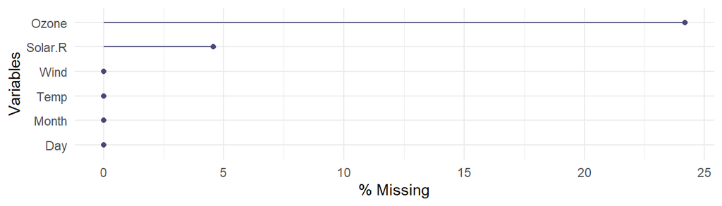

```r
# visualise missingness by variable
naniar::gg_miss_var(airquality, show_pct = T)
```

Visualise missingness by case

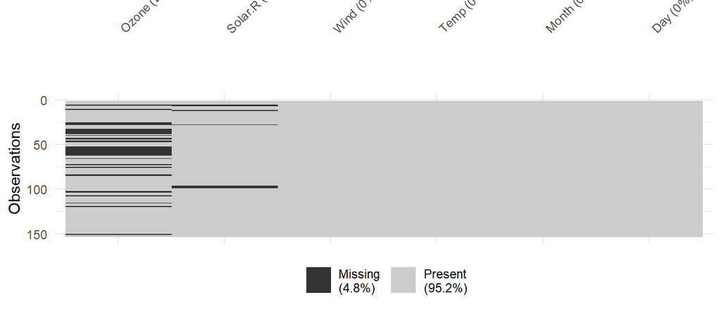

```r
naniar::vis_miss(airquality)
```

## 2.6 Interrogating data

Count distinct values

```r
# single vector
starwars %>% summarise(homeworld_distinct = n_distinct(homeworld))
```

| homeworld_distinct |
| --- |
| 49 |

```r
# where is.character
starwars %>% summarise(across(where(is.character), n_distinct))
```

| name | hair_color | skin_color | eye_color | sex | gender | homeworld | species |
| --- | --- | --- | --- | --- | --- | --- | --- |
| 87 | 12 | 31 | 15 | 5 | 3 | 49 | 38 |

Count duplicates

```r
# across all columns
iris %>% janitor::get_dupes()
```

| Sepal.Length | Sepal.Width | Petal.Length | Petal.Width | Species | dupe_count |
| --- | --- | --- | --- | --- | --- |
| 5.8 | 2.7 | 5.1 | 1.9 | virginica | 2 |
| 5.8 | 2.7 | 5.1 | 1.9 | virginica | 2 |

```r
# across specified columns
mtcars %>% janitor::get_dupes(mpg, hp)
```

| mpg | hp | dupe_count | cyl | disp | drat | wt | qsec | vs | am | gear | carb |
| --- | --- | --- | --- | --- | --- | --- | --- | --- | --- | --- | --- |
| 21 | 110 | 2 | 6 | 160 | 3.9 | 2.620 | 16.46 | 0 | 1 | 4 | 4 |
| 21 | 110 | 2 | 6 | 160 | 3.9 | 2.875 | 17.02 | 0 | 1 | 4 | 4 |

```r
# with base R
sum(duplicated(mtcars$disp))
```

```
[1] 5
```

Retain only distinct rows (delete duplicates). This is much faster than `group_by` and `slice_tail`.

```r
mtcars %>% distinct(mpg, hp, .keep_all = T)

# another option is to use first()
df %>%
  group_by(var1, var2, var3) %>%
  summarise(across(everything(), ~ first(.x))) # also available: last() and nth(n = 3)
```

Sometimes you get duplicate rows when you perform joins because the rows aren’t actually distinct. This can be because some cells have missing data and others don’t, so R sees them as different. In this case, you can use the code below to retain only the rows that have the least missing data.

```r
df %>%
  arrange(rowSums(is.na(.))) %>%
  distinct(unique_ref, .keep_all = T)
```

## 2.7 Other validation

`validate` package

```r
# example from James Tierney
extract_rules <- validate::validator(
    # Each row must be unique in representing the teaching hours allocated to one subject
    # in one year group for one teacher at one school
    is_unique(census_year, staff_matching_reference, la_estab, subject_description_sfr, year_group), #1

    # Checks for availability of records on key fields
    is_complete(census_year), #2
    is_complete(census_year, staff_matching_reference), #3
    is_complete(census_year, staff_matching_reference, la_estab), #4
    is_complete(census_year, staff_matching_reference, la_estab, subject_description_sfr), #5
    is_complete(census_year, staff_matching_reference, la_estab, subject_description_sfr, year_group), #6
    is_complete(census_year, staff_matching_reference, la_estab, subject_description_sfr, year_group, hours), #7

    # Hours taught must be positive and no more than 40 hours per week
    hours >= 0 & hours <= 40 #8
    )

swc_extract_validation_results <- summary(validate::confront(df, extract_rules))

extract_missing_values <- df %>%
  summarise(across(.cols = everything(), ~sum(is.na(.x))))
```

`skimr` package

```r
skimr::skim(starwars)
```

Data summary

| Name | starwars |
| --- | --- |
| Number of rows | 87 |
| Number of columns | 14 |
| _______________________ |  |
| Column type frequency: |  |
| character | 8 |
| list | 3 |
| numeric | 3 |
| ________________________ |  |
| Group variables | None |

**Variable type: character**

| skim_variable | n_missing | complete_rate | min | max | empty | n_unique | whitespace |
| --- | --- | --- | --- | --- | --- | --- | --- |
| name | 0 | 1.00 | 3 | 21 | 0 | 87 | 0 |
| hair_color | 5 | 0.94 | 4 | 13 | 0 | 11 | 0 |
| skin_color | 0 | 1.00 | 3 | 19 | 0 | 31 | 0 |
| eye_color | 0 | 1.00 | 3 | 13 | 0 | 15 | 0 |
| sex | 4 | 0.95 | 4 | 14 | 0 | 4 | 0 |
| gender | 4 | 0.95 | 8 | 9 | 0 | 2 | 0 |
| homeworld | 10 | 0.89 | 4 | 14 | 0 | 48 | 0 |
| species | 4 | 0.95 | 3 | 14 | 0 | 37 | 0 |

**Variable type: list**

| skim_variable | n_missing | complete_rate | n_unique | min_length | max_length |
| --- | --- | --- | --- | --- | --- |
| films | 0 | 1 | 24 | 1 | 7 |
| vehicles | 0 | 1 | 11 | 0 | 2 |
| starships | 0 | 1 | 16 | 0 | 5 |

**Variable type: numeric**

| skim_variable | n_missing | complete_rate | mean | sd | p0 | p25 | p50 | p75 | p100 | hist |
| --- | --- | --- | --- | --- | --- | --- | --- | --- | --- | --- |
| height | 6 | 0.93 | 174.60 | 34.77 | 66 | 167.0 | 180 | 191.0 | 264 | ▂▁▇▅▁ |
| mass | 28 | 0.68 | 97.31 | 169.46 | 15 | 55.6 | 79 | 84.5 | 1358 | ▇▁▁▁▁ |
| birth_year | 44 | 0.49 | 87.57 | 154.69 | 8 | 35.0 | 52 | 72.0 | 896 | ▇▁▁▁▁ |

## 2.8 Write data

```r
write.csv(df, "fileName", row.names = F)

readr::write_csv(df, "fileName", delim = ",", na = "")

readr::write_delim(df, "fileName", delim = "|", na = "")

# write an .xlsx file where each hub gets its own worksheet
write_xlsx(split(df, ~ hub), "output.xlsx")

# fst:
write.fst(df, "fileName.fst")

# to a database:
DBI::dbWriteTable(conn = con,
             value = df,
             name = "table_name",
             overwrite = T)
```

# 3 Wrangling

## 3.1 NA values

### 3.1.1 Converting NA to another value

`dplyr::replace_na()`

```r
# these all reproduce the original dataframe but with amended cell values
airquality %>% mutate(Ozone = replace_na(Ozone, 0))

# examples using across()
airquality %>% mutate(across(everything(), ~ replace_na(., 0)))

iris %>% mutate(across(ends_with(".Length"), ~ replace_na(., 0)))

iris %>% mutate(across(starts_with(c("Sepal", "Petal")), ~ replace_na(., 0)))

# using across
df %>% across(c("var1", "var2", "var3"), ~if_else(is.na(.x), "Missing", .x))
```

`tidyr::fill` This is useful if you have a value that is only inserted once due to grouping, but you need to repeat this value for all the remaining rows.

```r
airquality %>% dplyr::select(Ozone) %>% head()
```

| Ozone |
| --- |
| 41 |
| 36 |
| 12 |
| 18 |
| NA |
| 28 |

```r
airquality %>%
  tidyr::fill(Ozone, .direction = "down") %>%
  dplyr::select(Ozone) %>% head()
```

| Ozone |
| --- |
| 41 |
| 36 |
| 12 |
| 18 |
| 18 |
| 28 |

```r
# note how 18 has been repeated on line 5 (repeated from above)
```

You can also add a `.group` argument to `fill`. And note that it will throw an error if you try to fill a character vector within `mutate` but will work outside of this. I.e. instead of `df %>% mutate(var = fill()...)`, do this: `df %>% fill(...)`.

### 3.1.2 Converting values to NA

`dplyr::na_if` - note that this only takes 1 value.

```r
# e.g. convert "unknown" to NA
starwars %>% mutate(eye_color = na_if(eye_color, "unknown"))

starwars %>% mutate(across(where(is.character), ~ na_if(., "unknown")))
```

If you want to convert multiple character values to NA:

```r
df %>%
  mutate(
    across(
      where(is.character),
      ~if_else(. %in% c("NA", "N/A", "na", "n/a", " "), NA_character_, .)
    )
  )
```

### 3.1.3 Dropping NA values

Use `dplyr::drop_na` to drop all NA values

```r
# Drop all
airquality %>% drop_na()

# Drop NA in specific columns
airquality %>% drop_na(Ozone, Solar.R)

# use across columns
df %>% drop_na(c(starts_with("c_")))

# Note: for large datasets, consider data.table:
# dt = as.data.table(df)
# dt[complete.cases(dt)]
```

To remove rows that contain all NA (i.e. retain rows with some non-NA content):

```r
airquality[rowSums(is.na(airquality)) != ncol(airquality), ]
```

## 3.2 Convert rownames to column names

```r
df = df %>%
  rownames_to_column(var = "predictor")
```

## 3.3 Wide to long format

This is a very common data wrangling task. The recipe below converts `starwars` to long-format to easily compute summary statistics. Firstly use `pivot_longer()`:

```r
# original wide format (each character has a single row)
starwars %>% dplyr::select(-c(films)) %>% head()
```

| name | height | mass | hair_color | skin_color | eye_color | birth_year | sex | gender | homeworld | species | vehicles | starships |
| --- | --- | --- | --- | --- | --- | --- | --- | --- | --- | --- | --- | --- |
| Luke Skywalker | 172 | 77 | blond | fair | blue | 19.0 | male | masculine | Tatooine | Human | Snowspeeder , Imperial Speeder Bike | X-wing , Imperial shuttle |
| C-3PO | 167 | 75 | NA | gold | yellow | 112.0 | none | masculine | Tatooine | Droid |  |  |
| R2-D2 | 96 | 32 | NA | white, blue | red | 33.0 | none | masculine | Naboo | Droid |  |  |
| Darth Vader | 202 | 136 | none | white | yellow | 41.9 | male | masculine | Tatooine | Human |  | TIE Advanced x1 |
| Leia Organa | 150 | 49 | brown | light | brown | 19.0 | female | feminine | Alderaan | Human | Imperial Speeder Bike |  |
| Owen Lars | 178 | 120 | brown, grey | light | blue | 52.0 | male | masculine | Tatooine | Human |  |  |

```r
# conver to long format (each character has 3 rows)
starwars_long = starwars %>%
  dplyr::select(-c(films, vehicles, starships)) %>%
  pivot_longer(cols = c(height, mass, birth_year),
               names_to = "measure",
               values_to = "value")
# note that pivot_longer won't combine columns of different types - if this happens, use values_transform with a specified function
head(starwars_long)
```

| name | hair_color | skin_color | eye_color | sex | gender | homeworld | species | measure | value |
| --- | --- | --- | --- | --- | --- | --- | --- | --- | --- |
| Luke Skywalker | blond | fair | blue | male | masculine | Tatooine | Human | height | 172 |
| Luke Skywalker | blond | fair | blue | male | masculine | Tatooine | Human | mass | 77 |
| Luke Skywalker | blond | fair | blue | male | masculine | Tatooine | Human | birth_year | 19 |
| C-3PO | NA | gold | yellow | none | masculine | Tatooine | Droid | height | 167 |
| C-3PO | NA | gold | yellow | none | masculine | Tatooine | Droid | mass | 75 |
| C-3PO | NA | gold | yellow | none | masculine | Tatooine | Droid | birth_year | 112 |

Secondly, group by `measure` and compute summary statistics.

```r
starwars_long %>%
  group_by(measure) %>%
  summarise(min = min(value, na.rm=T),
            mean = mean(value, na.rm=T),
            max = max(value, na.rm=T))
```

| measure | min | mean | max |
| --- | --- | --- | --- |
| birth_year | 8 | 87.56512 | 896 |
| height | 66 | 174.60494 | 264 |
| mass | 15 | 97.31186 | 1358 |

## 3.4 Long to wide format

This example accomplishes the opposite - converting long data to wide format. The recipe below converts `us_rent_income` from long to wide format such that each row represents a single NAME with separate columns for ‘income’ and ‘rent’.

```r
# original long format
us_rent_income = tidyr::us_rent_income %>%
  dplyr::select(-c(moe))
us_rent_income %>% head()
```

| GEOID | NAME | variable | estimate |
| --- | --- | --- | --- |
| 01 | Alabama | income | 24476 |
| 01 | Alabama | rent | 747 |
| 02 | Alaska | income | 32940 |
| 02 | Alaska | rent | 1200 |
| 04 | Arizona | income | 27517 |
| 04 | Arizona | rent | 972 |

```r
us_rent_income %>%
  pivot_wider(names_from = variable,
              values_from = estimate) %>%
  head()
```

| GEOID | NAME | income | rent |
| --- | --- | --- | --- |
| 01 | Alabama | 24476 | 747 |
| 02 | Alaska | 32940 | 1200 |
| 04 | Arizona | 27517 | 972 |
| 05 | Arkansas | 23789 | 709 |
| 06 | California | 29454 | 1358 |
| 08 | Colorado | 32401 | 1125 |

Note that the `id_cols` argument can be used if your pivot results in NAs for one level of a factor. In the above, this would be `GEOID`.

Also note that if the output results in lists instead of numeric vectors, you need to add this:

```r
... %>%
  unnest(cols = c(...))
```

### 3.4.1 Melt and cast with `data.table`

```r
# a more complicated procedure - select columns starting with Q and a number from 1 to 31 and columns ending in 'Sco', and pivot longer by putting these values into columns called QID and Score:
melted_df = data.table::melt(df,
                             measure = patterns("^Q([1-9]|[12][0-9]|3[01])ID$", "Sco$"),
                             value.name = c("QID", "Score"))

cast_df = data.table::dcast(melted_df,
                            PupilId + FormID + group ~ QID,
                            value.var="Score", drop=T)
```

## 3.5 Separate and unnest

```r
c_list = data.frame(
  a = c("item1,item2,item3"),
  b = c("item1,item2,item3"))

c_list
```

| a | b |
| --- | --- |
| item1,item2,item3 | item1,item2,item3 |

```r
# separate items into new rows
c_list %>% tidyr::separate_longer_delim(a, delim=",")
```

| a | b |
| --- | --- |
| item1 | item1,item2,item3 |
| item2 | item1,item2,item3 |
| item3 | item1,item2,item3 |

```r
# separate items into new cols
c_list %>% tidyr::separate_wider_delim(a, delim=",", names = c("col1", "col2", "col3"))
```

| col1 | col2 | col3 | b |
| --- | --- | --- | --- |
| item1 | item2 | item3 | item1,item2,item3 |

Another recipe - say you want to split this `measure` column into two columns, by the underscore delimiter and then pivot wider to see the values side by side for every measure.

```r
df = data.frame(
  measure = c("TP_thresh", "TN_thresh", "FP_thresh", "FN_thresh", "TP_cut", "TN_cut", "FP_cut", "FN_cut"),
  value = c(41, 203, 36, 6, 42, 181, 58, 5))

df
```

| measure | value |
| --- | --- |
| TP_thresh | 41 |
| TN_thresh | 203 |
| FP_thresh | 36 |
| FN_thresh | 6 |
| TP_cut | 42 |
| TN_cut | 181 |
| FP_cut | 58 |
| FN_cut | 5 |

```r
df %>%
  separate_wider_delim(measure, delim = "_", names = c("metric", "type")) %>%
  pivot_wider(names_from = type, values_from = value)
```

| metric | thresh | cut |
| --- | --- | --- |
| TP | 41 | 42 |
| TN | 203 | 181 |
| FP | 36 | 58 |
| FN | 6 | 5 |

A `tidyr::unnest` recipe: given a list of items for each row (e.g. `c("The Empire Strikes Back", "Revenge of the Sith" [...]`), extract each one into a new row.

```r
starwars %>%
  unnest_longer(films) %>%
  dplyr::select(name, films) %>% head()
```

| name | films |
| --- | --- |
| Luke Skywalker | A New Hope |
| Luke Skywalker | The Empire Strikes Back |
| Luke Skywalker | Return of the Jedi |
| Luke Skywalker | Revenge of the Sith |
| Luke Skywalker | The Force Awakens |
| C-3PO | A New Hope |

This isn’t really a ‘separate’ problem, but you may have a character vector that you’d like to split into several columns, where each column is a binary value.

```r
df = data.frame(
  id = rep(1:3, each=3),
  location = c("London", "London", "London", "East", "East", "East", "West", "West", "West"))
df
```

| id | location |
| --- | --- |
| 1 | London |
| 1 | London |
| 1 | London |
| 2 | East |
| 2 | East |
| 2 | East |
| 3 | West |
| 3 | West |
| 3 | West |

```r
# use model.matrix to create dummy columns
locations = df$location
helper_df = data.frame(loc = factor(locations))

# Use model.matrix to one-hot encode
dummy_cols = model.matrix(~ loc - 1, data = helper_df)

cbind(df, dummy_cols)
```

| id | location | locEast | locLondon | locWest |
| --- | --- | --- | --- | --- |
| 1 | London | 0 | 1 | 0 |
| 1 | London | 0 | 1 | 0 |
| 1 | London | 0 | 1 | 0 |
| 2 | East | 1 | 0 | 0 |
| 2 | East | 1 | 0 | 0 |
| 2 | East | 1 | 0 | 0 |
| 3 | West | 0 | 0 | 1 |
| 3 | West | 0 | 0 | 1 |
| 3 | West | 0 | 0 | 1 |

## 3.6 Unite

Recipe: combine the values in two columns

```r
df = data.frame(
  group = c("AA", "BB", "CC"),
  size = c("big", "small", "medium"),
  value = c(20, 25, 40))

df
```

| group | size | value |
| --- | --- | --- |
| AA | big | 20 |
| BB | small | 25 |
| CC | medium | 40 |

```r
df %>% unite(col = "united", group, size, sep = "_")
```

| united | value |
| --- | --- |
| AA_big | 20 |
| BB_small | 25 |
| CC_medium | 40 |

```r
df %>% unite("united", group, size, value, sep="-")
```

| united |
| --- |
| AA-big-20 |
| BB-small-25 |
| CC-medium-40 |

## 3.7 Coalesce

`coalesce` searches for the first non-missing value across columns specified.

```r
df %>% mutate(flag = coalesce(TestMark1A, TestMark2A, TestMark3A))
```

## 3.8 Filter and other rowwise functions

Note that filtering is faster on ungrouped data.

```r
mtcars %>% filter(gear >= 4 & hp > 109)
```

To select odd or even rows

```r
# even rows
df %>% filter(row_number() %% 2 == 0)

# odd rows
df %>% filter(row_number() %% 2 == 1)
```

### 3.8.1 Slice

Use `slice` functions to subset rows.

Recipe: take a random sample of rows in a df:

```r
# subset a number of rows
slice_sample(df, n = 50, replace = F)

# subset a proportion of rows
slice_sample(df, prop = 0.5, replace = F)

# note that sample_n has been superseded by slice_sample
```

Recipe: you have a grouped long-format dataframe and you want to return the maximum of some value for each level of the grouping factor. Note the essential use of `with_ties` in `slice_max`.

```r
nycflights13::flights %>%
  top_n(n = 5)

nycflights13::flights %>%
  group_by(carrier) %>%
  slice_max(n = 1, order_by = arr_delay, with_ties = F) %>%
  left_join(nycflights13::airlines, by = "carrier") %>%
  select(name, arr_delay) %>%
  arrange(desc(arr_delay))
```

Recipe: look for duplicate entries according to certain variables and use `slice_tail` to select the last observation in each grouping. This works by assigning a row number to each row according to its arrangement/grouping, then simply retaining the last row in the group.

```r
rownames(mtcars) = NULL

mtcars %>%
  dplyr::select(mpg, cyl, disp, hp) %>%
  group_by(mpg, cyl, disp, hp) %>%
  mutate(id = row_number()) %>% head()
```

| mpg | cyl | disp | hp | id |
| --- | --- | --- | --- | --- |
| 21.0 | 6 | 160 | 110 | 1 |
| 21.0 | 6 | 160 | 110 | 2 |
| 22.8 | 4 | 108 | 93 | 1 |
| 21.4 | 6 | 258 | 110 | 1 |
| 18.7 | 8 | 360 | 175 | 1 |
| 18.1 | 6 | 225 | 105 | 1 |

Above we see that if a row is a unique combination of mpg, cyl, disp, and hp then its id is 1. Otherwise, its id is 2. `slice_tail` will assign grouped row numbers like this and retain only the last row number in a group and thus get rid of duplicate rows.

```r
mtcars %>%
  select(mpg, cyl, disp, hp) %>%
  group_by(mpg, cyl, disp, hp) %>%
  slice_tail(n = 1)
```

Alternatively, use `slice(1)` in the above to select the **first** row.

### 3.8.2 Duplicate/replicate rows

[output not shown]

`slice` can also be used to display or print a certain number of rows from a tibble (this has superseded dplyr’s `top_n`). If you are using this in combination with `tabyl`, you may need to add an `order_by` argument (see below).

```r
mtcars %>% slice_max(mpg, n=5)
mtcars %>% slice_min(qsec, n=5)

df %>%
  tabyl(x, y) %>%
  slice_max(n = 5, order_by = n)
```

### 3.8.3 `pmax` and `pmin`

In this recipe, we find the minimum or maximum value for each row across a specified range of columns. Here is the data:

```r
head(df)
```

| A | B | C |
| --- | --- | --- |
| 66 | 49 | 27 |
| 37 | 3 | 79 |
| 45 | 25 | 59 |
| 60 | 65 | 77 |
| 17 | 6 | 96 |
| 32 | 20 | 39 |

So we want to find the maximum value for each row across each of the three columns.

```r
df = df %>%
 mutate(min_val = pmin(A, B, C, na.rm=T),
        max_val = pmax(A, B, C, na.rm=T))

head(df)
```

| A | B | C | min_val | max_val |
| --- | --- | --- | --- | --- |
| 66 | 49 | 27 | 27 | 66 |
| 37 | 3 | 79 | 3 | 79 |
| 45 | 25 | 59 | 25 | 59 |
| 60 | 65 | 77 | 60 | 77 |
| 17 | 6 | 96 | 6 | 96 |
| 32 | 20 | 39 | 20 | 39 |

Here we see that the min value for row 1 is 27 (col C) and the max is 66 (col A).

## 3.9 Deriving new variables

### 3.9.1 `if_any` and `if_all`

```r
# if_any and if_all return a logical result, e.g. assessing whether some condition is present across
# any or all of a specific set of columns. The examples below work for both functions.

# Recipe: return TRUE if value is "blue" in any columns containing "color"
starwars %>% mutate(blue = if_any(
  contains("color"), ~ . == "blue"))

# Recipe: flag when any columns starting with "TotalMarkA" contain "L"
df %>% mutate(contains_L = if_any(starts_with("TotalMarkA"), ~ . == "L"))

# Recipe: state whether a value in either column appears in a list of values:
hierarchy = c("A", "B", "C", "D")
df %>% mutate(in_hierarchy = if_any(c(TestMark1, TestMark2), ~ . %in% hierarchy))
```

You can also use `if_any` and `if_all` with `filter`:

```r
# filter rows where any of Sepal.Width or Petal.Width is bigger than 4.
iris %>%
  filter(if_any(c(Sepal.Width, Petal.Width), ~ . > 4))

# Filter out rows that contain "Legacy grade"
df %>%
  filter(if_all(c(gcse_grade_eng_lit_15,
                  gcse_grade_maths_15), ~ . != "Legacy grade"))

# Filter rows where columns are numeric and cell values are above 5
df %>%
  filter(if_any(where(is.numeric), ~ . > 5))

# Filter rows where each specified column is not NA, using all_of()
years <- as.character(2013:2024) # corresponds to col names
df %>%
  filter(if_all(all_of(years), ~ !is.na(.)))

df %>%
  filter(if_all(starts_with("x"), ~ !is.na(.)))

# Remove any rows with all NA values
df %>%
  filter(!if_all(everything(), is.na))
```

### 3.9.2 `case_when`, `case_match`

Recipe: create a new variable to indicate “large” vs “small” starwars characters according to mass and height.

```r
starwars %>%
  mutate(size_group = case_when(
    mass > 100 | height > 200 ~ "large",
    T ~ "small"
  )) %>%
  dplyr::select(name, mass, height, size_group) %>% head()
```

| name | mass | height | size_group |
| --- | --- | --- | --- |
| Luke Skywalker | 77 | 172 | small |
| C-3PO | 75 | 167 | small |
| R2-D2 | 32 | 96 | small |
| Darth Vader | 136 | 202 | large |
| Leia Organa | 49 | 150 | small |
| Owen Lars | 120 | 178 | large |

Note that `case_when` needs to operate on the same class of vectors, e.g. character-only, numeric-only, etc. It’s not possible to combine values of e.g. `~ 50` (numeric) and `~ "large"` (character).

`T` effectively reads as “else”, i.e. to specify what happens if everything evaluates to FALSE or NA. In this case, rows will receive `NA`. To supply a specific NA value instead, you can use one of the following (making sure to align with the data type in the other labels) e.g.:

- `T ~ NA_character_`
- `T ~ NA_integer_`
- `T ~ NA_real_`
- `T ~ NA_date_`

If a condition (e.g. `mass > 100 | height > 200`) evaluates to `TRUE`, the other conditions will NOT be checked.

Another example using `if_any` (this says: mark an error if any of TestMark1A to 3A are “0”):

```r
df %>%
  mutate(missing_pages_check = case_when(
      if_any(c(TestMark1A, TestMark2A, TestMark3A), ~. == "0") ~ "Error",
      T ~ "OK"))
```

Note that if you want to supply a formula on the right hand side of case_when, then you need to add `rowwise` in the pipe (but don’t forget to ungroup afterwards):

```r
df %>%
  rowwise() %>%
  mutate(new_var = case_when(
    nchar(var1) == 14 ~ str_sub(var1, 5, 8),
    T ~ NA_character_
  )) %>%
  ungroup()
```

Remember to turn off `rowwise` if you want to do any aggregation/counting/grouping, by using `ungroup()`.

`case_match` is used for more simple recoding, and requires a vector of character values on the left-hand side.

```r
df %>%
  mutate(group = case_match(
    group, "ctl" ~ "Control",
    "exp" ~ "Experimental"))
```

Here is a recipe combining `if_any`, `case_when`, and `str_detect`. Let’s say you want to look across two columns and check if they contain a particular string. If so, assign a given value.

```r
df %>%
  mutate(category = case_when(
    if_any(c(var1, var2), ~ str_detect(., "English")) ~ "English",
    if_any(c(var1, var2), ~ str_detect(., "French")) ~ "French",
    TRUE ~ "Other"
  )
)
```

### 3.9.3 Cross-column operations

There are many examples of the `across` function in this guide. The examples below use `across()`, `dplyr::c_across` or `purrr:pmap`.

```r
# Recipe: sum values above 0 across columns containing "Recall"
df %>% mutate(var1 = pmap_int(select(., contains("Recall")),
                              ~sum(c(...) > 0, na.rm=T)))

# Recipe: count instances of value "k" across columns containing "InputMethods"
df %>% mutate(mode_k = pmap_int(select(., contains("InputMethods")),
                                ~sum(c(...) %in% "k")))

# change certain variables to factors
df %>% mutate(across(starts_with("c_", "y_"), ~as.factor(.x))) # also as.numeric, as.character

# round all numeric columns to 0 decimal places. You must now use an anonymous function to do this:
# where before across(a:b, mean),
# now use across(a:b, \(x) mean(x))
iris %>%  mutate(across(where(is.numeric), \(x) round(x, 0)))

# create a flag across cols 2 to 7 - 1 if cells are non-NA and 0 if they are NA
df %>% mutate(any_grade = if_else(rowSums(!is.na(across(2:7))) > 0, 1, 0))

# by default, summarise and across will leave the column names unchanged, but you
# can add a .names argument to change this:
df %>%
  summarise(
    across(
      c(
        maths_score,
        read_score,
        KS1MATPS,
      ),
      ~ mean(.x, na.rm = TRUE),
      .names = "{.col}_mean"
    )
  )
# this will produce maths_score_mean, read_score_mean, etc.

# or if you have a list of functions to apply, it will rename them dynamically
df %>%
  summarise(
  across(
    c(maths_score,
      read_score),
    list(
      mean = ~ mean(.x, na.rm = TRUE),
      sd   = ~ sd(.x, na.rm = TRUE)
    ),
    .names = "{.col}_{.fn}"
  )
)
# giving maths_score_mean, maths_score_sd, etc.
```

Some examples of `dplyr::c_across`

```r
# use c_across to calculate figures across multiple columns. It's designed to be used with rowwise().
df %>%
  rowwise() %>%
  mutate(sum = sum(c_across(w:z)),
         sd = sd(c_across(w:z))) %>%
  ungroup()

# NOTE! if you're using named columns, you need to wrap these in c():
df %>%
  rowwise() %>%
  mutate(mfl_count = sum(c_across(c(french, spanish, german)))) %>%
  ungroup()

# create a flag to indicate whether values in a set of columns are identical
df %>%
  rowwise() %>%
  mutate(equal = all(c_across(starts_with("PupilM")) == first(c_across(starts_with("PupilM"))))) %>%
  ungroup()

# tip: if you want to select column names using regex, e.g. select c1, c2, c3...
df %>% mutate(c_sum = sum(c_across(matches("^c\\d+$")), na.rm = TRUE))
```

Some other examples

```r
# use the .names function to change output column names
iris %>%
  group_by(Species) %>%
  summarise(across(starts_with("Petal"), max, .names = "{col}_max"))
```

| Species | Petal.Length_max | Petal.Width_max |
| --- | --- | --- |
| setosa | 1.9 | 0.6 |
| versicolor | 5.1 | 1.8 |
| virginica | 6.9 | 2.5 |

```r
# as above but add in a calculation to get the mean difference
iris %>%
  group_by(Species) %>%
  summarise(across(ends_with("Length"), ~ mean(get(cur_column()) - get(gsub("Length", "Width", cur_column()))),
                   .names = "{col}_meandiff"))
```

| Species | Sepal.Length_meandiff | Petal.Length_meandiff |
| --- | --- | --- |
| setosa | 1.578 | 1.216 |
| versicolor | 3.166 | 2.934 |
| virginica | 3.614 | 3.526 |

### 3.9.4 Creating quantiles

```r
df %>%
  mutate(var_quant = dplyr::ntile(var, 4))
```

## 3.10 Changing variables

### 3.10.1 Rename columns

```r
iris %>% rename(sepal_length = "Sepal.Length")

# you can also rename by index
iris %>% rename("newname" = 1)
```

If you want to rename all columns of a dataframe with the name of the object, e.g. “leo_”:

```r
names(leo_learners) = paste0("leo_", names(leo_learners) )
```

`rename_with` - replace all “.x” and “.y” created by joining (these become _sc and _agg)

```r
df %>%
  left_join(df2, by = "CurrDfENo") %>%
  rename_with(stringr::str_replace,
              pattern = ".x",
              replacement = "_sc") %>%
  rename_with(stringr::str_replace,
              pattern = ".y",
              replacement = "_agg")
```

### 3.10.2 Relocate

```r
iris %>% relocate(Species, .before = Sepal.Length)
iris %>% relocate(Petal.Width, .after = last_col())

# if you don't specify .before or .after, the column will be moved to the front by default
iris %>% relocate(Species)

# alternatively, you can just list column names to derive a new order
iris %>% relocate(Species, Petal.Width, Sepal.Length)
# any remaining column names that you don't specify will remain in the data in their original
# positions relative to each other

# you can also rename while you relocate
iris %>% relocate(plant = Species,
                  petal_w = Petal.Width,
                  sepal_w = Sepal.Width)
```

### 3.10.3 Recoding

Use `dplyr::recode_values` to change old values (first) into new values (second):

```r
df %>%
  mutate(sen_status = recode_values(
    sen_status,
    "N" ~ "NoSEN",
    "K" ~ "SENSupport",
    "E" ~ "EHCP",
    "S" ~ "Statement"))

# if numeric:
df %>%
  mutate(sen_status = recode_values(
    sen_status,
    1 ~ "NoSEN",
    2 ~ "SENSupport",
    3 ~ "EHCP",
    4 ~ "Statement"))
```

Note that for some reason if you are recoding numeric to character, you need to place integers in quotes:

```r
df %>%
  mutate(fsm_eligibility = recode(fsm_eligibility,
                                  "0" = "NoFSM",
                                  "1" = "FSM"))
```

If you are doing a lot of recoding repeatedly, you can save the mappings in a separate object and use the triple bang operator (`!!!`):

```r
group_recode = c(
  "ctrl" = "Control",
  "exp" = "Experimental"
)

df %>%
  mutate(group = recode(group, !!!group_recode))
```

For reference, this is the way to recode in Base R:

```r
df$var[df$var == "Old Value"] <- "New Value"
```

Recipe: recode `gender` values to numeric and assign `NA_real_` if cannot be recoded (NA type must match the type of the other values).

```r
starwars %>%
  dplyr::select(name:mass, gender) %>%
  mutate(gender2 = recode(
    gender,
    "masculine" = 1,
    "feminine" = 2,
    .default = NA_real_
  )) %>% slice(78:83)
```

| name | height | mass | gender | gender2 |
| --- | --- | --- | --- | --- |
| Grievous | 216 | 159 | masculine | 1 |
| Tarfful | 234 | 136 | masculine | 1 |
| Raymus Antilles | 188 | 79 | masculine | 1 |
| Sly Moore | 178 | 48 | NA | NA |
| Tion Medon | 206 | 80 | masculine | 1 |
| Finn | NA | NA | masculine | 1 |

```r
# another example
df %>% mutate(
  maladmin_check = recode(
    maladmin_check,
    "0" = "code1",
    "1" = "code2",
    "2" = "error1",
    "3" = "error2"
  ))
```

### 3.10.4 Refactoring / relevelling

Use `fct_relevel` to reorder the level of factors. This can be useful for tabulation or graphing.

```r
# relevel a single variable
df %>%
  mutate(var1 = fct_relevel(var1,
                            c("f1", "f3", "f4", "f2")))

# relevel across several columns
df %>%
  mutate(across(c(var1, var2),
                ~ fct_relevel(., c("High attainers",
                                   "Standard & strong passes",
                                   "Low attainers"))))
```

## 3.11 Joining

There are two types of joins:

- Inner joins: retaining only rows that appear in BOTH tables (`inner_join`)
- Outer joins: retaining only rows from ONE of the two tables (`left_join`, `right_join`, `full_join`)

A left join will retain all rows in the first table (`df` below). Note that when your join contains duplicate column names, these will become “var1.x” and “var1.y” by default. To override this and avoid having to rename separately later, you can specify the suffixes you would like using the `suffix` argument.

```r
# when the primary key is the same
df1 %>% left_join(df2, by = "primaryKey", suffix = c("_t1", "_t2"))

# when primary keys are different
df1 %>% left_join(df2, by = c("primaryKey1" = "Primarykey2"))

# to only retain certain columns from the second dataframe:
df1 %>% left_join(select(df2, col1, col2), by = "primaryKey")
```

### 3.11.1 Joining tips and extras

`suffix` - If you are joining tables with identical table names, these will be renamed `.x` for table1 and `.y` for table2. You can control the renaming:

```r
df1 %>% left_join(df2, by = "primaryKey",
                  suffix = c(".t1", ".t2"))
```

`multiple` - If you are joining wide and long-format data, there will be multiple matches in the latter. You can control what happens in this situation (but the default value of `all` is usually sufficient).

```r
df1 %>% left_join(df2, by = "primaryKey",
                  multiple = "all")
# all - returns every match detected
# first - returns first match in table2
# last - returns last match in table2
```

`unmatched` - By default, unmatched rows in outer joins will be dropped, but this can be controlled.

```r
df1 %>% left_join(df2, by = "primaryKey",
                  unmatched = "drop")

# drop - delete unmatched rows (default)
# error - throw an error
```

`relationship` - Explicitly tell R what kind of relationship to expect:

- “one-to-one”
- “one-to-many”
- “many-to-one”
- “many-to-many” (doesn’t provide any checks but prevents warnings)

A recipe for renaming columns in a big join: say you’re joining two dataframes from different time points that have the same name columns. You want to keep both sets, but append something to the first set of names to keep it unique for later joins.

```r
# first create a vector of column names to rename
cols_to_rename = c("URN", "CensusTerm", "NCYearActual",  "EthnicGroupMajor", "FSMeligible")

# append _y1 to distinguish from _y2 data joined later using rename_with
# (can also provide a suffix argument just in case names are duplicated)
df_joined = df1 %>%
  left_join(df2, by = "PMA",
            suffix = c("_cenY1", "_phonY1")) %>%
  rename_with(~paste0(., "_y1"), .cols = all_of(cols_to_rename))
```

Here, `rename_with` says: for all column names in `cols_to_rename`, paste the original name plus `_y1` at the end.

## 3.12 Splitting a list of dataframes

```r
# easiest way using a list:
list2env(df_list, envir = .GlobalEnv)

# also see old example:
# split a dataframe according to a variable
form_list = split(MTC2022_kmt, MTC2022_kmt$FormID)

# turn each list element into a dataframe
form_list = lapply(seq_along(form_list), function(x) as.data.table(form_list[[x]]))

# extract each element into the global environment
lapply(seq_along(form_list), function(x) {
  assign(c("Form1_clean", "Form2_clean", "Form3_clean", "Form4_clean", "Form5_clean")[x],
         form_list[[x]], envir=.GlobalEnv)})

# compute summary stats for each list element
lapply(form_list, function(x)
  x %>% rowwise() %>% mutate(formmark = sum(c_across(where(is.numeric)))) %>%
    group_by(inputtype) %>%
    summarise(n = n(),
              form_min = min(formmark),
              form_mean = mean(formmark),
              form_max = max(formmark)))
```

# 4 Selecting

Use `dplyr::select()` to select columns by name, index, or type. Note that although `across()` is used to select columns, it is only used when applying some function to these columns, not merely to create a subset of a dataframe with them.

```r
# select columns using names
starwars %>% select(name, height, mass, eye_color)

# select columns using indices
starwars %>% select(1:3, 6)

# select columns to REMOVE
starwars %>% select(-c(name, height, mass, eye_color))

# by type
starwars %>% select(where(is.numeric))

starwars %>% select(where(is.character))

# to select column names that match a list, try this:
col_list = c("name", "height", "mass")

starwars_subset = subset(starwars, select = names(starwars) %in% col_list)
head(starwars_subset)
```

# 5 Other cleaning functions

The `janitor` package is an excellent resource for data cleaning.

```r
# compare column names and types across dataframes
janitor::compare_df_cols(d1, d2, d3, return = c("all", "mismatch", "match"))

# clean variable names
# can use different cases:
# - snake (default): variable_name
# - title: `Variable Name` (will introduce spaces)
# - upper_camel: VariableName
# - lower_camel: variableName
# - all_caps: VARIABLE_NAME
janitor::clean_names(df, case = "snake")

# remove rows or cols with all empty values
janitor::remove_empty(df, which = c("cols", "rows"))

# rounding half up
df %>% mutate(var = janitor::round_half_up(var, digits = 1))
```

Removing whitespace can also prevent issues later down the line.

```r
# other functions
# trim whitespace

string = " contains whitespace "
stringr::str_trim(string, side = "both")
```

# 6 Working with strings

## 6.1 Detect strings

`str_detect`

```r
# Recipe: use filter to find strings containing "white" in the skin_color col
starwars %>%
  filter(str_detect(skin_color, "white")) %>%
  select(1:5)

# search for multiple patterns in a string
df %>% filter(str_detect(cheating_check, "reduced|approp|missing"))

# search for rows containing any of a list of characters
df %>% filter(str_detect(col1, "[Ábcdêãçoàúü¡“&#;]"))

# use for summing
sum(str_detect(cheating_tab$cheating_check, "reduced|populated") > 0)

# look for where Review contains A to Z and a number between 0 and 2.
df %>% mutate(review_check = case_when(
  str_detect(Review, "[a-zA-Z][0-2]") & (mark_change + outcome_change) > 0 ~ "Error"))
```

Find text between two other strings

```r
# extract hub name ("Arch")
string = "data - Arch.xlsx"
gsub(".*data - (.+).xlsx.*", "\\1", string)
```

```
[1] "Arch"
```

```r
# if you had a list of names and just wanted a simple character vector (without
# columns for named attributes), use unname
files = c("data - Arch.xlsx", "data - Burley Woodhead.xlsx",
          "data - Childer Thornton.xlsx")

names = unname(
  vapply(files, function(x)
    gsub(".*data - (.+).xlsx.*", "\\1", x),
    character(1)))

names
```

```
[1] "Arch"             "Burley Woodhead"  "Childer Thornton"
```

Find text between the beginning of a string and a certain character

```r
gsub("(.*?)(-.*)", "\\1", string)
```

```
[1] "data "
```

```r
# another example of finding text between two elements
string2 = "W:/folder1/folder2/File name.xlsx"

gsub(".*folder2\\/(.+?)\\.xlsx.*", "\\1", string2)
```

```
[1] "File name"
```

## 6.2 Replace strings

`str_replace_all` (this replaces all matches - `str_replace` only replaces the first match)

```r
# Recipe: replace "[1]" with a longer description, e.g. "1 audible"
df = df %>%
  mutate(var = str_replace_all(var,
  c("[1]" = "1 audible",
    "[2]" = "2 audio",
    "[3]" = "3 colour"))
  )
```

## 6.3 Tidy up strings

`str_to_lower`, `str_to_title`

```r
starwars %>% mutate(name = str_to_lower(name))

starwars %>% mutate(gender = str_to_title(gender))

 # to do this across multiple columns
starwars %>% mutate(across(c(name, homeworld, species), ~ tolower(.x)))
```

`str_length`

```r
string = "This is a string."
str_length(string)
```

```
[1] 17
```

`str_trim` removes whitespace from either or both sides

```r
string1 = "    This is a string with padding           "
str_trim(string1, side = c("both"))
```

```
[1] "This is a string with padding"
```

`str_squish` removes whitespace from both sides and replaces internal whitespace with a single space.

```r
string2 = " This is a string with padding and a full stop     ."
str_squish(string2)
```

```
[1] "This is a string with padding and a full stop ."
```

`str_trunc` truncates a string to the desired length. Note: by default, it will provide ellipsis.

```r
long_string = "The Sleepwalkers: How Europe Went to War in 1914"

# default with ellipsis (note that ellipsis starts AFTER character 19)
str_trunc(long_string, 19)
```

```
[1] "The Sleepwalkers..."
```

```r
# turn off ellipsis
str_trunc(long_string, 19, ellipsis = "")
```

```
[1] "The Sleepwalkers: H"
```

## 6.4 Subset strings

`str_sub`

```r
string = "I love R"
str_sub(string, 3, 6)
```

```
[1] "love"
```

```r
str_sub(string, 1, -2) # remove final character
```

```
[1] "I love "
```

```r
str_sub(string, 2, -1) # remove first character (-1 means end of string)
```

```
[1] " love R"
```

```r
# can be used as part of a case_when, e.g. check that the first element of TotalMarkA is
# NOT "E" or "%"
case_when(
  !str_sub(TotalMarkA, 1, 1) %in% c("E", "%")
)
```

Extract the first word in a string

```r
df %>% mutate(across(c(given_name_s, family_name), ~ str_extract(.x, "\\w+")))

df %>% mutate(Award_body = sapply(strsplit(QUIDTITLE, " "), function(x) x[1]))
# e.g. this takes "TCL Level 1 Award In..." and extracts "TCL".

string = "Today is Thursday"
stringr::word(string) # gives "Today"
stringr::word(string, 3) # gives "Thursday"
```

## 6.5 Regular expressions

Identify digits, letters, or a combination

```r
# Recipe: find names containing digits
starwars %>%
  filter(str_detect(name, "[:digit:]")) %>% select(1:5)
```

Also try:

- `"[:alnum:]"` - letters and numbers
- `"[:alpha:]"` - letters
- `"[:punct:]"` - any punctuation
- `"[:graph:]"` - letters, numbers, and punctuation
- `"[:space:]"` - space characters

```r
# look for strings containing A-Z, a-z, and a number between 2 and 7
str_detect(string, "[a-zA-Z][2-7]")

# look for strings starting with a letter followed by 12 consecutive digits
str_detect(string, "^[A-Za-z]\\d{12}$")

# look for strings starting with A-Z, a-z, 0-9, dashes, apostrophes, or parentheses and ending
# with an asterisk
str_detect(string, "^[A-Za-z0-9\\s\\-\\'\\(\\)]*$")

# find strings with 5 consecutive digits
str_detect(string, "\\d{5}")

# extract chunks of 5 numbers in strings
str_extract(string, "[0-9]{5}")

# find and extract the first whole word
str_extract("John Smith", "\\w+") # gives: "John"
```

Anchors

```r
# starts with a
str_detect(string, "^a")

# ends with a
str_detect(string, "a$")
```

Some base R recipes

```r
# remove a final full stop (. needs to be escaped with \\ as it's a special character)
cleaned_vector = gsub("\\.$", "", vector)

# Insert space (\\1) every 3 characters ({3}):
sub("\\s+$", "", gsub('(.{3})', '\\1 ', vector))

# retain only numbers
data = c("foo_5", "bar_7")
gsub(".*_", "", data)
readr::parse_number(data)

# retain any number at the end of a string, e.g. GR3 -> 3
df %>% mutate(Grade = str_extract(QUALTYPE, "\\d+$"))

# General syntax for grep()
grep(pattern_to_find, data, ignore.case = TRUE, value = T) # value=T: show results

# Filter cells that contain the letter F:
data %>% filter(grepl("F", variable))

# look for string consisting of letter-letter-number-number-letter-letter
grep("[A-Z][A-Z][0-9][0-9][A-Z][A-Z]", df$var, value=T)

# find a string beginning with a letter between A-Z, followed by a 2, followed by x
grep("[a-z]2[x]", data, value = T)

# Extract everything between parentheses
df$var = gsub("[\\(\\)]", "", regmatches(df$var, gregexpr("\\(.*?\\)", df$var)))
```

Some revived code

```r
# Quantifiers
quantifiers <- c("1","10","100", "1000","10000", "200")

# Is a 1 followed by 0 or more 0s?
quantifiers[str_detect(quantifiers, "10*")]
```

```
[1] "1"     "10"    "100"   "1000"  "10000"
```

```r
# is a 1 followed by 1 or more 0s?
quantifiers[str_detect(quantifiers, "10+")]
```

```
[1] "10"    "100"   "1000"  "10000"
```

```r
# find 'pupil' OR 'pupils'
optional_element <- c("pupil", "pupils", "students")
#find pupil or it's plurals
optional_element[str_detect(optional_element, "^pupils?$")]
```

```
[1] "pupil"  "pupils"
```

```r
# Quantifiers and wildcards
# Now with groupings and anchors
#1 with even 0s
quantifiers[str_detect(quantifiers, "^1(00)*$")]
```

```
[1] "1"     "100"   "10000"
```

```r
# This returns one hundred and one thousand (find 1 followed by 2 or 3 zeros)
quantifiers[str_detect(quantifiers, "^10{2,3}$")]
```

```
[1] "100"  "1000"
```

```r
# anything followed by 2 zeros
quantifiers[str_detect(quantifiers, "^.0{2}$")]
```

```
[1] "100" "200"
```

```r
# character classes
character_class <- c("hat school", "mat school", "sat school"
                     ,"cat school")

# first character must be h or s
character_class[str_detect(character_class, "[hs]at school")]
```

```
[1] "hat school" "sat school"
```

```r
# first character must NOT be h or s
character_class[str_detect(character_class, "[^hs]at school")]
```

```
[1] "mat school" "cat school"
```

```r
# conditionals
conditionals <- c("mixed", "boys", "girls")
# detect mixed or boys
conditionals[str_detect(conditionals, "^(mixed|boys)$")]
```

```
[1] "mixed" "boys"
```

```r
escapes <- c("school", "schools", "school's")
# find possessive schools
escapes[str_detect(escapes, "school\\'s")]
```

```
[1] "school's"
```

```r
# ERE Character classes
character_classes_ERE <- c("West School", "1 School",
                           "North School")
# find a school with a digit in it
character_classes_ERE[str_detect(character_classes_ERE, "[:digit:]")]
```

```
[1] "1 School"
```

# 7 Generating and sampling random data

## 7.1 Generate strings

```r
# create 25 strings of 6 characters each, using A-Z and 0-9 randomly
library(stringi)
code = stringi::stri_rand_strings(25, 6, pattern = "[A-Z0-9]")

# Add prefix 'OLLIH-' onto the random strings, e.g. OLLIH-273
codes = paste0("OLLIH-", stringi::stri_rand_strings(25, 3, pattern = "[0-9]"))
```

## 7.2 Generate numbers

```r
# replicate numbers 1 to 10, 10 times (1,2,3,4... 1,2,3,4..., 1,2,3,4...)
rep(c(1:4), times = 10)

# Replicate numbers a certain number of times each (1, 1, 2, 2, 3, 3, 4, 4, ...)
rep(c(1:4), times = 5, each = 2)

# set up random number generator to get replicable results
set.seed(1)

# Generate 5 random digits between 0 and 1
runif(5)

#  With a specified range
runif(5, min = 0, max = 100)

# Alternative method using sample()
sample(x = 1:100, size = 3, replace = F)

# Random normal distribution
rnorm(4, mean = 50, sd = 10)

# Truncated normal distribution
library(msm)
rtnorm(n, mean=0, sd=1, lower=-Inf, upper=Inf)
```

# 8 Dates and times

Convert character to date

```r
my_date = "08/10/2021"
as.Date(my_date, "%d/%m/%Y")
```

```
[1] "2021-10-08"
```

```r
# for dates in POSIXct format:
my_date = "Sep 29 2014 12:00AM"
as.POSIXct(my_date, format = "%b %d %Y %I:%M%p")
```

```
[1] "2014-09-29 BST"
```

```r
# note:
# %b — Abbreviated month name (e.g., "Sep")
# %d — Day of the month (e.g., "29")
# %Y — 4-digit year (e.g., "2014")
# %I — Hour (01–12) in 12-hour format
# %M — Minute (00–59)
# %p — AM/PM indicator
```

Often when you read in Excel data the dates get messed up. Usually these will get converted to character: one good solution is to convert them to numeric first, and then to a date:

```r
df %>%
  mutate(date_col = as.numeric(date_col)) %>%
  mutate(date_col = lubridate::as_date(date_col,
                                       origin = "1899-12-30",
                                       format = "%d-%m-%Y"))

# for Excel numeric dates:
excel_date = 41103
janitor::excel_numeric_to_date(excel_date, include_time = F)

# for mixed numeric and character dates
excel_mixed = c(41103, "2020/02/29")
janitor::convert_to_date(excel_mixed)
```

There are two ways to extract the year from a `date` object:

```r
my_date = as.Date("08/10/2021", "%d/%m/%Y")

year = format(as.Date(my_date, format="%d/%m/%Y"),"%Y")
year
```

```
[1] "2021"
```

The method above results in character type, e.g. “2021”. It may be better to use `lubridate` to extract the year as this is simpler and results in a double type which is more compatible with graphing methods:

```r
my_date = as.Date("08/10/2021", "%d/%m/%Y")
my_date
```

```
[1] "2021-10-08"
```

```r
my_year_dbl = lubridate::year(my_date)
my_year_dbl
```

```
[1] 2021
```

Calculate the difference between two date/time objects in years

```r
df %>%
  mutate(age = as.numeric(difftime(date2, date1, units = "weeks") / 52.25))

# a more accurate method is time_length as this takes into account the fact that months and years
# dont have the same number of days
df %>%
  mutate(age = lubridate::time_length(difftime(date2, date1), "years"))
```

Filtering dates

```r
filter(date > as.Date("2001-01-19") & date < as.Date("2003-03-21"))
```

# 9 Summarising

`get_summary_stats` from the `rstatix` package provides different `type`s of summary statistics:

- full
- common
- robust (same as median_iqr)
- mean_sd
- mean_ci
- median_iqr
- median_mad

```r
mtcars %>%
  group_by(cyl) %>%
  rstatix::get_summary_stats(c(mpg, wt),
                    type = "full")
```

| cyl | variable | n | min | max | median | q1 | q3 | iqr | mad | mean | sd | se | ci |
| --- | --- | --- | --- | --- | --- | --- | --- | --- | --- | --- | --- | --- | --- |
| 4 | mpg | 11 | 21.400 | 33.900 | 26.000 | 22.800 | 30.400 | 7.600 | 6.523 | 26.664 | 4.510 | 1.360 | 3.030 |
| 4 | wt | 11 | 1.513 | 3.190 | 2.200 | 1.885 | 2.622 | 0.737 | 0.541 | 2.286 | 0.570 | 0.172 | 0.383 |
| 6 | mpg | 7 | 17.800 | 21.400 | 19.700 | 18.650 | 21.000 | 2.350 | 1.927 | 19.743 | 1.454 | 0.549 | 1.344 |
| 6 | wt | 7 | 2.620 | 3.460 | 3.215 | 2.822 | 3.440 | 0.618 | 0.363 | 3.117 | 0.356 | 0.135 | 0.330 |
| 8 | mpg | 14 | 10.400 | 19.200 | 15.200 | 14.400 | 16.250 | 1.850 | 1.557 | 15.100 | 2.560 | 0.684 | 1.478 |
| 8 | wt | 14 | 3.170 | 5.424 | 3.755 | 3.533 | 4.014 | 0.481 | 0.408 | 3.999 | 0.759 | 0.203 | 0.438 |

## 9.1 Crosstabulation

`janitor::tabyl`

```r
# one-way tabyl

starwars %>%
  mutate(eye_color = na_if(eye_color, "unknown")) %>%
  tabyl(eye_color, show_na = T) %>%
  adorn_pct_formatting(digits=2) %>%
  arrange(desc(n)) %>%
  adorn_totals()
```

| eye_color | n | percent | valid_percent |
| --- | --- | --- | --- |
| brown | 21 | 24.14% | 25.00% |
| blue | 19 | 21.84% | 22.62% |
| yellow | 11 | 12.64% | 13.10% |
| black | 10 | 11.49% | 11.90% |
| orange | 8 | 9.20% | 9.52% |
| red | 5 | 5.75% | 5.95% |
| hazel | 3 | 3.45% | 3.57% |
| NA | 3 | 3.45% | - |
| blue-gray | 1 | 1.15% | 1.19% |
| dark | 1 | 1.15% | 1.19% |
| gold | 1 | 1.15% | 1.19% |
| green, yellow | 1 | 1.15% | 1.19% |
| pink | 1 | 1.15% | 1.19% |
| red, blue | 1 | 1.15% | 1.19% |
| white | 1 | 1.15% | 1.19% |
| Total | 87 | - | - |

Tip: for a two-way tabyl, remove double whitespaces by including a call to `str_replace_all`

```r
# two-way tabyl

ggplot2::diamonds %>%
  tabyl(cut, color, show_na = T) %>%
  adorn_totals(c("row", "col")) %>%
  adorn_percentages("row") %>%
  adorn_pct_formatting()  %>%
  adorn_ns(position = "front") %>% # use "rear" to switch position
  mutate(across(everything(), ~ str_replace_all(., "  ", " ")))
```

| cut | D | E | F | G | H | I | J | Total |
| --- | --- | --- | --- | --- | --- | --- | --- | --- |
| Fair | 163 (10.1%) | 224 (13.9%) | 312 (19.4%) | 314 (19.5%) | 303 (18.8%) | 175 (10.9%) | 119 (7.4%) | 1,610 (100.0%) |
| Good | 662 (13.5%) | 933 (19.0%) | 909 (18.5%) | 871 (17.8%) | 702 (14.3%) | 522 (10.6%) | 307 (6.3%) | 4,906 (100.0%) |
| Very Good | 1,513 (12.5%) | 2,400 (19.9%) | 2,164 (17.9%) | 2,299 (19.0%) | 1,824 (15.1%) | 1,204 (10.0%) | 678 (5.6%) | 12,082 (100.0%) |
| Premium | 1,603 (11.6%) | 2,337 (16.9%) | 2,331 (16.9%) | 2,924 (21.2%) | 2,360 (17.1%) | 1,428 (10.4%) | 808 (5.9%) | 13,791 (100.0%) |
| Ideal | 2,834 (13.2%) | 3,903 (18.1%) | 3,826 (17.8%) | 4,884 (22.7%) | 3,115 (14.5%) | 2,093 (9.7%) | 896 (4.2%) | 21,551 (100.0%) |
| Total | 6,775 (12.6%) | 9,797 (18.2%) | 9,542 (17.7%) | 11,292 (20.9%) | 8,304 (15.4%) | 5,422 (10.1%) | 2,808 (5.2%) | 53,940 (100.0%) |

# 10 Iteration/for loops

```r
data = data.frame(
  df1 = rnorm(10),
  df2 = rnorm(10),
  df3 = rnorm(10))

col_median = function(df){
  output = numeric(ncol(df))
  for (i in seq_along(df)){
    output[[i]] = median(df[[i]])
  }
  output
}
col_median(data)
```

```
[1]  0.2829048 -0.3806576 -0.2650298
```

Use a for loop to create a list of dataframes with random data

```r
set.seed(2020)

# create empty list
e <- list()

for (i in 1:3) {
  e[i] <- list(rnorm(n = 30, mean = 50, sd = 12))
  samples = data.frame(e)
}
```

# 11 Functions

## 11.1 The `apply` family

R’s in-built `apply` functions are designed to iterate over data structures such as lists, matrices, or dataframes. A common use case is to use them to work through each element in a list to apply summary statistics or to compute some kind of transformation.

| Function | Input | Output |
| --- | --- | --- |
| `apply` | matrix | array, vector |
| `lapply` | list | list |
| `sapply` | list, vector | vector |
| `vapply` | list, vector | vector |
| `mapply` | vector | list, vector |
| `Map` | list, vector | list |

### 11.1.1 `apply`

- `apply(X, MARGIN, FUN)`
- `MARGIN` can be 1 for rows or 2 for columns
- Returns an array

```r
my_matrix = matrix(1:12, nrow=3); my_matrix
```

```
     [,1] [,2] [,3] [,4]
[1,]    1    4    7   10
[2,]    2    5    8   11
[3,]    3    6    9   12
```

```r
apply(my_matrix, 1, max)
```

```
[1] 10 11 12
```

### 11.1.2 `lapply`

- `lapply(X, FUN)`
- Takes a list and outputs a list
- Tidyverse equivalent is `purrr:map(x, f)`

```r
my_vector = c(1, 2, 3)

lapply(my_vector, function(x) x + 1)
```

```
[[1]]
[1] 2

[[2]]
[1] 3

[[3]]
[1] 4
```

```r
# purr equivalent
# purrr::map(my_vector, ~ .x + 1)
```

```r
df_list = list(
  a = data.frame(a = 1:3, b = 4:6, c = 7:9),
  b = data.frame(d = 10:12, e = 13:15, f = 16:18),
  c = data.frame(g = 19:21, h = 22:24, i= 25:27)
)

lapply(df_list, function(x) names(x))
```

```
$a
[1] "a" "b" "c"

$b
[1] "d" "e" "f"

$c
[1] "g" "h" "i"
```

### 11.1.3 `sapply`

- ‘S’ stands for ‘simplified’ - same syntax as `lapply` but returns a vector
- `sapply(X, FUN, USE.NAMES = TRUE)`

```r
sapply(df_list, function(x) sum(x), simplify = T)
```

```
  a   b   c
 45 126 207
```

### 11.1.4 `vapply`

- `vapply` is the same as `sapply` but allows you to determine the type of return value:
- `vapply(df_list, function(x) sum(x), numeric(1))`

### 11.1.5 `tapply`

- `tapply(X, INDEX, FUN)`
- Used to compute summary statistics for different groups or factors
- `X` is the vector to be summarised; `INDEX` is the grouping factor

```r
salaries = c(80000, 62000, 113000, 68000, 75000, 79000, 112000, 118000, 65000, 117000)
role = c('scientist', 'analyst', 'engineer', 'analyst', 'scientist', 'scientist', 'engineer', 'engineer', 'analyst', 'engineer')

tapply(salaries, role, mean)
```

```
  analyst  engineer scientist
    65000    115000     78000
```

### 11.1.6 `mapply`

- A multivariate version of `sapply`, used in cases of multiple vectors.
- Applies a function in parallel (‘in lockstep’) across the elements of two or more vectors or lists, pairing the first elements, then the second, and so on, then simplifying the result.
- `mapply(FUN, ..., SIMPLIFY = TRUE)`
- Note that `Map()` is a wrapper for `mapply` but yields list output.
- Tidyverse equivalent: `purrr::map2()`

```r
# example: find the max in each of PAIR of values across two vectors
vector1 = c(1, 2, 3, 4, 5)
vector2 = c(2, 4, 1, 2, 10)

mapply(max, vector1, vector2, SIMPLIFY = T)
```

```
[1]  2  4  3  4 10
```

Example of using `purrr::map2()`

```r
purrr::map2(vector1, vector2, \(x, y) x + y)
```

### 11.1.7 Recipe for cross-reference checking with `mapply` and `map2()`

Say you have a dataframe of unique URNs for a list of Hubs (these are the ones the Hubs are supposed to be working with). You want to check a dataframe to see if the list of URNs for each Hub matches the ones they should be working with.

| hub | urn |
| --- | --- |
| A | 1001 |
| A | 1002 |
| A | 1003 |
| B | 1004 |
| B | 1005 |
| B | 1006 |

And here is the actual data you need to check against.

| hub | urn |
| --- | --- |
| A | 1001 |
| A | 1002 |
| A | 1004 |
| B | 1004 |
| B | 1005 |
| B | 1006 |

Now use `mapply` to check if the urns for each hub are what we’d expect given the `urn_list` above. We see that urn `1004` is NOT a permissible URN for hub A (so we get `FALSE`), but the same urn IS permissible for hub B (so we get `TRUE`). This code is saying:

- Iterate the datframe `actual` row by row over the vectors `hub` and `urn` simultaneously.
- Evaluate whether `urn` is in the `urn_list` WHERE the hub value is matched for the hub in question (returning a new vector of true or false values).

```r
actual %>%
  mutate(valid_urn = mapply(function(h, u) {
    u %in% urn_list$urn[urn_list$hub == h]
  }, hub, urn))
```

| hub | urn | valid_urn |
| --- | --- | --- |
| A | 1001 | TRUE |
| A | 1002 | TRUE |
| A | 1004 | FALSE |
| B | 1004 | TRUE |
| B | 1005 | TRUE |
| B | 1006 | TRUE |

```r
# rewrite above with map2
actual %>%
  mutate(valid_urn = map2_lgl(
    hub, urn,
    \(h, u) u %in% urn_list$urn[urn_list$hub==h]))
```

Example of using `Map`

```r
# read in a list of .xlsx files but only the sheets corresponding to a named list
# e.g. files = c("path1 - Arch.xlsx", "path2 - Burley.xlsx"), etc, where 'names'
# is just c("Arch", "Burley"), etc
# So the below pairs each file with its matching sheet name and reads that in

dfs = Map(function(file, sheet) {
  read_excel(file, sheet = sheet)
}, files, names)
# (produces a list, unlike mapply)

# make sure the list objects are named...
names(dfs) = names

# ... so that they can be used as the id as bind_rows
hubs_long = bind_rows(dfs, .id = "hub")
```

## 11.2 User-defined functions

Some examples of functions and nifty tricks for making things dynamic.

Basic structure of a function. Note that default values such as NA can be expressed to show that an argument is optional. The … notation indicates multiple arguments.

```r
my_func = function(arg1, arg2 = NA, ...){
  # some operation
}
```

### 11.2.1 Error handling using `stop`

```r
my_func = function(x, y) {

  if (!exists("folder_file_path"))
    stop("Error: Please specify folder file path for datafeed")
}

my_func = function(df, subject){
  # subject argument check
  acceptable_subjects = c("G", "M")

  if (!subject %in% acceptable_subjects)
    stop("Error: Please choose 'M' or 'G' as subject.")
}
```

### 11.2.2 Extract arguments using `substitute` and `deparse`

```r
my_func = function(datafile){
  df_name = deparse(substitute(datafile))

  # for example, you might then use df_name later:
  df %>% select(!!paste("KS2", df_name, "_CGS", sep=""))
}

# Example: extract a variable name to use as a ggtitle:

char_graph = function(df, outcome, char){

  # extract text contained in 'char'
  title = deparse(substitute(char))

  # create graph and invoke title object in ggtitle
  df %>%
    ggplot(aes(x = {{outcome}}, y = prop, fill = {{char}})) +
    ggtitle(title)
    ...
}}
```

Example of a function that compares missingness in a column across a list of dataframes. It uses a different method to above to capture the name of each dataframe in the list.

```r
compare = function(col, ...){

  # make a list of input dataframes
  dfs = list(...)

  # capture df names for outputting
  data_drop <- as.character(match.call())[-c(1, 2)]

  # count
  n = sapply(dfs, function(df){nrow(df)})
  miss = sapply(dfs, function(df){sum(is.na(df[[col]]))})

  data.frame(data_drop, col, n, miss) %>%
    mutate(pc = miss / n)
}

# combine
bind_rows(compare("upn", d1, d2, d3, d4),
          compare("dob", d1, d2, d3, d4),
          compare("school_name", d1, d2, d3, d4)
```

### 11.2.3 Exporting to the global environment

Using `<--`

```r
my_func = function(x, y){
  prod <<- x * y
}
```

Using `assign` for dynamic naming

```r
my_func = function(x, y){
  ...
  assign(paste0("dca_rows_", df_name, "_flagged"), # dynamic name
         dca_rows_flagged, # object to export
         envir = .GlobalEnv)
}
```

Remove something from the global environment

```r
if (nrow(df_flagged)==0){
    rm(df_flagged, pos = ".GlobalEnv")
  }
```

Example of an if statement based on logical argument in function all

```r
produce_desc_stats_t <- function(data, strata_input, exclude_nonpartner_schools){
     data %>%
     filter(case_when(exclude_nonpartner_schools == TRUE ~ partner_w12345 != "Non-partner school")) %>%
     {if exclude_nonpartner_schools == TRUE filter(partner_w12345 != "Non-partner school")} %>%
     select(...)
```

## 11.3 Tidy evaluation

Tidy evaluation is a way of achieving data masking, i.e. changing the context of computation. Whenever we use e.g. `starwars %>% filter(height > 200)`, we are using data masking (i.e. `height` instead of `starwars$height`). To change the context of computation, we need to suspend evaluation (‘quoting’) before resuming in a different environment. Tidy eval is only necessary when arguments vary, so is only really useful within functions.

We use a quote and unquote pattern called interpolation. For singular arguments we use `enquo` to quote and `!!` to unquote.

```r
grouped_mean = function(data, group_var, sum_var){
  group_var = enquo(group_var)
  sum_var = enquo(sum_var)

  data %>%
    group_by(!!group_var) %>%
    summarise(mean = mean(!!sum_var))
}

grouped_mean(mtcars, am, hp)
```

| am | mean |
| --- | --- |
| 0 | 160.2632 |
| 1 | 126.8462 |

For multiple arguments, use `enquos` and `!!!`. Here, multiple arguments are indicated by `...`.

```r
grouped_mean_multiple = function(.data, .sum_var, ...){
  .group_vars = enquos(...)
  .sum_var = enquo(.sum_var)

  .data %>%
    group_by(!!!.group_vars) %>%
    summarise(mean = mean(!!.sum_var))
}

grouped_mean_multiple(mtcars, hp, am, gear)
```

| am | gear | mean |
| --- | --- | --- |
| 0 | 3 | 176.1333 |
| 0 | 4 | 100.7500 |
| 1 | 4 | 83.8750 |
| 1 | 5 | 195.6000 |

Don’t forget `get()` and `{{}}`. Here is an example where you might want to produce many tables with different variables:

```r
char_table = function(df, outcome, char){
  df %>%
    filter(!is.na({{char}})) %>%
    tabyl({{outcome}}, {{char}}) %>%
    adorn_totals(c("row", "col")) %>%
    adorn_percentages("row") %>%
    adorn_pct_formatting()  %>%
    adorn_ns(position = "rear") %>%
    adorn_title()
}

char_table(my_dataframe, pass_rate, ethnicity)
```

Here, use `if_any` and `coalesce` to take the first non-missing value within a pre-specified list, and then derive a new variable based on a dynamic name (`{varname}`)

```r
my_func = function(df, subject){
  varname = paste0("TotalMarkA_", subject)

  tab <<- df %>%
      mutate(in_hierarchy = if_any(c(TestMark1, TestMark2), ~ . %in% hierarchy)) %>%
      mutate(value = ifelse(in_hierarchy == TRUE, coalesce(TestMark1, TestMark2), NA)) %>%
      mutate({{varname}} := case_when(
        value == TotalMarkA & Subject == subject ~ "OK",
        Subject != subject ~ "N/A: diff subj",
        TRUE ~ paste0("Error: ", varname, " incorrect")))
}
```

Another example of glue:

```r
ofsted_grading_function<-
  function(x, y){

    var = as.symbol(y)

    x %>% mutate({{ y }} := case_when(
      {{var}} == "1" ~ "Outstanding",
      {{var}} == "2" ~ "Good",
      {{var}} == "3" ~ "Requires Improvement",
      {{var}} == "4" ~ "Inadequate",
      {{var}} == "0" ~ NA_character_,

      {{var}} == "SWK" ~" Serious Weaknesses",
      {{var}} == "SM" ~" Special Measures",

      {{var}} == "8" ~ NA_character_,
      {{var}} == "9" ~ NA_character_,
      {{var}} == "NULL" ~ NA_character_,
      T ~ NA_character_))
  }

# then later:
ofsted_data_output <- purrr::map_df(.f = ofsted_input_function, .x = c(17:25)) %>%
  bind_rows(ofsted_data_16) %>%
  ofsted_grading_function("overall_effectiveness")
```

## 11.4 Nifty functions for various tasks

### 11.4.1 Compare NA

```r
# function for comparing NAs (i.e. because if two values are NA, you can't
# compare them for equivalence)
  compareNA <- function(v1,v2) {
    same <- (v1 == v2) | (is.na(v1) & is.na(v2))
    same[is.na(same)] <- FALSE
    return(same)
  }

# example: if TA and TestStatus are different, assign 3
!compareNA(TA, TestStatus)) ~ 3


# To convert factor to numeric. If you just use as.numeric, this will use the factor levels, not the
# "number" that you see in the vector.
df %>% mutate(my_fac = as.numeric(levels(my_fac)[my_fac]))
```

### 11.4.2 Assign ID number by group

If you have grouped long format data and want to assign a unique ID to each GROUP, use `cur_group_id`:

```r
df %>%
  group_by(group) %>%
  mutate(id = cur_group_id())
```

# 12 Text analysis

```r
# tidytext package
```

# 13 Presentation

## 13.1 `gt` package

This package provides some options for high-quality, highly customisable table outputs.

```r
# dummy data
df = gt::countrypops %>%
  dplyr::select(-c(starts_with("country_code"))) %>%
  filter(str_detect(country_name, "Republic")) %>%
  filter(year %in% c(2000, 2010, 2020)) %>%
  pivot_wider(names_from = year, values_from = population)

# simple table
df %>%
  gt(rowname_col = "country_name") %>%
  tab_spanner(label = "Total population", columns = everything()) %>%
  fmt_integer() %>%
  cols_align("left") %>%
  tab_row_group(label = "group 1", rows = 1:2) %>%
  tab_row_group(label = "group 2", rows = 3:4) %>%
  # if you want to display the row group as a column on the left, add
  # row_group.as_column=T to tab_options
  row_group_order(c("group 1", "group 2")) %>%
  tab_options(table.align='left',
              table.font.size = 14,
              table.font.names = "Arial") %>%
  tab_header(title = "Population table") %>%
  tab_options(table.align='left') %>%
  tab_style(
    style = list(cell_text(weight = "bold")),
    locations = cells_body(
      columns = c(`2020`),
      rows = c(2,3))) %>%
  opt_stylize(style = 3) %>%  # styles 1-6
  opt_vertical_padding(scale = 0.5) %>% # to control row padding (from 0-1)
  tab_footnote("Source: World Bank")
```

Population table

|  | Total population 2000 | Total population 2010 | Total population 2020 |
| --- | --- | --- | --- |
| group 1 |  |  |  |
| Central African Republic | 3,833,416 | 4,492,995 | 5,026,628 |
| Congo (Republic) | 3,151,345 | 4,462,290 | 5,752,791 |
| group 2 |  |  |  |
| Czech Republic | 10,255,063 | 10,474,410 | 10,697,858 |
| Dominican Republic | 8,584,190 | 9,820,175 | 11,008,300 |

Source: World Bank

```r
# I like to combine these for better readability:
# tab_options(table.font.size = 14) %>% opt_vertical_padding(scale = 0.5)

# note: to have a linebreak in the footnote, wrap the caption in html() and use <br>, e.g.
# tab_footnote(html("this is my long <br> caption that won't fit))
```

The 6 available styles are shown below. Note that the default colour is blue, but this can be either blue, cyan, pink, gree, red, or gray. AND note that it HAS to be the American spelling of `color`.

```r
df = nycflights13::planes %>%
  filter(type != "Rotorcraft") %>%
  tabyl(engine, type)

df %>% gt() %>%
  opt_stylize(style = 1, color = "blue", add_row_striping = T) %>%
  tab_header("Style 1")
```

Style 1

| engine | Fixed wing multi engine | Fixed wing single engine |
| --- | --- | --- |
| 4 Cycle | 0 | 2 |
| Reciprocating | 5 | 23 |
| Turbo-fan | 2750 | 0 |
| Turbo-jet | 535 | 0 |
| Turbo-prop | 2 | 0 |

```r
df %>% gt() %>%
  opt_stylize(style = 2, color = "blue", add_row_striping = T) %>%
  tab_header("Style 2")
```

Style 2

| engine | Fixed wing multi engine | Fixed wing single engine |
| --- | --- | --- |
| 4 Cycle | 0 | 2 |
| Reciprocating | 5 | 23 |
| Turbo-fan | 2750 | 0 |
| Turbo-jet | 535 | 0 |
| Turbo-prop | 2 | 0 |

```r
df %>% gt() %>%
  opt_stylize(style = 3, color = "blue", add_row_striping = T) %>%
  tab_header("Style 3")
```

Style 3

| engine | Fixed wing multi engine | Fixed wing single engine |
| --- | --- | --- |
| 4 Cycle | 0 | 2 |
| Reciprocating | 5 | 23 |
| Turbo-fan | 2750 | 0 |
| Turbo-jet | 535 | 0 |
| Turbo-prop | 2 | 0 |

```r
df %>% gt() %>%
  opt_stylize(style = 4, color = "blue", add_row_striping = T) %>%
  tab_header("Style 4")
```

Style 4

| engine | Fixed wing multi engine | Fixed wing single engine |
| --- | --- | --- |
| 4 Cycle | 0 | 2 |
| Reciprocating | 5 | 23 |
| Turbo-fan | 2750 | 0 |
| Turbo-jet | 535 | 0 |
| Turbo-prop | 2 | 0 |

```r
df %>% gt() %>%
  opt_stylize(style = 5, color = "blue", add_row_striping = T) %>%
  tab_header("Style 5")
```

Style 5

| engine | Fixed wing multi engine | Fixed wing single engine |
| --- | --- | --- |
| 4 Cycle | 0 | 2 |
| Reciprocating | 5 | 23 |
| Turbo-fan | 2750 | 0 |
| Turbo-jet | 535 | 0 |
| Turbo-prop | 2 | 0 |

```r
df %>% gt() %>%
  opt_stylize(style = 6, color = "blue", add_row_striping = T) %>%
  tab_header("Style 6")
```

Style 6

| engine | Fixed wing multi engine | Fixed wing single engine |
| --- | --- | --- |
| 4 Cycle | 0 | 2 |
| Reciprocating | 5 | 23 |
| Turbo-fan | 2750 | 0 |
| Turbo-jet | 535 | 0 |
| Turbo-prop | 2 | 0 |

If row stripes don’t display in the HTML output, add this to the YAML:

```r
# format:
#  html:
#   html-table-processing: none
```

### 13.1.1 Other `gt` functions

```r
# to wrap column or header names when they're too long - use md() and <br/>
gt() %>%
  tab_header(title = md("Proportion of 16-18 learners <br/> by highest study aim, 2020/21"))

# custom column names
gt() %>% cols_label(old_name = "New name")

# do the same with cols_label:
gt() %>% cols_label(var1 = md("Long variable name <br/> that needs splitting"))

# make header row bold face (note: color MUST be American spelling to work):
gt() %>%
  tab_style(
    style = cell_text(weight = "bold", color = "black"),
    locations = cells_column_labels(everything())
  )

# format number for specific columns with separator mark and decimals
gt() %>% fmt_number(
  columns = c('n.16', "n.17", "n"),
  sep_mark = ',', decimals = 0)

# replace NA values
gt() %>%
  sub_missing(columns = everything(),
              rows = everything(),
              missing_text = "")

# format percent on certain cols and rows
gt() %>%
  fmt_percent(columns = c(2,3),
             rows = c(2:6),
             decimals = 2)

# add conditional formatting
gt() %>%
  data_color(columns = 2:4,
             direction = "column",
             palette = colorRampPalette(c("lightblue", "darkblue"))(100))

# to fill cells with colour
gt() %>%
tab_style(
    style = cell_fill(color = "lightblue"),
    locations = cells_body(
      columns = col_name,
      rows = col_name2 <= 2019))

# save a gt table object (assuming it's called 'tab')
gtsave(tab, "tab.rtf") # for word format
gtsave(tab, "tab.png")
```

### 13.1.2 Conditional formatting

```r
df %>%
  gt() %>%
  # example 1 - use a readymade palette from RColorBrewer
  # note that you can also specify columns = everything() or columns = is.numeric,
  data_color(
    columns = c(var_a),
    rows = everything(), # or try 1:16 for row indices
    direction = "row",
    fn = scales::col_numeric(
      palette = "PuOr",   # or: c("blue", "red")
      domain = c(0, 15)), # leave NULL if you want to use the full range of data
    apply_to = "fill"
    ) %>%
  # example 2 - use a custom palette
  data_color(
    columns = c(var_b),
    fn = scales::col_numeric(
      palette = c('white', 'orange', 'red'),
      domain = c(0, 15)),
    ) %>%
  # example 3 - define colour based on if condition
  data_color(
    columns = var_c,
    rows = var_c < 300,
    method = "numeric",
    palette = c("red")
  ) %>%
  # example 4 - colour based on text value
  data_color(
    columns = var_d,
    fn = scales::col_factor(
      palette = c("green", "red"),
      domain = c("false", "true")
    )
  )
```

| var_a | var_b | var_c | var_d |
| --- | --- | --- | --- |
| 12 | 5 | 293 | true |
| 11 | 6 | 254 | false |
| 10 | 12 | 323 | true |
| 10 | 13 | 220 | true |
| 12 | 13 | 199 | true |
| 13 | 8 | 357 | false |
| 11 | 11 | 316 | false |
| 10 | 13 | 352 | true |
| 8 | 5 | 289 | false |
| 8 | 5 | 320 | false |

```r
# notes: can change apply_to to 'text' or 'fill (default)';
# if a cell is NA for formatting, it will be grey. na_color seems to have no effect,
# so use this instead:
# tab_style_body(
#     fn = function(x) is.na(x),
#     style = cell_fill(color = "white")
#   )
```

To use different rules for different rows:

```r
df2 = data.frame(
  Check = c("Total unique Hubs",
            "Hubs in Hubs list",
            "Hubs NOT in Hubs list",
            "Invalid URNs",
            "Duplicate URNs"),
  Count = c(34, 34, 0, 0, 0)
)

# highlight in green the cells for the first two rows IF their 'Count' value is 34.
df2 %>%
  gt() %>%
  tab_style(
    style = cell_fill(color = "lightgreen"),
    locations = cells_body(
      columns = Count,
      rows = Count == 34 &
             Check %in% c("Total unique Hubs", "Hubs in Hubs list")
    )
  )
```

### 13.1.3 Creating a large gt table with `rbind`

Sometimes you need a large table with lots of different categories. It isn’t always feasible to create this with a single long-format table, so this solution involves using rbind to collate smaller tables and then format the result nicely.

```r
# for first 2 columns (pass/fail)
pass_fail = rbind(
  df %>%
    tabyl(c_summer_born, psc_pass, show_na = F) %>%
    adorn_percentages("col") %>%
    adorn_pct_formatting() %>%
    adorn_ns(position = "rear") %>%
    rename(var = c_summer_born),

  df %>%
    tabyl(SEX, psc_pass, show_na = F) %>%
    adorn_percentages("col") %>%
    adorn_pct_formatting() %>%
    adorn_ns(position = "rear") %>%
    rename(var = SEX)
)
# for next couple of columns (to be joined onto the top table)
psc_dist = rbind(
  df %>%
    filter(psc_pass == "Fail") %>%
    group_by(c_summer_born) %>%
    summarise(mean = mean(PHONICSMARK, na.rm=T),
              within5 = sum(PHONICSMARK >= 27, na.rm=T) / n(),
              within3 = sum(PHONICSMARK >= 29, na.rm=T) / n(),
              within1 = sum(PHONICSMARK == 31, na.rm=T) / n()) %>%
    rename(var = c_summer_born),

  df %>%
    filter(psc_pass == "Fail") %>%
    group_by(SEX) %>%
    summarise(mean = mean(PHONICSMARK, na.rm=T),
              within5 = sum(PHONICSMARK >= 27, na.rm=T) / n(),
              within3 = sum(PHONICSMARK >= 29, na.rm=T) / n(),
              within1 = sum(PHONICSMARK == 31, na.rm=T) / n()) %>%
    rename(var = SEX)
)

pass_fail %>% left_join(psc_dist, by = "var") %>%
  gt(rowname_col = "var") %>%
  tab_options(table.font.size = 15,
              table.font.names = "Arial") %>%
  opt_stylize(style = 3) %>%
  tab_row_group(label = "Summer born", rows = 1:2) %>%
  tab_row_group(label = "Gender", rows = 3:4) %>%
  row_group_order(c("Summer born", "Gender")) %>%
  tab_spanner(label = "All pupils", columns = c(2:3)) %>%
  tab_spanner(label = "Of those failing", columns = c(4:7)) %>%
  fmt_number(4, decimals = 2) %>%
  fmt_percent(columns = c(5:7), decimals = 2) %>%
  cols_align("center") %>%
  tab_footnote("Note: 2023/24 data")
```

## 13.2 `gtsummary`

`gtsummary` builds on `gt` and is used to summarise dataframes, regession models, and more. Its main function is `tbl_summary`. **NOTE!!** `gtsummary` creates a conflict with `dplyr::select`.

```r
mpg %>%
  dplyr::select(displ, cty, hwy, drv, class) %>%
  gtsummary::tbl_summary(
    by = class,
    statistic = list(
      all_continuous() ~ "{mean} ({sd})",
      all_categorical() ~ "{n} / {N} ({p}%)"   # can just have {n} if preferred
    ),
    digits = all_continuous() ~ 2,
    missing = "no", # whether to include missing values in separate rows
    percent = "row", #or 'column'
  ) %>%
  modify_caption("<div style='text-align: left; font-weight: bold;'> Table 1</div>")
```

Table 1

| **Characteristic** | **2seater** N = 5<sup>1</sup> | **compact** N = 47<sup>1</sup> | **midsize** N = 41<sup>1</sup> | **minivan** N = 11<sup>1</sup> | **pickup** N = 33<sup>1</sup> | **subcompact** N = 35<sup>1</sup> | **suv** N = 62<sup>1</sup> |
| --- | --- | --- | --- | --- | --- | --- | --- |
| displ | 6.16 (0.53) | 2.33 (0.45) | 2.92 (0.72) | 3.39 (0.45) | 4.42 (0.83) | 2.66 (1.10) | 4.46 (1.07) |
| cty | 15.40 (0.55) | 20.13 (3.39) | 18.76 (1.95) | 15.82 (1.83) | 13.00 (2.05) | 20.37 (4.60) | 13.50 (2.42) |
| hwy | 24.80 (1.30) | 28.30 (3.78) | 27.29 (2.14) | 22.36 (2.06) | 16.88 (2.27) | 28.14 (5.38) | 18.13 (2.98) |
| drv |  |  |  |  |  |  |  |
| 4 | 0 / 103 (0%) | 12 / 103 (12%) | 3 / 103 (2.9%) | 0 / 103 (0%) | 33 / 103 (32%) | 4 / 103 (3.9%) | 51 / 103 (50%) |
| f | 0 / 106 (0%) | 35 / 106 (33%) | 38 / 106 (36%) | 11 / 106 (10%) | 0 / 106 (0%) | 22 / 106 (21%) | 0 / 106 (0%) |
| r | 5 / 25 (20%) | 0 / 25 (0%) | 0 / 25 (0%) | 0 / 25 (0%) | 0 / 25 (0%) | 9 / 25 (36%) | 11 / 25 (44%) |

<sup>1</sup> Mean (SD); n / N (%)

```r
# for quantiles, add {p25}, {p50} etc


# add p-values for comparisons
mpg %>%
  filter(class %in% c("compact", "pickup")) %>%
  dplyr::select(displ, cty, hwy, class) %>%
  gtsummary::tbl_summary(
    by = class,
    statistic = list(all_continuous() ~ "{mean} ({sd})"),
    digits = all_continuous() ~ 2
  ) %>%
  add_p()
```

[output not shown]

<sup>1</sup> Mean (SD)  
<sup>2</sup> Wilcoxon rank sum exact test

```r
# add CI
mpg %>%
  filter(class %in% c("compact", "pickup")) %>%
  dplyr::select(displ, cty, class) %>%
  gtsummary::tbl_summary(by = class,
              type = all_continuous() ~ "continuous2",
              statistic = list(
                all_continuous() ~ c(
                  "{mean} ({sd})",
                  "{min}-{max}")),
              digits = all_continuous() ~ 2) %>%
  add_p() %>%
  add_ci(pattern = "{stat} ({ci})")
```

| **Characteristic** | **compact** N = 47 (**95% CI**) | **pickup** N = 33 (**95% CI**) | **p-value**<sup>1</sup> |
| --- | --- | --- | --- |
| displ | (2.2, 2.5) | (4.1, 4.7) | <0.001 |
| Mean (SD) | 2.33 (0.45) | 4.42 (0.83) |  |
| Min-Max | 1.80-3.30 | 2.70-5.90 |  |
| cty | (19, 21) | (12, 14) | <0.001 |
| Mean (SD) | 20.13 (3.39) | 13.00 (2.05) |  |
| Min-Max | 15.00-33.00 | 9.00-17.00 |  |

<sup>1</sup> Wilcoxon rank sum exact test  
Abbreviation: CI = Confidence Interval

Saving a `gtsummary` object as html or docx (install `flextable` package)

```r
table %>%
  gtsummary::as_flex_table() %>%
  flextable::save_as_html(path = "./filename.html")
  # or  flextable::save_as_docx(path = "./filename.docx")
```

Note that if you want to have more than one grouping factor, you need to use `tbl_strata` or `tbl_strata2`:

```r
df %>%
  select(grouping1, grouping2,
         var1, var2) %>%
  tbl_strata(
    strata = grouping2,
    .tbl_fun =
      ~ .x %>%
      tbl_summary(by = grouping1,
      statistic = list(
      all_continuous() ~ "{mean} ({sd})",
      all_categorical() ~ "{n} / {N} ({p}%)"
    ))
  )
```

While `tbl_strata` only works for nesting, you can produce several independent tables and merge them, as long as they have the same structure

```r
# create and save tables one by one
t1 = non_miss %>%
  select(study_leave_rate_5ht, study_leave_days_5ht, att8, five94, level2em94,
         phase, ks4_pupils, ks2emss, starts_with("c_")) %>%
  gtsummary::tbl_summary(
    type = all_continuous() ~ "continuous2",
    statistic = list(
      all_continuous() ~ c(
        "{median} ({sd})",
        "{min}-{max}"),
      all_categorical() ~ "{n} ({p}%)"
    ),
    digits = all_continuous() ~ 2,
    missing = "no", # whether to include missing values in separate rows
    percent = "column", #or 'column'
  )

# as above but by FSM status
t2 = non_miss %>%
  select(study_leave_rate_5ht, study_leave_days_5ht, att8, five94, level2em94,
         phase, ks4_pupils, ks2emss, starts_with("c_")) %>%
  gtsummary::tbl_summary(
    by = c_fsm6,
    type = all_continuous() ~ "continuous2",
    statistic = list(
      all_continuous() ~ c(
        "{median} ({sd})",
        "{min}-{max}"),
      all_categorical() ~ "{n} ({p}%)"
    ),
    digits = all_continuous() ~ 2,
    missing = "no", # whether to include missing values in separate rows
    percent = "column", #or 'column'
  )

# as above but by selective status
t3 = non_miss %>%
  select(study_leave_rate_5ht, study_leave_days_5ht, att8, five94, level2em94,
         phase, ks4_pupils, ks2emss, starts_with("c_")) %>%
  gtsummary::tbl_summary(
    by = c_selective,
    type = all_continuous() ~ "continuous2",
    statistic = list(
      all_continuous() ~ c(
        "{median} ({sd})",
        "{min}-{max}"),
      all_categorical() ~ "{n} ({p}%)"
    ),
    digits = all_continuous() ~ 2,
    missing = "no", # whether to include missing values in separate rows
    percent = "column", #or 'column'
  )

# this will leave blank cells for where data isn't appropriate, e.g. FSM in the
# FSM breakdown table
tbl_merge(
  tbls = list(t1, t2, t3),
  tab_spanner = c("All", "FSM", "Selective")
)
```

## 13.3 Quarto documents

Below is a template for a Quarto YAML. Note: include `standalone` and `embed-resources` if you want to be able to share or view the HTML file on another device.

```r
---
title: "My Title"
date: now
date-format: "[Last updated:] DD/MM/YYYY HH:mm"
format:
  html:
    standalone: TRUE
    embed-resources: TRUE
    toc: true
    toc-depth: 3
    toc-expand: 1
    number-sections: FALSE
    toc-location: left
    df-print: kable
    code-fold: TRUE
    theme: default
    fontsize: 1em
    link-external-newwindow: TRUE
execute:
  warning: FALSE
  echo: TRUE
  eval: TRUE
---
```

Headings and subheadings are specified by prefixing hashtags - `#` for level 1, `##` for level 2, and so on. To cross-reference another section in your Quarto document, add a label for each section in curly brackets:

`# Packages {#sec-packages}`

To reference this use an at-symbol as a link: `See @sec-packages` - produces: See Section 1. (in an html Quarto output if you hover over this link it should display a preview of that section in the document)

### 13.3.1 URLs

```r
# See the following [page](www.insert-url-here.com).
```

### 13.3.2 Figure options

```r
# Add the following at the beginning of a code chunk:
# (note that figures are centre-aligned by default)
#| fig-align: "left"
#| fig-height: 4
#| fig-width: 4
```

To embed an external image file, add this to the Quarto file text (not in a code chunk):

`![HackneyMap](hackney_schools_map.png){height=600}`

Running Quarto or Markdown render does not save the objects in the workspace. You can use code to run an .Rmd or .qmd file which will save the objects. The code below needs to be copied and pasted into the console.

```r
# for markdown
rmarkdown::render(input = "MTC_4a_model_key_mouse.Rmd",
                  output_file = paste0("filename-", Sys.Date(), ".html"),
                  output_dir = "./Outputs")

# for quarto (note that there is no option to specify the output directory here)
quarto_render(input = "notebook.qmd",
              output_format = "html",
              output_file = paste0("filename-", Sys.Date(), ".html"))
```

# 14 Create Excel workbook

Use the `openxlsx` package to export various objects, dataframes, or outputs to an Excel file with multiple worksheets. Also have a look at [`openxlsx2](https://janmarvin.github.io/openxlsx2/).

```r
library(openxlsx)

# in this case, only export objects if they have been created in the environment
# (otherwise just remove the if statements)

qa_workbook = createWorkbook("QA_workbook")

if(exists("allowable_pupil_flagged")){
  addWorksheet(qa_workbook, "PupilValuesErr")
  writeDataTable(qa_workbook, sheet = "PupilValuesErr", allowable_pupil_flagged, startRow=1,
                 tableStyle = "none")
}

if(exists("upn_invalid_flagged")){
  addWorksheet(qa_workbook, "InvalidUPN")
  writeDataTable(qa_workbook, sheet = "InvalidUPN", upn_invalid_flagged, startRow=1,
                 tableStyle = "none")
}

saveWorkbook(qa_workbook, file = paste0("./Outputs/", "KS2DF_Queries_", date, "_", seq, "_R",  ".xlsx"),
             overwrite = TRUE)
```

Another more complicated example:

```r
xl_output = function(form = NULL,
                     model = NULL,
                     mod_fit = NULL,
                     item_fit_ref = NULL,
                     item_fit_focal = NULL,
                     item_infit_ref = NULL,
                     item_infit_foc = NULL,
                     resid_ref_df = NULL,
                     resid_focal_df = NULL,
                     ref_cases = NULL,
                     focal_cases = NULL,
                     DIFs = NULL,
                     DTF = NULL,
                     TCC = NULL,
                     sDTF = NULL){
  # define styles
  posStyle <- createStyle(fontColour = "#006100", bgFill = "#C6EFCE")
  negStyle <- createStyle(fontColour = "#9C0006", bgFill = "#FFC7CE")
  hs <- createStyle(fontColour = "#ffffff", fgFill = "#4F80BD", halign = "center",
                    valign = "center")
  colStyle <- createStyle(halign = "center")
  center_and_dp = createStyle(halign = "center", numFmt = "#.000")
  hs = createStyle(halign = "center")

  # create workbook
  workbook = createWorkbook(paste("MTC2022", form))

  # README ---
  addWorksheet(workbook, "readme")

  writeData(workbook, sheet = "readme", startCol = 1, startRow = 2, "This spreadsheet presents the results of IRT modelling to examine the potential bias introduced by different input methods in the 2022 MTC.")
  writeData(workbook, sheet = "readme", startCol = 1, startRow = 3, "It contrasts users who use different input methods in multiple group IRT models for the purpose of analysing differential item and test functioning.")

  writeData(workbook, sheet = "readme", startCol = 1, startRow = 5, paste("Analysis here is based on ", form, " with ", model@Data[["N"]], " respondents", sep=""))

  writeData(workbook, sheet = "readme", startCol = 1, startRow = 7, paste("File created:", Sys.time()))
  writeData(workbook, sheet = "readme", startCol = 1, startRow = 8, paste("By user:", Sys.getenv("USERNAME")))
    writeData(workbook, sheet = "readme", startCol = 1, startRow = 9, paste("Using", R.version[["version.string"]]))

  writeDataTable(workbook, sheet = "readme", session_package_info, startRow=17, withFilter = FALSE, tableName = "R_packages_used")


  # MODEL FIT ---
  addWorksheet(workbook, "model_fit")
  writeDataTable(workbook, sheet = "model_fit", mod_fit, startRow=2, withFilter = FALSE, headerStyle = hs,
                 tableName = "Model_fit")

  setColWidths(workbook, "model_fit", cols=2:26, widths = 12)

  # add notes
  writeData(workbook, sheet = "model_fit", paste("MTC2022", form, "model fit"), startCol = 1, startRow = 1)

  # more notes after table
  writeData(workbook, sheet = "model_fit", startCol = 1, startRow = 5, "Notes:")
  writeData(workbook, sheet = "model_fit", startCol = 1, startRow = 6, "M2 = Maydeu-Olivares & Joe (2006) limited information test procedure")
  writeData(workbook, sheet = "model_fit", startCol = 1, startRow = 7, "P-value of M2 should be >= 0.05 but large N makes it overly sensitive (de Ayala, 2022 p121)")

  # conditional formatting to highlight which indices show good fit
  conditionalFormatting(workbook, sheet="model_fit", cols=3, rows=3, rule=" < 0.05 ", type = "expression",style = negStyle)
  conditionalFormatting(workbook, sheet="model_fit", cols=4:6, rows=3, rule=" < 0.06 ", type = "expression",style = posStyle)

  # model info
  writeData(workbook, sheet = "model_fit", startCol = 1, startRow = 14, "MIRT model call:")
  writeData(workbook, sheet = "model_fit", startCol = 1, startRow = 15, deparse(model@Call))

  writeData(workbook, sheet = "model_fit", startCol = 1, startRow = 20, paste("N: ", model@Data[["N"]]))
  writeData(workbook, sheet = "model_fit", startCol = 1, startRow = 21, paste("Iterations: ", model@OptimInfo[["iter"]]))
  writeData(workbook, sheet = "model_fit", startCol = 1, startRow = 22, paste("Converged: ", model@OptimInfo[["converged"]]))

  addStyle(workbook, sheet = "model_fit", style = center_and_dp, rows = 3, cols = 3:10, gridExpand=T)

  # ...
  # apply conditional formatting for misfit col:
  conditionalFormatting(workbook, sheet="item_fit", cols=6, rows=33:57, type = "contains", rule = "misfit", style = negStyle)
  conditionalFormatting(workbook, sheet="item_fit", cols=13, rows=33:57, type = "contains", rule = "misfit", style = negStyle)

  # change to number formatting (to avoid scientific notation in Excel)
  addStyle(workbook, sheet = "item_fit", style = center_and_dp, rows = 3:27, cols = 5)
  addStyle(workbook, sheet = "item_fit", style = center_and_dp, rows = 3:27, cols = 12)

  #center
  addStyle(workbook, sheet = "item_fit", colStyle, rows = 3:28, cols = 2:4, gridExpand = TRUE)

  # ...
  # FOCAL (MOUSE)
  writeData(workbook, sheet = "residuals", startCol = 1, startRow = 32, paste("Q3 residuals for", foc, "group"))
  writeData(workbook, sheet = "residuals", startCol = 1, startRow = 33, paste("Cases to check:", focal_cases))
  writeDataTable(workbook, sheet = "residuals", resid_focal_df, startRow=34, startCol = 1, withFilter = FALSE,
                 headerStyle = hs, rowNames=T, tableName = "Q3_Residuals_mouse")
  #styling
  addStyle(workbook, sheet = "residuals", center_and_dp, rows = 6:30, cols = 2:26, gridExpand = TRUE)
  addStyle(workbook, sheet = "residuals", center_and_dp, rows = 35:60, cols = 2:26, gridExpand = TRUE)


  # conditional formatting to identify problematic cases
  posStyle <- createStyle(fontColour = "#006100", bgFill = "#C6EFCE")
  conditionalFormatting(workbook, sheet="residuals", cols=2:25, rows=6:30, rule=" > 0.2236", type = "expression",style = posStyle)
  conditionalFormatting(workbook, sheet="residuals", cols=2:25, rows=35:60, rule=" > 0.2236", type = "expression",style = posStyle)

  # set col widths
  setColWidths(workbook, "residuals", cols=2:26, widths = 5.00)
  # ...

  # DTF ---
  addWorksheet(workbook, "DTF")
  # call external function dtf_converter() to split DTF list into 3 dataframes (obs, ci, p)
  dtf_converter(DTF)

  writeData(workbook, sheet = "DTF", startCol = 1, startRow = 1, "Differential test functioning")
  writeData(workbook, sheet = "DTF", startCol = 1, startRow = 2, paste("sDTF = signed differential test functioning (positive value indicates bias in favour of reference group ", "(", ref, ")", sep=""))
  writeData(workbook, sheet = "DTF", startCol = 1, startRow = 3, "uDTF = unsigned differential test functioning (absolute value of bias regardless of direction)")

  # obs
  writeDataTable(workbook, sheet = "DTF", obs, startRow=5, startCol = 1, withFilter = FALSE,
                 headerStyle = hs, rowNames=T, tableName = "DTF_obs")

  # ci
  writeDataTable(workbook, sheet = "DTF", ci, startRow=8, startCol = 1, withFilter = FALSE,
                 headerStyle = hs, rowNames=T, tableName = "DTF_ci")

  # p
  writeDataTable(workbook, sheet = "DTF", p, startRow=12, startCol = 1, withFilter = FALSE,
                 headerStyle = hs, rowNames=T, tableName = "DTF_p")

  writeData(workbook, sheet = "DTF", startCol = 3, startRow = 13, "Tests whether sDTF is significantly non-zero")
  setColWidths(workbook, "DTF", cols=1:5, widths = 15)

  # avoid scientific notation for p-value
  addStyle(workbook, sheet = "DTF", style = center_and_dp, rows = 13, cols = 2, gridExpand=T)

  TCC[["main"]] = paste(form, " TCC", " (", sDTF_stat, ")", sep="")
  print(TCC)

  insertPlot(workbook, sheet = "DTF", width=6, height=4, startRow=16, startCol=1, dpi = 300)

  # sDTF plot
  print(sDTF)
  insertPlot(workbook, sheet = "DTF", width=6, height=4, startRow=16, startCol=6, dpi = 300)

  # save
  saveWorkbook(workbook, file = paste("MTC2022", "_", ref, "_", foc, "_", form, ".xlsx", sep=""), overwrite = TRUE)
}
```

# 15 Odds and ends

```r
gc() # garbage collection - A call of gc causes a garbage collection to take place.
# This will also take place automatically without user intervention, and the primary purpose
# of calling gc is for the report on memory usage. However, it can be useful to call gc after
# a large object has been processed or removed, as this may prompt R to return memory to the
# operating system. It may be more helpful to run this after running some sections of the code.

# use across and ifelse together
df %>% mutate(across(starts_with("y_"), ~ifelse(.x %in% c("EXS", "GDS"), 1, 0)))

df %>% summarise(across(starts_with(c("c_", "y_")), ~mean(.x, na.rm = T)))

# recipe to create new column which counts whether the number of distinct values in a column is above 5
df %>% mutate(five_distinct = ifelse(n_distinct(upn) >=5, 1, 0))

# dplyr count
mpg %>% count(manufacturer, name = "count", sort = T)

# starwars %>% count(gender, eye_color, .drop = F)
```

## 15.1 Lagged variables

```r
# create a lagged variable, e.g. from one year to the next
df %>%
  mutate(change = dplyr::lag(mfl_entries, n = 1, default = NA)) %>%
  mutate(change_pc = (mfl_entries - change) / change) %>%
  select(-c(Change))

# create a lagged variable across several columns
df %>% mutate(across(contains("_lag"), ~ dplyr::lag(.x, n = 1, default = NA)))
```

A reproducible example of deriving and graphing percentage change using `dplyr::lag`. The graph represents percentage change between each month across 3 variables. Use `geom_label` to get white boxes around the figures, otherwise use `geom_text`.

```r
df = airquality %>%
  group_by(Month) %>%
  summarise(ozone_m = mean(Ozone, na.rm=T),
            solar_m = mean(Solar.R, na.rm=T),
            wind_m = mean(Wind, na.rm=T)) %>%
  pivot_longer(-c(Month)) %>%
  arrange(name, Month) %>%
  group_by(name) %>%
  mutate(lag = dplyr::lag(value, n = 1, default = NA)) %>%
  mutate(diff = value - lag) %>%
  mutate(change_pc = diff / lag * 100)
df
```

| Month | name | value | lag | diff | change_pc |
| --- | --- | --- | --- | --- | --- |
| 5 | ozone_m | 23.615385 | NA | NA | NA |
| 6 | ozone_m | 29.444444 | 23.615385 | 5.8290598 | 24.683315 |
| 7 | ozone_m | 59.115385 | 29.444444 | 29.6709402 | 100.769231 |
| 8 | ozone_m | 59.961539 | 59.115385 | 0.8461538 | 1.431360 |
| 9 | ozone_m | 31.448276 | 59.961539 | -28.5132626 | -47.552587 |
| 5 | solar_m | 181.296296 | NA | NA | NA |
| 6 | solar_m | 190.166667 | 181.296296 | 8.8703704 | 4.892748 |
| 7 | solar_m | 216.483871 | 190.166667 | 26.3172043 | 13.839021 |
| 8 | solar_m | 171.857143 | 216.483871 | -44.6267281 | -20.614343 |
| 9 | solar_m | 167.433333 | 171.857143 | -4.4238095 | -2.574120 |
| 5 | wind_m | 11.622581 | NA | NA | NA |
| 6 | wind_m | 10.266667 | 11.622581 | -1.3559140 | -11.666204 |
| 7 | wind_m | 8.941935 | 10.266667 | -1.3247312 | -12.903226 |
| 8 | wind_m | 8.793548 | 8.941935 | -0.1483871 | -1.659452 |
| 9 | wind_m | 10.180000 | 8.793548 | 1.3864516 | 15.766691 |

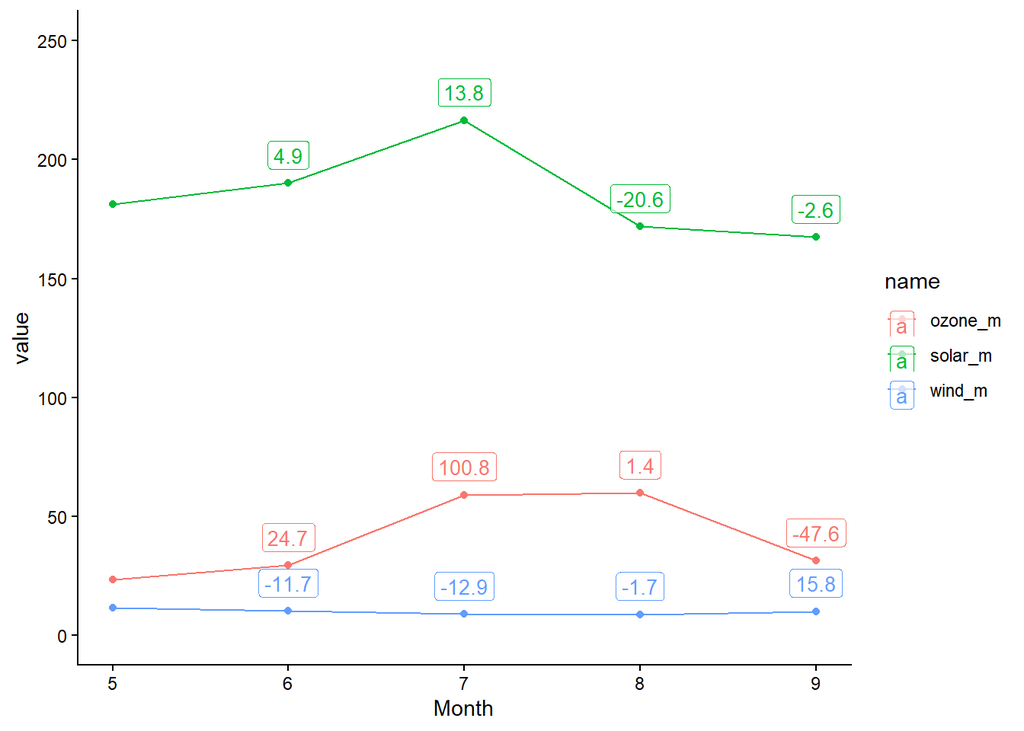

```r
df %>%
  ggplot(aes(x = Month, y = value, group = name, colour = name)) +
  geom_line() +
  geom_point() +
  geom_label(aes(label = round(change_pc,1)), size = 3.5, alpha = 0.7, vjust = -0.5) +
  theme_classic() +
  coord_cartesian(ylim = c(0,250))
```

## 15.2 Cumulative sum

```r
airquality %>%
  group_by(Month) %>%
  summarise(sum = sum(Solar.R, na.rm=T)) %>%
  mutate(cumsum = cumsum(sum))
```

| Month | sum | cumsum |
| --- | --- | --- |
| 5 | 4895 | 4895 |
| 6 | 5705 | 10600 |
| 7 | 6711 | 17311 |
| 8 | 4812 | 22123 |
| 9 | 5023 | 27146 |

## 15.3 Rounding and leading zeroes

```r
# Simple rounding
mtcars %>% summarise(mean_mpg = round(mean(mpg, na.rm=T)), 3)
```

| mean_mpg | 3 |
| --- | --- |
| 20 | 3 |

```r
# as character - helps for printing
mtcars %>% summarise(mean_mpg = sprintf("%.3f", mean(mpg, na.rm=T)))
```

| mean_mpg |
| --- |
| 20.091 |

A generic function to remove the leading zero from any numeric value.

```r
num_format = function(val) { sub("^(-?)0.", "\\1.", sprintf("%.3f", val)) }

# regex says: at the start of the string (^), look for a zero followed by a decimal point.
# also optionally capture cases of minus figures (-?).
# replace whatever was in the first capture group (\\1.) with a decimal point

num_format(0.0234)
```

```
[1] ".023"
```

The `rstatix` package provides functions for formatting p-values specifically with `p_format`:

```r
p = 0.00230

rstatix::p_format(p, leading.zero = F)
```

```
[1] ".0023"
```

```r
rstatix::p_format(p, leading.zero = F, digits = 1)
```

```
[1] ".002"
```

```r
rstatix::p_format(p, leading.zero = F, digits = 3, accuracy = 0.01)
```

```
[1] "<.01"
```

```r
rstatix::p_format(p, leading.zero = F, digits = 3, accuracy = 0.01, add.p = T, space = T)
```

```
[1] "p < .01"
```

## 15.4 Encoding

Note that ASCII encoding was designed to cope with 128 commonly used characters in English, not other languages. Unicode is a standardised system for representing all languages but it’s not a form of encoding. UTF-8 is one way to encode unicode characters.

R uses the `iconv` library to translate between encodings.

```r
utf8 <- "\u00fb"  # 'û'
utf8
```

```
[1] "û"
```

```r
iconv(utf8, to = "latin1")
```

```
[1] "û"
```

```r
# example of how to deal with HTML character entity encoding, e.g. when you have things like &#211;rla (Orla)

# use xml2 to fix this:
df %>%
  mutate(given_name_s = xml2::xml_text(read_html(paste0("<p>", given_name_s, "</p>"))))
```

## 15.5 Calculate the mode

There is no native function for this, so use the custom function below.

```r
mode <- function(x) {
  ux <- unique(x)
  ux[which.max(tabulate(match(x, ux)))]
}

mode(c(1,2,3,3,3,3,4,5,6,6,7,8,9))
```

```
[1] 3
```

## 15.6 Using `rep` for dummy variables

```r
airquality %>%
  mutate(group = rep(c("a", "b"), length.out = n())) %>%
  head()
```

| Ozone | Solar.R | Wind | Temp | Month | Day | group |
| --- | --- | --- | --- | --- | --- | --- |
| 41 | 190 | 7.4 | 67 | 5 | 1 | a |
| 36 | 118 | 8.0 | 72 | 5 | 2 | b |
| 12 | 149 | 12.6 | 74 | 5 | 3 | a |
| 18 | 313 | 11.5 | 62 | 5 | 4 | b |
| NA | NA | 14.3 | 56 | 5 | 5 | a |
| 28 | NA | 14.9 | 66 | 5 | 6 | b |

```r
gl() # can be used to generate factor levels when creating dummy data
# gl() has 3 arguments: n (number of levels), k (number of repetitions of each level),
# length (how many rows to produce). So gl(3, 1, 9) produces:
# 1 2 3   1 2 3   1 2 3
# (3 levels, each repeated once, for a total of 9)

counts <- c(18, 17, 15, 20, 10, 20, 25, 13, 12)
outcome <- gl(3, 1, 9)
treatment <- gl(3, 3)
m4 <- glm(counts ~ outcome + treatment, family = poisson())
```

Here is a recipe for when you have long-format data and you want to determine the year or ‘wave’ that a unit started doing something (like participating in an intervention).

```r
df = data.frame(
  urn = c(10000, 10000, 10000, 10000, 10000),
  year = c(2016, 2017, 2018, 2019, 2020),
  status = c("none", "none", "program", "program", "program")
)
df
```

| urn | year | status |
| --- | --- | --- |
| 10000 | 2016 | none |
| 10000 | 2017 | none |
| 10000 | 2018 | program |
| 10000 | 2019 | program |
| 10000 | 2020 | program |

Say for this urn, you want to know the first year that its status changed to ‘program’: the answer is 2018.

```r
df %>%
  group_by(urn) %>%
  mutate(
    wave_year = if (any(status != "none")) {
      min(year[status != "none"])
    } else {
      0
    }
  ) %>%
  ungroup()
```

| urn | year | status | wave_year |
| --- | --- | --- | --- |
| 10000 | 2016 | none | 2018 |
| 10000 | 2017 | none | 2018 |
| 10000 | 2018 | program | 2018 |
| 10000 | 2019 | program | 2018 |
| 10000 | 2020 | program | 2018 |

# 16 Web scraping

# 17 Statistical tests

## 17.1 Chi-square

Example: did the survival rate on the Titanic differ according to whether passengers were in first, second, or third class?

```r
# extract data on titanic survival
titanic = titanic::titanic_train

titanic %>%
  tabyl(Survived, Pclass) %>%
  adorn_title()
```

|  | Pclass |  |  |
| --- | --- | --- | --- |
| Survived | 1 | 2 | 3 |
| 0 | 80 | 97 | 372 |
| 1 | 136 | 87 | 119 |

```r
# look at observed - save this table for later
results = table(titanic$Survived, titanic$Pclass)
```

Conduct the chi-square test on this table

```r
options(scipen=999)

chisq.test(results)
```

```
    Pearson's Chi-squared test

data:  results
X-squared = 102.89, df = 2, p-value < 0.00000000000000022
```

```r
# look at expected frequencies. All should be > 5, otherwise consider fisher.test
chisq.test(results)$expected
```

```
            1         2        3
  0 133.09091 113.37374 302.5354
  1  82.90909  70.62626 188.4646
```

Residuals

```r
# positive residual indicates a positive correlation between the two variables; negative indicates negative.
chisq.test(results)$residuals
```

```
            1         2         3
  0 -4.601993 -1.537771  3.993703
  1  5.830678  1.948340 -5.059981
```

```r
# visualise residuals
# corrplot::corrplot(chisq.test(results)$residuals, is.cor = FALSE)
```

## 17.2 Correlation

Use `cor()` to get correlation coefficients. Note the following options:

- `method` = c(“pearson”, “spearman”, “kendall”)
- `use` = c(“everything”, “pairwise”, “pairwise.complete.obs”)

```r
# data
states = data.frame(state.x77)

# compute a correlation between two variables:
cor(states$Population, states$Murder, method = "pearson")
```

```
[1] 0.3436428
```

```r
# compute a correlation matrix for all variables (must be numeric)
cor(states, use = "everything", method = "pearson")
```

```
            Population     Income  Illiteracy    Life.Exp     Murder
Population  1.00000000  0.2082276  0.10762237 -0.06805195  0.3436428
Income      0.20822756  1.0000000 -0.43707519  0.34025534 -0.2300776
Illiteracy  0.10762237 -0.4370752  1.00000000 -0.58847793  0.7029752
Life.Exp   -0.06805195  0.3402553 -0.58847793  1.00000000 -0.7808458
Murder      0.34364275 -0.2300776  0.70297520 -0.78084575  1.0000000
HS.Grad    -0.09848975  0.6199323 -0.65718861  0.58221620 -0.4879710
Frost      -0.33215245  0.2262822 -0.67194697  0.26206801 -0.5388834
Area        0.02254384  0.3633154  0.07726113 -0.10733194  0.2283902
               HS.Grad      Frost        Area
Population -0.09848975 -0.3321525  0.02254384
Income      0.61993232  0.2262822  0.36331544
Illiteracy -0.65718861 -0.6719470  0.07726113
Life.Exp    0.58221620  0.2620680 -0.10733194
Murder     -0.48797102 -0.5388834  0.22839021
HS.Grad     1.00000000  0.3667797  0.33354187
Frost       0.36677970  1.0000000  0.05922910
Area        0.33354187  0.0592291  1.00000000
```

```r
# Delete the upper triangle
state_cor = cor(states, use="everything", method="pearson")
state_cor[upper.tri(state_cor)] <- NA
```

Test correlation for significance

```r
# for a single pair of variables
cor.test(states$Illiteracy, states$Murder, method = "pearson")
```

```
    Pearson's product-moment correlation

data:  states$Illiteracy and states$Murder
t = 6.8479, df = 48, p-value = 0.00000001258
alternative hypothesis: true correlation is not equal to 0
95 percent confidence interval:
 0.5279280 0.8207295
sample estimates:
      cor
0.7029752
```

```r
# for all variables
psych::corr.test(states, method = "pearson", use = "complete")
```

```
Call:psych::corr.test(x = states, use = "complete", method = "pearson")
Correlation matrix
           Population Income Illiteracy Life.Exp Murder HS.Grad Frost  Area
Population       1.00   0.21       0.11    -0.07   0.34   -0.10 -0.33  0.02
Income           0.21   1.00      -0.44     0.34  -0.23    0.62  0.23  0.36
Illiteracy       0.11  -0.44       1.00    -0.59   0.70   -0.66 -0.67  0.08
Life.Exp        -0.07   0.34      -0.59     1.00  -0.78    0.58  0.26 -0.11
Murder           0.34  -0.23       0.70    -0.78   1.00   -0.49 -0.54  0.23
HS.Grad         -0.10   0.62      -0.66     0.58  -0.49    1.00  0.37  0.33
Frost           -0.33   0.23      -0.67     0.26  -0.54    0.37  1.00  0.06
Area             0.02   0.36       0.08    -0.11   0.23    0.33  0.06  1.00
Sample Size
[1] 50
Probability values (Entries above the diagonal are adjusted for multiple tests.)
           Population Income Illiteracy Life.Exp Murder HS.Grad Frost Area
Population       0.00   1.00       1.00     1.00   0.23    1.00  0.25 1.00
Income           0.15   0.00       0.03     0.23   1.00    0.00  1.00 0.16
Illiteracy       0.46   0.00       0.00     0.00   0.00    0.00  0.00 1.00
Life.Exp         0.64   0.02       0.00     0.00   0.00    0.00  0.79 1.00
Murder           0.01   0.11       0.00     0.00   0.00    0.01  0.00 1.00
HS.Grad          0.50   0.00       0.00     0.00   0.00    0.00  0.16 0.25
Frost            0.02   0.11       0.00     0.07   0.00    0.01  0.00 1.00
Area             0.88   0.01       0.59     0.46   0.11    0.02  0.68 0.00

 To see confidence intervals of the correlations, print with the short=FALSE option
```

Correlation with `rstatix` Correlation tests for specified set of variables Optionally, filter out autocorrelations with `cor != 1` and create a new variable for the coefficient of determination (R2) where 0.01 is small, 0.09 to 0.25 is medium, and > 0.25 is a large effect size.

```r
states %>% rstatix::cor_test(vars = c(Population, Income, Illiteracy),
                             method = "pearson",
                             use = "complete.obs") %>%
  filter(cor != 1) %>%
  mutate(R2 = cor^2)
```

| var1 | var2 | cor | statistic | p | conf.low | conf.high | method | R2 |
| --- | --- | --- | --- | --- | --- | --- | --- | --- |
| Population | Income | 0.21 | 1.4749737 | 0.14700 | -0.0744344 | 0.4599186 | Pearson | 0.0441 |
| Population | Illiteracy | 0.11 | 0.7499857 | 0.45700 | -0.1759976 | 0.3747441 | Pearson | 0.0121 |
| Income | Population | 0.21 | 1.4749737 | 0.14700 | -0.0744344 | 0.4599186 | Pearson | 0.0441 |
| Income | Illiteracy | -0.44 | -3.3667574 | 0.00151 | -0.6378257 | -0.1807128 | Pearson | 0.1936 |
| Illiteracy | Population | 0.11 | 0.7499857 | 0.45700 | -0.1759976 | 0.3747441 | Pearson | 0.0121 |
| Illiteracy | Income | -0.44 | -3.3667574 | 0.00151 | -0.6378257 | -0.1807128 | Pearson | 0.1936 |

Correlation tests for all variables

```r
states %>% rstatix::cor_test(method = "pearson", use = "complete.obs")
```

### 17.2.1 Graphing

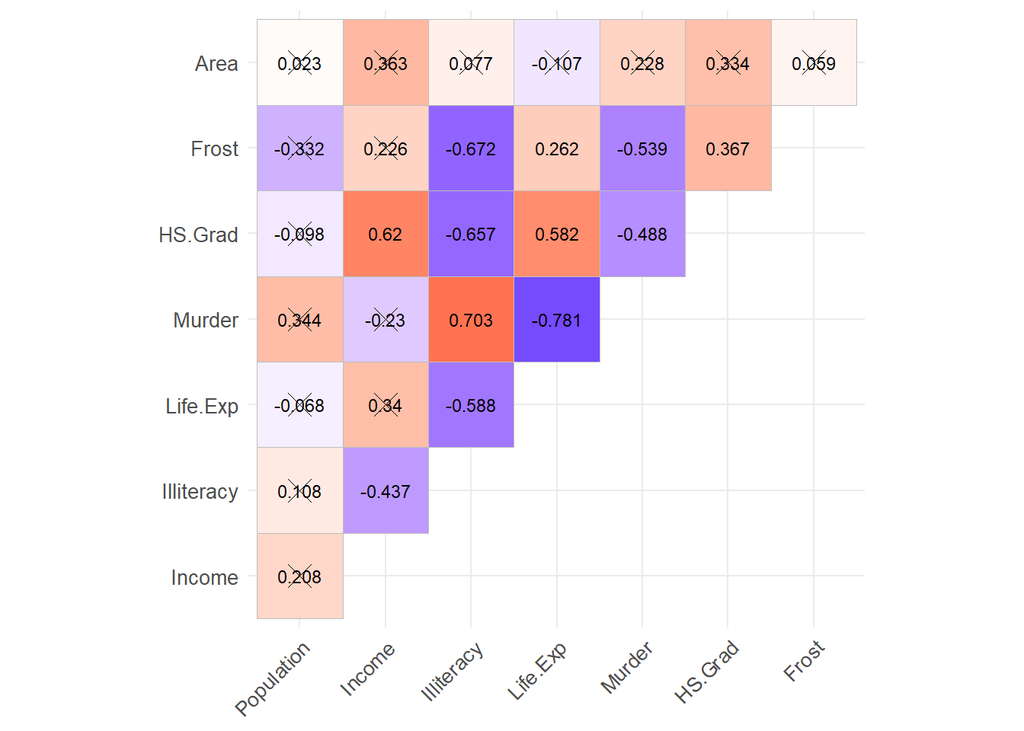

```r
corr <- round(cor(states), 3)
p.mat <- cor_pmat(corr)

ggcorrplot(corr, method="square", type="upper",
           lab=T, lab_size = 3, tl.cex = 10, digits=4, p.mat= p.mat) +
  theme(legend.position = "none")
```

## 17.3 T-test

Example: are SAT scores significant different according to gender? Conduct a Bartlett Test first to determine whether variances among the two groups are equal - this will determine which variant of the T-test to use.

```r
bartlett.test(psych::sat.act$SATV ~ psych::sat.act$gender)
```

```
    Bartlett test of homogeneity of variances

data:  psych::sat.act$SATV by psych::sat.act$gender
Bartlett's K-squared = 0.085108, df = 1, p-value = 0.7705
```

Alternatively, use a Wilcox (Mann-Whitney/U) test

```r
# if p > .05, assume equal variances
wilcox.test(psych::sat.act$SATV ~ psych::sat.act$gender)
```

```
    Wilcoxon rank sum test with continuity correction

data:  psych::sat.act$SATV by psych::sat.act$gender
W = 57518, p-value = 0.5379
alternative hypothesis: true location shift is not equal to 0
```

The main base R function is `t.test`. Note that `var.equal` controls whether a Student t-test or Welch t-test is conducted. A Welch test is a better alternative because it is less restrictive and doesn’t assume equality of variances.

```r
# Student T-test
t.test(psych::sat.act$SATV ~ psych::sat.act$gender, var.equal = T)
```

```
    Two Sample t-test

data:  psych::sat.act$SATV by psych::sat.act$gender
t = 0.49792, df = 698, p-value = 0.6187
alternative hypothesis: true difference in means between group 1 and group 2 is not equal to 0
95 percent confidence interval:
 -13.09357  21.99137
sample estimates:
mean in group 1 mean in group 2
       615.1134        610.6645
```

```r
t.test(psych::sat.act$SATV ~ psych::sat.act$gender, var.equal = F)
```

```
    Welch Two Sample t-test

data:  psych::sat.act$SATV by psych::sat.act$gender
t = 0.49553, df = 498.58, p-value = 0.6204
alternative hypothesis: true difference in means between group 1 and group 2 is not equal to 0
95 percent confidence interval:
 -13.19045  22.08826
sample estimates:
mean in group 1 mean in group 2
       615.1134        610.6645
```

To conduct t-tests among multiple variables simultaneously. Example: compare petal length, petal width, sepal length, and sepal width among the three plant species Setosa, Versicolor, and Virginica. Add a Benjimini-Hochberg correction for multiple comparisons and custom cutpoints for p-value asterisks. Note that `estimate1` and `estimate2` indicate the mean for each group, whereas `estimate` is the t-test coefficient itself.

```r
iris %>%
  pivot_longer(-c(Species)) %>%
  group_by(name) %>%
  t_test(value ~ Species, paired = F, detailed = T) %>%
  adjust_pvalue(method = "BH") %>%
  add_significance(cutpoints = c(0, 0.01, 0.05, 1),
                   symbols = c("**", "*", "")) %>%
  head()
```

| name | estimate | estimate1 | estimate2 | .y. | group1 | group2 | n1 | n2 | statistic | p | df | conf.low | conf.high | method | alternative | p.adj | p.adj.signif |
| --- | --- | --- | --- | --- | --- | --- | --- | --- | --- | --- | --- | --- | --- | --- | --- | --- | --- |
| Petal.Length | -2.798 | 1.462 | 4.260 | value | setosa | versicolor | 50 | 50 | -39.49272 | 0 | 62.13977 | -2.9396178 | -2.6563822 | T-test | two.sided | 0 | ** |
| Petal.Length | -4.090 | 1.462 | 5.552 | value | setosa | virginica | 50 | 50 | -49.98619 | 0 | 58.60939 | -4.2537495 | -3.9262505 | T-test | two.sided | 0 | ** |
| Petal.Length | -1.292 | 4.260 | 5.552 | value | versicolor | virginica | 50 | 50 | -12.60378 | 0 | 95.57044 | -1.4954903 | -1.0885097 | T-test | two.sided | 0 | ** |
| Petal.Width | -1.080 | 0.246 | 1.326 | value | setosa | versicolor | 50 | 50 | -34.08034 | 0 | 74.75469 | -1.1431328 | -1.0168672 | T-test | two.sided | 0 | ** |
| Petal.Width | -1.780 | 0.246 | 2.026 | value | setosa | virginica | 50 | 50 | -42.78580 | 0 | 63.12262 | -1.8631330 | -1.6968670 | T-test | two.sided | 0 | ** |
| Petal.Width | -0.700 | 1.326 | 2.026 | value | versicolor | virginica | 50 | 50 | -14.62537 | 0 | 89.04338 | -0.7951002 | -0.6048998 | T-test | two.sided | 0 | ** |

## 17.4 Effect size

Compute effect sizes to accompany the above t-test results (Cohen’s D with Hedges correction):

```r
iris %>%
  pivot_longer(-c(Species)) %>%
  group_by(name) %>%
  cohens_d(value ~ Species, paired = F, hedges.correction = T) %>%
  head()
```

| .y. | group1 | group2 | effsize | name | n1 | n2 | magnitude |
| --- | --- | --- | --- | --- | --- | --- | --- |
| value | setosa | versicolor | -7.837941 | Petal.Length | 50 | 50 | large |
| value | setosa | virginica | -9.920532 | Petal.Length | 50 | 50 | large |
| value | versicolor | virginica | -2.501415 | Petal.Length | 50 | 50 | large |
| value | setosa | versicolor | -6.763771 | Petal.Width | 50 | 50 | large |
| value | setosa | virginica | -8.491504 | Petal.Width | 50 | 50 | large |
| value | versicolor | virginica | -2.902630 | Petal.Width | 50 | 50 | large |

## 17.5 Regression

### 17.5.1 Linear regression

```r
# model set up
# notes:
# - use scale(wt) to center variable
# - use I(weight^2) to add quadratic term or I(weight^3) for cubic

# NOTE that scale() on its own will not work - do the following
# df = df %>% mutate(var_scaled = as.vector(scale(var, center = T, scale = T)))

# use Maths achievement data from Rdatasets
df = Rdatasets::rddata("MathAchieve")

model_ln = lm(MathAch ~ Minority + Sex + SES, data = df)

# model output
summary(model_ln)
```

```
Call:
lm(formula = MathAch ~ Minority + Sex + SES, data = df)

Residuals:
     Min       1Q   Median       3Q      Max
-19.6401  -4.5587   0.2658   4.9098  17.5411

Coefficients:
            Estimate Std. Error t value            Pr(>|t|)
(Intercept) 12.87725    0.11207  114.90 <0.0000000000000002 ***
MinorityYes -2.83651    0.17198  -16.49 <0.0000000000000002 ***
SexMale      1.37665    0.14835    9.28 <0.0000000000000002 ***
SES          2.68299    0.09873   27.18 <0.0000000000000002 ***
---
Signif. codes:  0 '***' 0.001 '**' 0.01 '*' 0.05 '.' 0.1 ' ' 1

Residual standard error: 6.263 on 7181 degrees of freedom
Multiple R-squared:  0.1713,    Adjusted R-squared:  0.171
F-statistic: 494.8 on 3 and 7181 DF,  p-value: < 0.00000000000000022
```

```r
# or use broom
broom::tidy(model_ln)
```

| term | estimate | std.error | statistic | p.value |
| --- | --- | --- | --- | --- |
| (Intercept) | 12.877245 | 0.1120705 | 114.903115 | 0 |
| MinorityYes | -2.836513 | 0.1719763 | -16.493625 | 0 |
| SexMale | 1.376645 | 0.1483467 | 9.279916 | 0 |
| SES | 2.682990 | 0.0987258 | 27.176189 | 0 |

```r
# isolated outputs
coefficients(model_ln)
```

```
(Intercept) MinorityYes     SexMale         SES
  12.877245   -2.836513    1.376645    2.682990
```

```r
confint(model_ln)
```

```
                2.5 %    97.5 %
(Intercept) 12.657554 13.096936
MinorityYes -3.173637 -2.499389
SexMale      1.085842  1.667449
SES          2.489458  2.876521
```

```r
# residuals(model_ln)

# Get stats for each observation, inc fitted, std. resid, hat, and cooksd.
# these stats are added as new columns to the original dataset if you specify
# the original dataframe under 'data'
model_diagnostics = augment(x = model_ln, data = df)

model_diagnostics %>% head()
```

| rownames | School | Minority | Sex | SES | MathAch | MEANSES | .fitted | .resid | .hat | .sigma | .cooksd | .std.resid |
| --- | --- | --- | --- | --- | --- | --- | --- | --- | --- | --- | --- | --- |
| 1 | 1224 | No | Female | -1.528 | 5.876 | -0.428 | 8.777637 | -2.901637 | 0.0009632 | 6.263072 | 0.0000518 | -0.4635415 |
| 2 | 1224 | No | Female | -0.588 | 19.708 | -0.428 | 11.299647 | 8.408353 | 0.0004303 | 6.262379 | 0.0001941 | 1.3428910 |
| 3 | 1224 | No | Male | -0.528 | 20.349 | -0.428 | 12.837272 | 7.511728 | 0.0004708 | 6.262538 | 0.0001695 | 1.1997161 |
| 4 | 1224 | No | Male | -0.668 | 8.781 | -0.428 | 12.461653 | -3.680653 | 0.0005251 | 6.263015 | 0.0000454 | -0.5878619 |
| 5 | 1224 | No | Male | -0.158 | 17.898 | -0.428 | 13.829978 | 4.068022 | 0.0003741 | 6.262981 | 0.0000395 | 0.6496821 |
| 6 | 1224 | No | Male | 0.022 | 4.583 | -0.428 | 14.312916 | -9.729916 | 0.0003516 | 6.262112 | 0.0002123 | -1.5538956 |

### 17.5.2 Logistic Regression

```r
#model_log = glm(Survived ~ Pclass + Sex + Age, data = titanic::titanic_train, family = binomial(link = "logit"))

#df = Rdatasets::rddata("Gcsemv")
df2 = Rdatasets::rddata("Exam")

# wrangling for modelling
# LRT  = London Reading Test
df2 = df2 %>%
  # make binary outcome for normexam score => 0
  mutate(pass = if_else(normexam >= 0, 1, 0)) %>%
  # convert Verbal Reasoning category to numeric
  mutate(vr_cat = case_when(
    vr == "bottom 25%" ~ -1,
    vr == "mid 50%" ~ 0,
    vr == "top 25%" ~ 1
  )) %>%
  mutate(vr_cat = as.factor(vr_cat))

# fit model
# note that the reference category by default is the value that is first numerically
# or alphabetically. For vr_cat here, the reference is -1 (bottom 25%).
model_log = glm(pass ~ standLRT + vr_cat + sex + type, data = df2, family = binomial(link = "logit"))

summary(model_log)
```

```
Call:
glm(formula = pass ~ standLRT + vr_cat + sex + type, family = binomial(link = "logit"),
    data = df2)

Coefficients:
            Estimate Std. Error z value             Pr(>|z|)
(Intercept) -0.36337    0.10963  -3.314             0.000918 ***
standLRT     1.26348    0.04887  25.852 < 0.0000000000000002 ***
vr_cat0      0.18238    0.10601   1.720             0.085361 .
vr_cat1      0.43439    0.11854   3.665             0.000248 ***
sexM        -0.08267    0.07681  -1.076             0.281813
typeSngl     0.47632    0.07547   6.311       0.000000000277 ***
---
Signif. codes:  0 '***' 0.001 '**' 0.01 '*' 0.05 '.' 0.1 ' ' 1

(Dispersion parameter for binomial family taken to be 1)

    Null deviance: 5624.6  on 4058  degrees of freedom
Residual deviance: 4488.0  on 4053  degrees of freedom
AIC: 4500

Number of Fisher Scoring iterations: 4
```

```r
# to extract p-values
coef(summary(model_log))[,4]
```

[output not shown]

```r
broom::glance(model_log) # gives r2, AIC/BIC, etc
```

| null.deviance | df.null | logLik | AIC | BIC | deviance | df.residual | nobs |
| --- | --- | --- | --- | --- | --- | --- | --- |
| 5624.554 | 4058 | -2244.014 | 4500.029 | 4537.881 | 4488.029 | 4053 | 4059 |

```r
# Alternatively, use `broom` to get tidy model output
broom::tidy(model_log, confint=T, exponentiate = T)
```

| term | estimate | std.error | statistic | p.value |
| --- | --- | --- | --- | --- |
| (Intercept) | 0.6953260 | 0.1096329 | -3.314464 | 0.0009182 |
| standLRT | 3.5377197 | 0.0488742 | 25.851750 | 0.0000000 |
| vr_cat0 | 1.2000651 | 0.1060082 | 1.720394 | 0.0853609 |
| vr_cat1 | 1.5440149 | 0.1185374 | 3.664548 | 0.0002478 |
| sexM | 0.9206549 | 0.0768127 | -1.076255 | 0.2818134 |
| typeSngl | 1.6101386 | 0.0754715 | 6.311258 | 0.0000000 |

```r
# nifty little trick to amend rounding
broom::tidy(model_log) %>%
  mutate(across(where(is.numeric), \(x) round(x, 3))) %>%
     rename("coefficient" = "estimate")
```

| term | coefficient | std.error | statistic | p.value |
| --- | --- | --- | --- | --- |
| (Intercept) | -0.363 | 0.110 | -3.314 | 0.001 |
| standLRT | 1.263 | 0.049 | 25.852 | 0.000 |
| vr_cat0 | 0.182 | 0.106 | 1.720 | 0.085 |
| vr_cat1 | 0.434 | 0.119 | 3.665 | 0.000 |
| sexM | -0.083 | 0.077 | -1.076 | 0.282 |
| typeSngl | 0.476 | 0.075 | 6.311 | 0.000 |

```r
# alternative: use gtsummary's tbl_regression()
# note:
# change show_single_row = c("Sex") to collapse this to a single row
# will need to install broom.helpers
pacman::p_load(broom.helpers)

model_log %>%
  gtsummary::tbl_regression(
              exponentiate = T,
              pvalue_fun = label_style_pvalue(digits = 3),
              show_single_row = NULL) %>%
  bold_p(t = 0.05) %>%
  bold_labels() %>%
  add_vif() %>%
  add_nevent() %>%
  add_glance_source_note()
```

| **Characteristic** | **Event N** | **OR** | **95% CI** | **p-value** | **GVIF** | **Adjusted GVIF**<sup>1</sup> |
| --- | --- | --- | --- | --- | --- | --- |
| standLRT | 2,079 | 3.54 | 3.22, 3.90 | <0.001 | 1.0 | 1.0 |
| vr_cat | 2,079 |  |  |  | 1.0 | 1.0 |
| -1 |  | — | — |  |  |  |
| 0 |  | 1.20 | 0.98, 1.48 | 0.085 |  |  |
| 1 |  | 1.54 | 1.22, 1.95 | <0.001 |  |  |
| sex | 2,079 |  |  |  | 1.1 | 1.0 |
| F |  | — | — |  |  |  |
| M |  | 0.92 | 0.79, 1.07 | 0.282 |  |  |
| type | 2,079 |  |  |  | 1.1 | 1.0 |
| Mxd |  | — | — |  |  |  |
| Sngl |  | 1.61 | 1.39, 1.87 | <0.001 |  |  |

<sup>1</sup> GVIF^[1/(2*df)]  
Abbreviations: CI = Confidence Interval, GVIF = Generalized Variance Inflation Factor, OR = Odds Ratio  
Null deviance = 5,625; Null df = 4,058; Log-likelihood = -2,244; AIC = 4,500; BIC = 4,538; Deviance = 4,488; Residual df = 4,053; No. Obs. = 4,059

### 17.5.3 Interactions and polynomial terms

Linear regression can also handle curves. How to know when you need this? A residual plot might show lots of negative or positive values at the extreme ends. Note: you should expect very high multicollinearity for any polynomial terms - this can be [ignored](https://statisticalhorizons.com/multicollinearity/).

```r
# note that you should retain the original predictor and ADD a quadratic version
# of that same predictor rather than replacing it.

# quadratic term (one 'hump')
model_ln = lm(mpg ~ wt + I(wt^2) , data = mtcars)

# cubic term (two 'humps')
model_ln = lm(mpg ~ wt + I(wt^3) , data = mtcars)

# for an exploratory approach, you can add interactions for all variables in the model
m = lm(DV ~ main_IV *
         (c_iv1 +
          c_iv2 +
          c_iv3),
       data = df)
```

```r
# create model with interaction term
# using ggeffects package
data(efc, package = "ggeffects")
efc = efc
efc$c161sex = factor(efc$c161sex)

# fit model with interaction
fit = lm(neg_c_7 ~ c12hour + barthtot * c161sex, data = efc)

# plot for certain intervals of barthtot - if this was a scaled variable you could
# do barthtot [-1,0,1] for instance.
mydf = ggeffects::predict_response(fit, terms = c("barthtot [30,50,70]", "c161sex"))

mydf
```

| x | predicted | std.error | conf.low | conf.high | group |
| --- | --- | --- | --- | --- | --- |
| 30 | 13.01833 | 0.4098713 | 12.21387 | 13.82278 | 1 |
| 30 | 13.67839 | 0.2211952 | 13.24425 | 14.11253 | 2 |
| 50 | 12.13771 | 0.2863625 | 11.57566 | 12.69975 | 1 |
| 50 | 12.67269 | 0.1544149 | 12.36962 | 12.97576 | 2 |
| 70 | 11.25709 | 0.2456415 | 10.77497 | 11.73921 | 1 |
| 70 | 11.66700 | 0.1392470 | 11.39370 | 11.94030 | 2 |

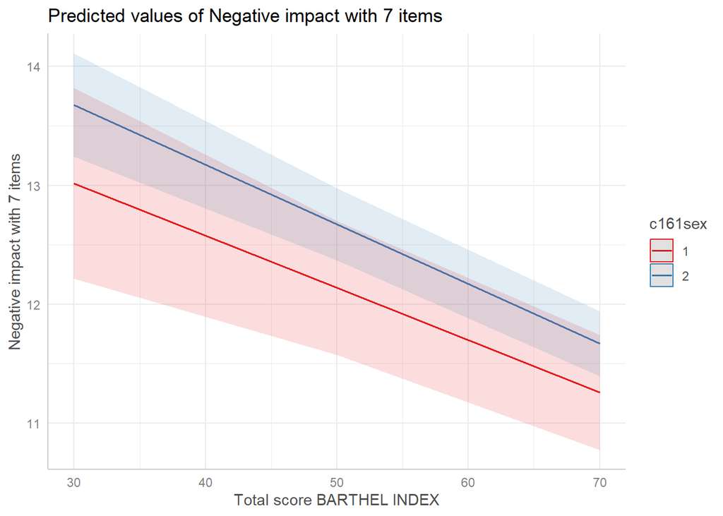

```r
plot(mydf)
```

```r
# note that sJplot produces exactly the same thing
# sjPlot::plot_model(fit, type = "pred", terms = c("barthtot [30,50,70]", "c161sex")) +
#   scale_x_continuous(breaks = c(30,50,70)) +
#   ggtitle("Predicted probabilities")
```

### 17.5.4 Estimated marginal means

You can also look at estimated marginal means, but this is something different. I think this differs from `plot_predictions` in restricting predictors to zero/reference levels, rather than reflecting the distributions present in the data itself.

YOU MAY GET DIFFERENT RESULTS TO `ggeffects` above!!! This is because they use different averaging strategies - `ggeffects` averages over the values of covariates, while `emmeans` fixes them at their means. The differences in the values, e.g. between -1 and 0 SD will still be the same between the two packages though, and so will the slopes.

```r
# this code uses the model 'fit' and looks at the interaction of barthtot and c161sex
# for 3 different values of att8
# (if you are using cluster robust SEs, pass the vcov matrix to emmeans, otherwise leave
# this out)
# you can add vcov = vcov_cluster if you have one too
em = emmeans::emmeans(fit, ~ barthtot | c161sex,
                 at = list(att8 = c(30,50,70)), type = "response")
summary(em)
```

| barthtot | c161sex | emmean | SE | df | lower.CL | upper.CL |
| --- | --- | --- | --- | --- | --- | --- |
| 64.70218 | 1 | 11.49036 | 0.2445716 | 868 | 11.01034 | 11.97038 |
| 64.70218 | 2 | 11.93340 | 0.1362392 | 868 | 11.66600 | 12.20080 |

```r
pairs(em)
```

```
c161sex = 1:
 contrast  estimate SE df z.ratio p.value
 (nothing)   nonEst NA NA      NA      NA

c161sex = 2:
 contrast  estimate SE df z.ratio p.value
 (nothing)   nonEst NA NA      NA      NA
```

```r
# check reference grid to see the values at which slopes are being evaluated
emmeans::ref_grid(fit)
```

```
'emmGrid' object with variables:
    c12hour = 42.055
    barthtot = 64.702
    c161sex = 1, 2
```

Another useful tool from `emmeans` is `emtrends` which allows you to see trends for different values of categorical covariates.

```r
# for categorical (where fsm6 has 2 values)
emtrends(fit, ~ c_fsm6,
         var = "study_leave_rate",
         vcov. = vcov_cluster)

# or numeric
emtrends(m3, ~ ks2emss_s, var = "study_leave_rate",
         at = list(ks2emss_s = c(-1, 0, 1),
         vcov. = vcov_cluster))

# combine with emmip from emmeans to visualise
emmip(m3, c_selective ~ study_leave_rate,
          at = list(study_leave_rate = c(0, 5, 10)),
          CIs = F)

# or for numeric:
# save emms first
ks2_emm = emmeans(m3, ~ study_leave_rate | ks2emss_s,
               at = list(study_leave_rate = c(0, 5, 10),
                         ks2emss_s = c(-1, 0, 1)))
# turn into dataframe
ks2_df = as.data.frame(ks2_emm)

# create factors for groupings of interest, e.g. -1,0,+1 SD
ks2_df$group <- factor(
  ks2_df$ks2emss_s,
  levels = c(-1, 0, 1),
  labels = c("-1 SD", "Mean", "+1 SD")
)

# plot directly
ggplot(ks2_df, aes(x = study_leave_rate_5ht_pp, y = emmean, colour = group)) +
  geom_line(linewidth = 0.8)

# also predict_response?
# note that this visualises slopes while holding other covariates at their typical
# values (e.g. mean or reference value)
#plot(ggeffects::predict_response(fit, terms = c("study_leave_rate_5ht_s [-1,0,1]", "c_fsm6"),
#                                 vcov = vcov_cluster))
```

### 17.5.5 Diagnostics

#### 17.5.5.1 Linearity

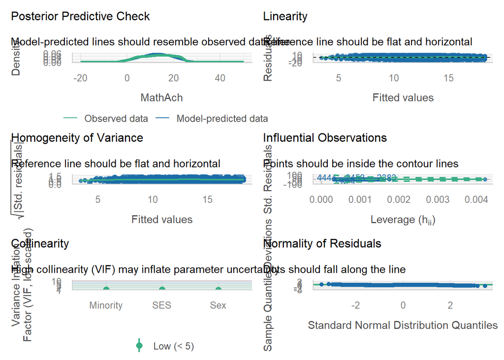

```r
# quick method to start with - produces lots of tests but can take time if large model
performance::check_model(model_ln)
```

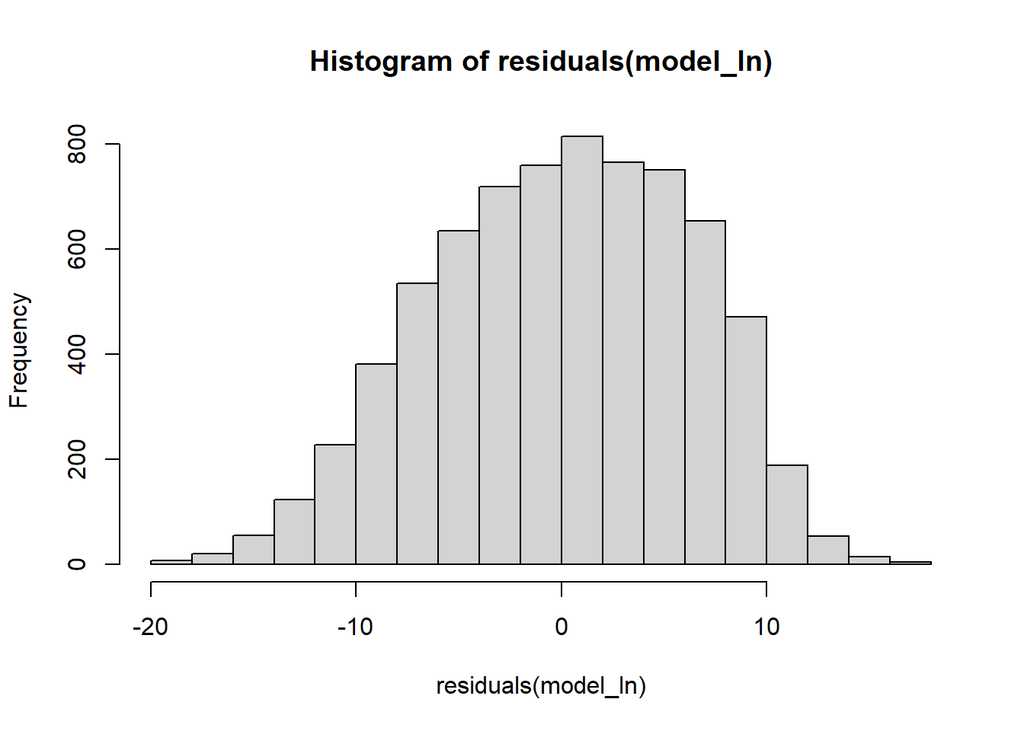

```r
# simple histogram of residuals
hist(residuals(model_ln))
```

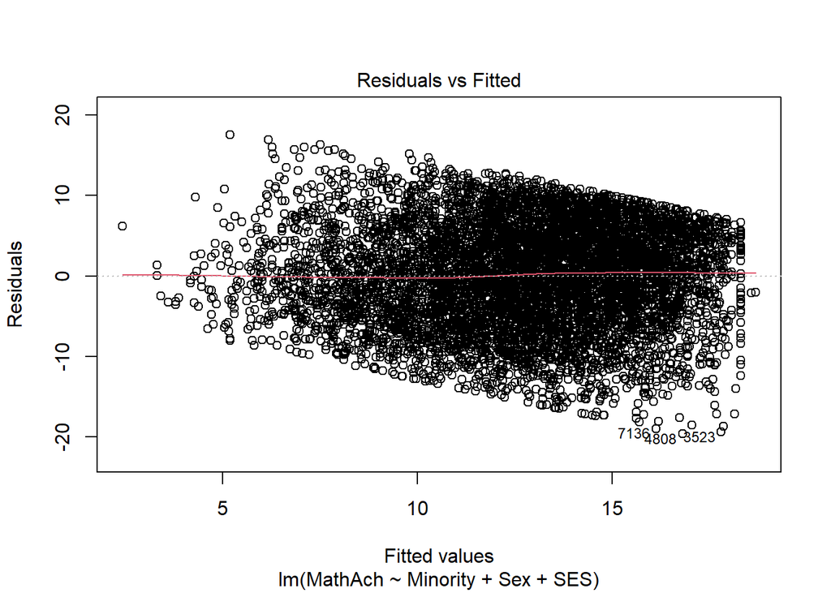

```r
plot(model_ln, which = 1) # residuals vs fitted
```

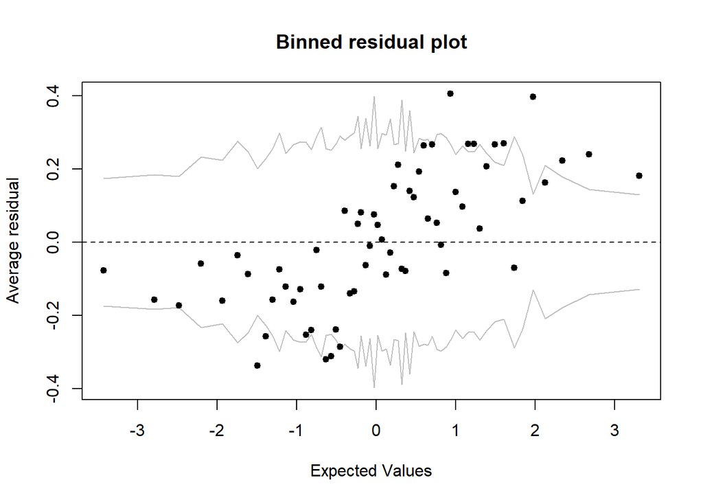

```r
# for log reg try a binned residual plot 95% of dots should be within the grey lines
arm::binnedplot(predict(model_log), resid(model_log))
```

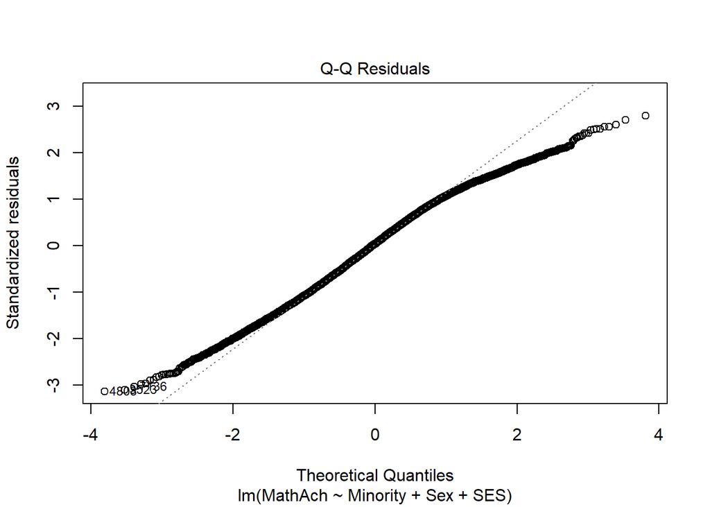

```r
plot(model_ln, which = 2) # QQ plot
```

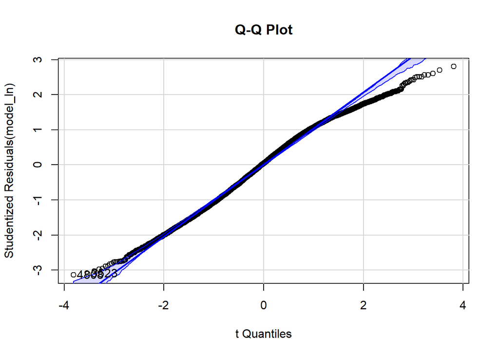

```
[1] 3523 4808
```

```r
# QQ plot with 95% CI (also outputs row id of 2 largest residuals)
car::qqPlot(model_ln, labels = row.names(model_ln), id.method="identify", simulate=TRUE, main="Q-Q Plot")
```

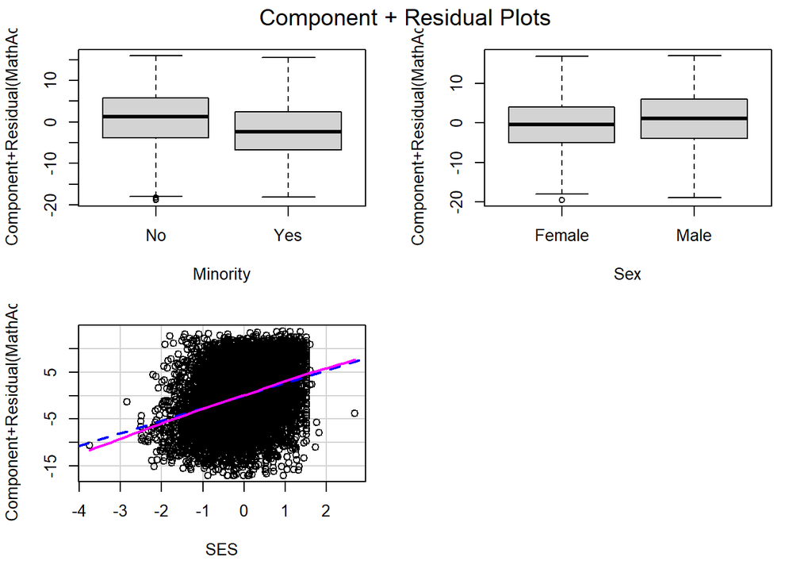

```r
# Partial-residual plots for all predictors
# note: for numeric variables, this produces a linear fit in blue and a smooth
# fit in solid magenta
# (only available if model has no interactions - for interactions, use crPlot3d)
car::crPlots(model_ln)
```

Note that if you have a very large sample and it takes too long to render `crPlots`, rerun the model with a random sample.

```r
set.seed(123)

idx <- sample(nrow(model.frame(model_ln)), 10000)

model_sample <- lm(
  formula(model_ln),
  data = model.frame(model_ln)[idx, ]
)

car::crPlots(model_sample)

# you can make this into a reusable sample, e.g
sample_refit = function(model, sample_size){
  dat = model.frame(model)
  idx = sample(nrow(dat), sample_size)
  m_sample = lm(formula(model), data = dat[idx, ])
}

plot(sample_refit(m, 10000), which = 1) # residuals vs fitted plot
```

#### 17.5.5.2 Heteroskedasticity (non-constant error variance)

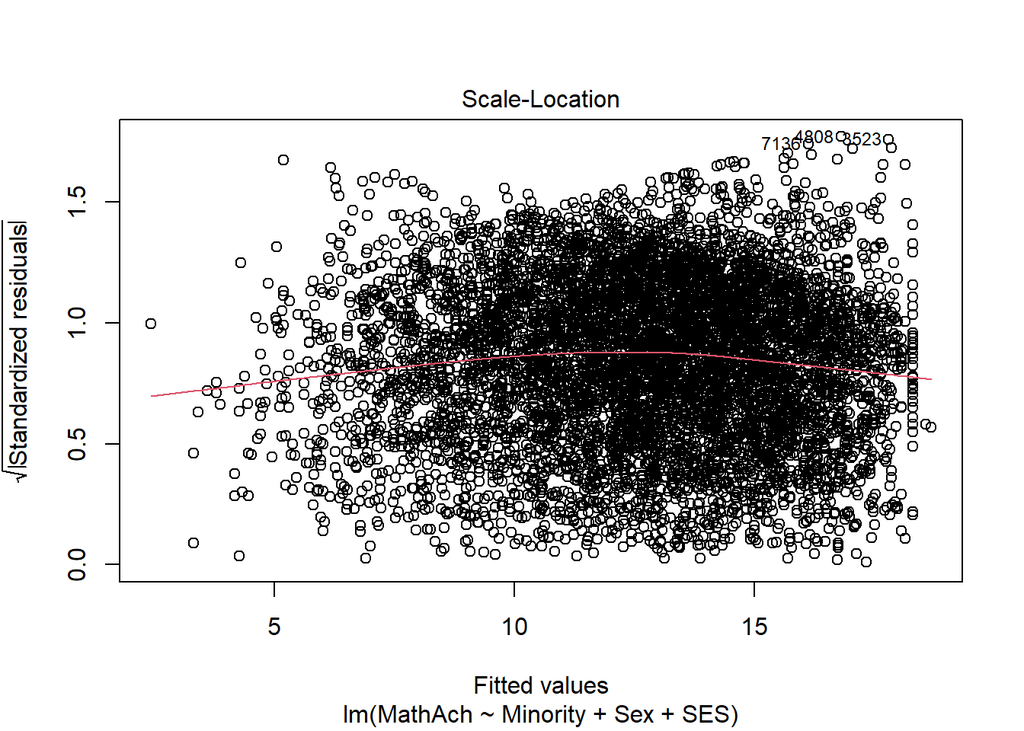

```r
plot(model_ln, which = 3) # scale-location (for heteroskedasticity)
```

```r
# Breusch-Pagan test - if p<.05 then there is heteroskedasticity
lmtest::bptest(model_ln)
```

```
    studentized Breusch-Pagan test

data:  model_ln
BP = 34.684, df = 3, p-value = 0.0000001421
```

```r
# performance also provides the BP test but gives a different result...
performance::check_heteroscedasticity(model_ln)
```

```
OK: Error variance appears to be homoscedastic (p = 0.697).
```

```r
car::ncvTest(model_ln) # If non-sig, assumption is met.
```

```
Non-constant Variance Score Test
Variance formula: ~ fitted.values
Chisquare = 0.1516566, Df = 1, p = 0.69696
```

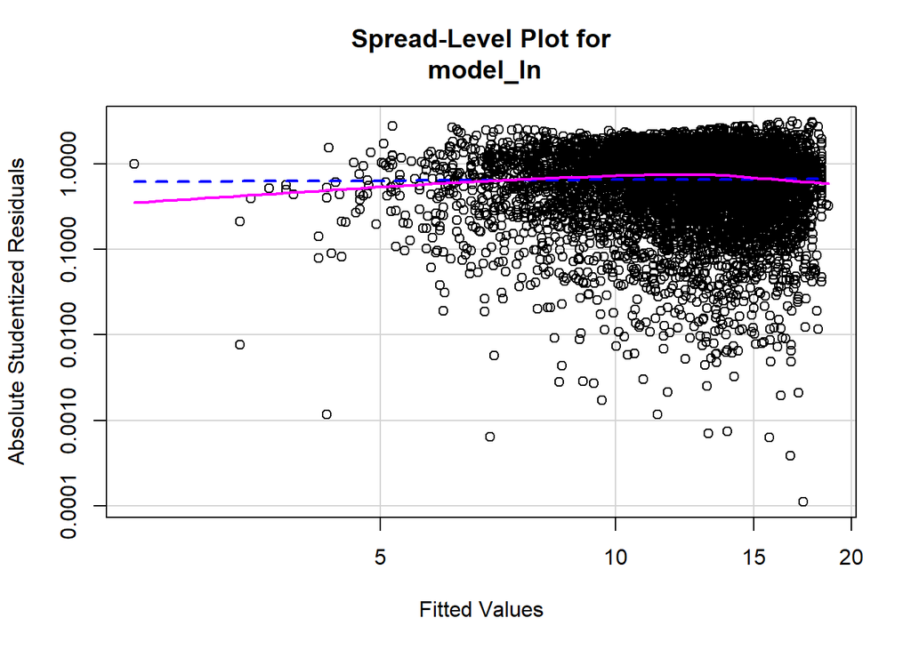

```
Suggested power transformation:  0.9580909
```

```r
# Tukey spread level plot
car::spreadLevelPlot(model_ln) # looking for a horizontal line
```

```r
# also prints a suggested power transformation number to fix non-constant variance

# you can use the below to rerun the model using a heteroskedasticity-robust
# variance-covariance matrix. If the results are similar, then it's not having
# a considerable effect.
lmtest::coeftest(model_ln, vcov = vcovHC(model_ln, type = "HC3"))
```

```
t test of coefficients:

             Estimate Std. Error  t value              Pr(>|t|)
(Intercept) 12.877245   0.109959 117.1095 < 0.00000000000000022 ***
MinorityYes -2.836513   0.173889 -16.3122 < 0.00000000000000022 ***
SexMale      1.376645   0.149234   9.2248 < 0.00000000000000022 ***
SES          2.682990   0.096376  27.8388 < 0.00000000000000022 ***
---
Signif. codes:  0 '***' 0.001 '**' 0.01 '*' 0.05 '.' 0.1 ' ' 1
```

#### 17.5.5.3 Multicollinearity

```r
# Variance inflation factor (VIF)
performance::check_collinearity(model_ln)

car::vif(model_ln)
# sqrt(VIF) > 2 indicates a potential problem
```

#### 17.5.5.4 Leverage and influence

```r
# Outliers
car::outlierTest(model_ln) # locates largest Studentized residual in absolute value and computes Bonferroni-corrected t-test

car::influencePlot(model_ln, id.method="identify", main="Influence Plot",
              sub="Circle size is proportional to Cook's distance")

# Explanation:
# Points above +2 or below -2 on the vertical axis are considered outliers.
# Points above 0.2 or 0.3 on the horizontal axis have high leverage (unusual
# combinations of predictor values). Circle size is proportional to influence.
# Observations depicted by large circles may have disproportionate influence on the
# parameters estimates of the model.
```

#### 17.5.5.5 Other diagnostics

```r
# Durbin Watson test against autocorrelation of disturbances
lmtest::dwtest(model_ln)

car::durbinWatsonTest(model_ln)   # non-sig equals lack of autocorrelation
# lag value=1 means each obs is being compared to one next to it
```

### 17.5.6 Average marginal effects

Average marginal effects (AMEs) have been suggested as an alternative to odds ratios. They represent the change in the probability of an event occurring, controlling for other covariates. In other words, an AME tells you the percentage point change in the probability of an outcome thanks to a particular predictor. I think their advantage is that they can be used when the aim is to compare across different models.

```r
# use the margins package

# run your glm model as usual
# then run margins::margins
ame = margins::margins(model_log)
summary(ame)
```

| factor | AME | SE | z | p | lower | upper |
| --- | --- | --- | --- | --- | --- | --- |
| sexM | -0.0155041 | 0.0144227 | -1.074978 | 0.2823845 | -0.0437720 | 0.0127639 |
| standLRT | 0.2365745 | 0.0059996 | 39.431719 | 0.0000000 | 0.2248155 | 0.2483335 |
| typeSngl | 0.0895537 | 0.0140565 | 6.370975 | 0.0000000 | 0.0620034 | 0.1171039 |
| vr_cat0 | 0.0346941 | 0.0201929 | 1.718138 | 0.0857715 | -0.0048832 | 0.0742714 |
| vr_cat1 | 0.0824482 | 0.0226707 | 3.636779 | 0.0002761 | 0.0380145 | 0.1268819 |

```r
# will provide AMEs (percentages) for each covariate along with SE, z, P, and 95% CI.

# if using sandwich SEs, estimate vcov first, then feed in to margins:
vcov_cluster = sandwich::vcovCL(model_log, cluster = ~ school)
model_cluster_ame = margins::margins(model_log, vcov = vcov_cluster)
summary(model_cluster_ame)
```

| factor | AME | SE | z | p | lower | upper |
| --- | --- | --- | --- | --- | --- | --- |
| sexM | -0.0155041 | 0.0190635 | -0.8132828 | 0.4160559 | -0.0528679 | 0.0218598 |
| standLRT | 0.2365745 | 0.0077994 | 30.3323521 | 0.0000000 | 0.2212880 | 0.2518611 |
| typeSngl | 0.0895537 | 0.0291489 | 3.0722875 | 0.0021243 | 0.0324230 | 0.1466844 |
| vr_cat0 | 0.0346941 | 0.0438005 | 0.7920943 | 0.4283057 | -0.0511533 | 0.1205415 |
| vr_cat1 | 0.0824482 | 0.0547522 | 1.5058418 | 0.1321078 | -0.0248642 | 0.1897606 |

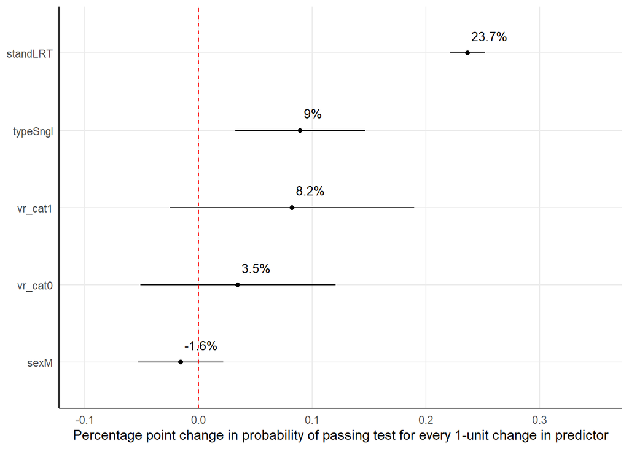

```r
# visualise this
# convert to df first
model_cluster_ame_df = as.data.frame(summary(model_cluster_ame))
model_cluster_ame_df %>%
  ggplot(aes(x = reorder(factor, AME, decreasing=F), y = AME)) +
  geom_point() +
  geom_linerange(aes(ymin = lower, ymax = upper)) +
  geom_hline(yintercept = 0, linetype = "dashed", colour = "red") +
  scale_y_continuous(breaks = seq(-0.1,0.4, by = 0.1),
                     limits = c(-0.1, 0.35)) +
  theme_minimal() +
  theme(axis.title.y = element_blank(),
        panel.grid.minor = element_blank(),
        axis.line = element_line(colour = "black")) +
  coord_flip() +
  geom_label(aes(label = paste0(round(AME,3)*100,"%")),
             size = 3.5,
             alpha = 1,
             vjust = -0.5,
             hjust = 0,
             fill = NA,
             border.colour = NA) +
  ylab("Percentage point change in probability of passing test for every 1-unit change in predictor")
```

```r
# predict with new data
new.height = data.frame(height = c(99, 105, 166))
predict(model, newdata = new.height)
```

### 17.5.7 Model fit and comparison

There are several measures to quantify how well a model fits the data. To extract R2 from the original model output, try:

- `summary(model_ln)$r.squared`
- `performance::r2(model_ln)`

```r
# get a range of model fit stats
performance::model_performance(model_ln) # shows AIC, R2, ICC, RMSE all together
```

| AIC | AICc | BIC | R2 | R2_adjusted | RMSE | Sigma |
| --- | --- | --- | --- | --- | --- | --- |
| 46759.58 | 46759.59 | 46793.98 | 0.171313 | 0.1709668 | 6.260986 | 6.262729 |

```r
broom::glance(model_ln)
```

| r.squared | adj.r.squared | sigma | statistic | p.value | df | logLik | AIC | BIC | deviance | df.residual | nobs |
| --- | --- | --- | --- | --- | --- | --- | --- | --- | --- | --- | --- |
| 0.171313 | 0.1709668 | 6.262729 | 494.8386 | 0 | 3 | -23374.79 | 46759.58 | 46793.98 | 281651.6 | 7181 | 7185 |

```r
# to get AIC or BIC alone:
# AIC(model_ln)
# BIC(model_ln)
```

You can compare model fit using Wald or Likelihood Ratio Tests:

```r
# fit second model for comparison
model_ln2 = lm(MathAch ~ Minority *Sex + SES, data = df)

# Wald test
anova(model_ln, model_ln2)
# or:
lmtest::waldtest(model_ln, model_ln2)

# likelihood ratio test using Chisq (deviance)
anova(model_ln, model_ln2, test = "Chisq")
# or:
lmtest::lrtest(model_ln, model_ln2)
```

### 17.5.8 Cluster-robust standard errors

To account for clustering in the data (not to model it specifically), you can apply cluster-robust standard errors after White (1984).

```r
# fit your model as usual, e.g. with lm() or glm()

# obtain cluster-robust errors with clustering specified
vcov_cluster = sandwich::vcovCL(model_ln, cluster = ~ School)

# Coefficient table with clustered SEs
lmtest::coeftest(model_ln, vcov = vcov_cluster)
```

```
t test of coefficients:

            Estimate Std. Error t value              Pr(>|t|)
(Intercept) 12.87725    0.17220 74.7790 < 0.00000000000000022 ***
MinorityYes -2.83651    0.31089 -9.1239 < 0.00000000000000022 ***
SexMale      1.37665    0.23843  5.7737        0.000000008076 ***
SES          2.68299    0.13988 19.1808 < 0.00000000000000022 ***
---
Signif. codes:  0 '***' 0.001 '**' 0.01 '*' 0.05 '.' 0.1 ' ' 1
```

```r
# compare with original - Std. Error is higher when using clusters
coef(summary(model_ln))[,2]
```

```
(Intercept) MinorityYes     SexMale         SES
 0.11207046  0.17197631  0.14834675  0.09872575
```

```r
# alternatively use fixest for logistic models
# this is very fast but it's not easy to exponentiate when using logistic
p_load(fixest)
# fit model using:
model_fixest = fixest::feglm(pass ~ standLRT + vr_cat + sex + type,
                             data = df2,
                             family = binomial(link = "logit"),
                             cluster = ~ school)

summary(model_fixest)
```

```
GLM estimation, family = binomial(link = "logit"), Dep. Var.: pass
Observations: 4,059
Standard-errors: Clustered (school)
             Estimate Std. Error   z value  Pr(>|z|)
(Intercept) -0.363374   0.242991 -1.495425 0.1348036
standLRT     1.263482   0.060001 21.057749 < 2.2e-16 ***
vr_cat0      0.182376   0.230486  0.791267 0.4287880
vr_cat1      0.434386   0.289187  1.502093 0.1330732
sexM        -0.082670   0.101787 -0.812186 0.4166847
typeSngl     0.476320   0.158007  3.014546 0.0025736 **
---
Signif. codes:  0 '***' 0.001 '**' 0.01 '*' 0.05 '.' 0.1 ' ' 1
Log-Likelihood: -2,244.0   Adj. Pseudo R2: 0.200287
           BIC:  4,537.9     Squared Cor.: 0.253153
```

```r
etable(model_fixest)
```

|  | model_fixest |
| --- | --- |
| Dependent Var.: | pass |
| Constant | -0.3634 (0.2430) |
| standLRT | 1.263*** (0.0600) |
| vr_cat0 | 0.1824 (0.2305) |
| vr_cat1 | 0.4344 (0.2892) |
| sexM | -0.0827 (0.1018) |
| typeSngl | 0.4763** (0.1580) |
| _______________ | _________________ |
| S.E.: Clustered | by: school |
| Observations | 4,059 |
| Squared Cor. | 0.25315 |
| Pseudo R2 | 0.20206 |
| BIC | 4,537.9 |

```r
exp(cbind(`Odds Ratio` = coef(model_fixest), confint(model_fixest)))
```

|  | Odds Ratio | 2.5 % | 97.5 % |
| --- | --- | --- | --- |
| (Intercept) | 0.6953260 | 0.4318713 | 1.119496 |
| standLRT | 3.5377197 | 3.1452171 | 3.979204 |
| vr_cat0 | 1.2000651 | 0.7638623 | 1.885361 |
| vr_cat1 | 1.5440149 | 0.8759813 | 2.721499 |
| sexM | 0.9206549 | 0.7541462 | 1.123927 |
| typeSngl | 1.6101386 | 1.1813191 | 2.194620 |

### 17.5.9 Reporting regression

### 17.5.10 `stargazer`

```r
stargazer(m1, m2,
          dep.var.labels = c("Attainment 8"),
          single.row = T,
          covariate.labels = c("Study leave rate", "FSM6", "Male", "EAL", "SEN",
                               "White British", "Selective", "KS4 cohort size",
                               "KS2 prior attainment", "KS2 prior quadratic",
                               "Study leave : FSM6", "Study leave : EAL",
                               "Study leave : SEN", "Study leave : selective",
                               "Study leave : KS2 prior"),
          type="text",
          out = "regression_results.txt")

# note that if you're using a regular lm object, stargazer will output model fit
# statistics below.
# If not, e.g. you're using coeftest because of sandwich SEs, you can do the following:
vcov_cluster1 <- sandwich::vcovCL(m2, cluster = ~ urn)
vcov_cluster2 <- sandwich::vcovCL(m4, cluster = ~ urn)

stargazer(
  m2,
  m4,
  se = list(
    sqrt(diag(vcov_cluster1)),
    sqrt(diag(vcov_cluster2))
  ),
  dep.var.labels = "Attainment 8",
  single.row = TRUE,
  covariate.labels = c(...),
  type = "text"
)
```

### 17.5.11 `modelsummary`

```r
modelsummary(
  list("Model 1" = m2, "Model 2" = m4),
  vcov = list(
    sandwich::vcovCL(m2, cluster = ~urn),
    sandwich::vcovCL(m4, cluster = ~urn)
  ),
  estimate  = "{estimate}{stars} ({std.error})",
  statistic = NULL,
  stars = c("*" = .05, "**" = .01, "***" = .001),
  # which model fit stats to leave out (grep)
  gof_omit = c('BIC|Num.Obs|R2$|Log.Lik'),
  # provide custom values for coefficients
  coef_map = c(
    study_leave_rate_5ht_s = "Study leave rate",
    c_fsm61 = "FSM6",
    c_male1 = "Male",
    c_eal1 =  "EAL",
    c_sen1 = "SEN",
    c_white_british1 = "White British",
    c_selective1 = "Selective",
    ks2_pupils = "KS4 cohort size",
    ks2emss = "KS2 prior attainment",
    # NOTE that anything with non-standard notation needs to be quoted
    "I(ks2emss^2)" = "KS2 prior quadratic",
    "study_leave_rate_5ht_s:c_fsm61" = "Study leave : FSM6",
    "study_leave_rate_5ht_s:c_eal1" = "Study leave : EAL",
    "study_leave_rate_5ht_s:c_sen1" = "Study leave : SEN",
    "study_leave_rate_5ht_s:c_selective1" = "Study leave : selective",
    "study_leave_rate_5ht_s:ks2emss" = "Study leave : KS2 prior"
  ),
  # custom notes - asterisks need to be escaped to display in docx
  notes = "Notes: All N=550,737; \\*p<.05, \\*\\*p<.01, \\*\\*\\*p<.001",
  output = "regression_results.docx"
)
```

## 17.6 Linear mixed effects modelling

```r
library(lme4) # original lme package
library(lmerTest) # for obtaining p-values for estimates
# When to include as random effect? Harrison (2015) suggests when there are >5 levels.
# BBolker (https://stat.ethz.ch/pipermail/r-sig-mixed-models/2013q4/021094.html) suggests:
# Rules of thumb are >=5 levels for estimating a random effect, and 10-20 observations per parameter

# syntax is as follows:
# random intercept for subject
model = lmer(outcome ~ predictor1*predictor2 + (1 | subject),
            na.action = na.omit,
            REML = F,
            control = lmerControl(optimizer = "bobyqa", calc.derivs = T),
            data = data)

# random slope for subject over predictor1
model2 = lmer(outcome ~ predictor1*predictor2 + (1 + subject | predictor), ...)

# When adding predictors to previous models, use update
model3 = update(model2, .~. + new_predictor)

# Luke (2017): REML=T is preferred when calculating p-values for each estimate, and
# Satterthwaite or Kenward-Rogers are preferred over likelihood ratio tests or t-as-z (1.96)

summary(model) # gives Satterthwaite p-values by default - requires REML=T
summary(model, ddf="Kenward-Roger") # can also choose "Satterthwaite" or "lme4".
# Choose Satterthwaite for ML, but choose Kenward Roger for models fit using REML.
```

A real example with `sleepstudy`

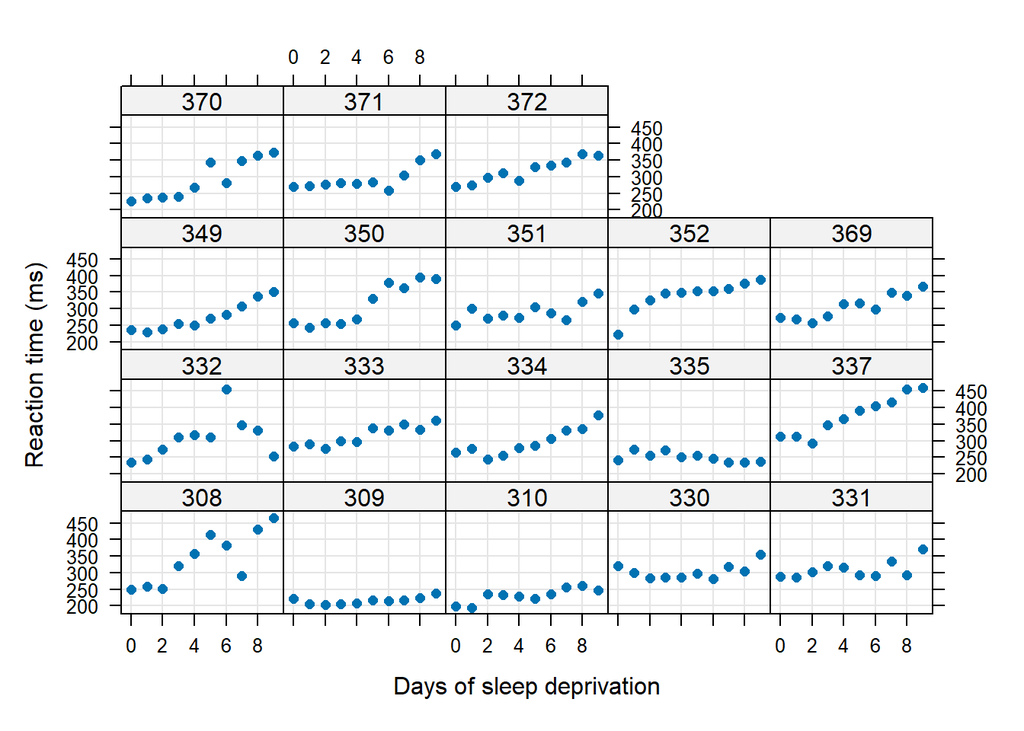

```r
# random intercept for subject
m1 = lmer(Reaction ~ Days + (1 | Subject), data = sleepstudy)

# examine this visually - clearly the model needs random slopes too
xyplot(Reaction ~ Days | Subject,
       data = sleepstudy,
       xlab = "Days of sleep deprivation",
       ylab = "Reaction time (ms)",
       panel = function(x, y, subscripts, ...) {

         lattice::panel.grid(h = -1, v = -1)
         lattice::panel.xyplot(x, y, pch = 16)

         o <- order(x)
         lattice::panel.lines(x[o],
                              sleepstudy$pred[subscripts][o],
                              col = "red",
                              lwd = 2)
       })
```

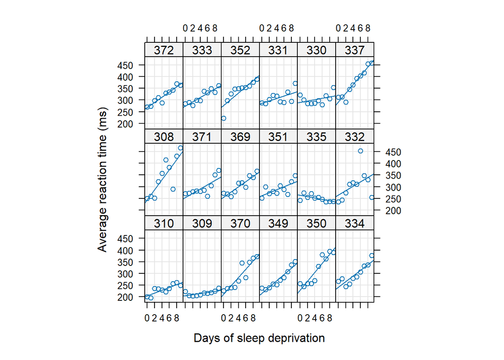

```r
# fit a second model with random slopes
m2 = lmer(Reaction ~ Days + (1 + Days | Subject), data = sleepstudy)

lattice::xyplot(Reaction ~ Days | Subject, sleepstudy, type = c("g","p","r"),
       index = function(x,y) coef(lm(y ~ x))[1],
       xlab = "Days of sleep deprivation",
       ylab = "Average reaction time (ms)", aspect = "xy")
```

```r
# summarise model (lmerTest provides p-values)
summary(m1)
```

```
Linear mixed model fit by REML. t-tests use Satterthwaite's method [
lmerModLmerTest]
Formula: Reaction ~ Days + (1 | Subject)
   Data: sleepstudy

REML criterion at convergence: 1786.5

Scaled residuals:
    Min      1Q  Median      3Q     Max
-3.2257 -0.5529  0.0109  0.5188  4.2506

Random effects:
 Groups   Name        Variance Std.Dev.
 Subject  (Intercept) 1378.2   37.12
 Residual              960.5   30.99
Number of obs: 180, groups:  Subject, 18

Fixed effects:
            Estimate Std. Error       df t value            Pr(>|t|)
(Intercept) 251.4051     9.7467  22.8102   25.79 <0.0000000000000002 ***
Days         10.4673     0.8042 161.0000   13.02 <0.0000000000000002 ***
---
Signif. codes:  0 '***' 0.001 '**' 0.01 '*' 0.05 '.' 0.1 ' ' 1

Correlation of Fixed Effects:
     (Intr)
Days -0.371
```

```r
# for tidy output, use the broom.mixed package
broom.mixed::tidy(m1) %>%
  mutate(across(where(is.numeric),\(x) round(x, 5))) %>%
  # to turn off scientific notation for p-values, add this (it makes them characters):
  mutate(p.value = format(round(p.value,5), scientific = FALSE))
```

| effect | group | term | estimate | std.error | statistic | df | p.value |
| --- | --- | --- | --- | --- | --- | --- | --- |
| fixed | NA | (Intercept) | 251.40510 | 9.74672 | 25.79383 | 22.8102 | 0 |
| fixed | NA | Days | 10.46729 | 0.80422 | 13.01543 | 161.0000 | 0 |
| ran_pars | Subject | sd__(Intercept) | 37.12383 | NA | NA | NA | NA |
| ran_pars | Residual | sd__Observation | 30.99123 | NA | NA | NA | NA |

```r
# another way to access parts of the model object:
coef(summary(m1)) # fixed
```

```
             Estimate Std. Error       df  t value
(Intercept) 251.40510  9.7467163  22.8102 25.79383
Days         10.46729  0.8042214 161.0000 13.01543
                                       Pr(>|t|)
(Intercept) 0.000000000000000002241350959344675
Days        0.000000000000000000000000006412601
```

```r
VarCorr(m1) # random
```

```
 Groups   Name        Std.Dev.
 Subject  (Intercept) 37.124
 Residual             30.991
```

```r
# if convergence issues:
lme4::allFit(m1) # will try with many different optimisers
```

```
bobyqa : [OK]
Nelder_Mead : [OK]
nlminbwrap : [OK]
optimx.L-BFGS-B : [OK]
nloptwrap.NLOPT_LN_NELDERMEAD : [OK]
nloptwrap.NLOPT_LN_BOBYQA : [OK]
```

```
original model:
Reaction ~ Days + (1 | Subject)
data:  sleepstudy
optimizers (6): bobyqa, Nelder_Mead, nlminbwrap, optimx.L-BFGS-B,nloptwrap.NLOPT_LN_NELDERME...
differences in negative log-likelihoods:
max= 0.000000000000114 ; std dev= 0.0000000000000508
```

```r
# To compute LRT for each fixed effect automatically, use
afex::mixed(outcome ~ predictor1*predictor2 + (1|subject), data = data, method="LRT")
afex::mixed(model, dataset, method="LRT")
# the first LRT result will compare the first model with a null model.
# I think this uses type III sums of squares... by default, anova() uses Type I.

# Confidence intervals
confint.merMod(model, method="Wald")
# note that the default method is 'profile', but there's also 'boot'(strapping) which takes ages.
# As stated by Bates et al (2015, p35), all 3 produce v. similar results. Wald is just for fixed effects.
# see this? https://cran.r-project.org/web/packages/merTools/vignettes/Using_predictInterval.html

# Ben Bolker suggests here (https://stat.ethz.ch/pipermail/r-sig-mixed-models/2013q4/021094.html)
# that profile = slow but fairly accurate; Wald = fast but least accurate; boot = slowest but most accurate
```

```r
# LMM diagnostics
# two things: (1) histogram of model residuals
hist(residuals(m1)) # as recommended by Linck & Cunnings 2015
plot(resid(m1))

# (2) check distribution of random effects
# Linck & Cunnings 2015 method
lattice::dotplot(ranef(m1, condVar = TRUE))

# performance package
performance::icc(m1) # intraclass correlation (proportion of variance explained by grouping structure)

# pseudo R2
library(MuMIn)
r.squaredGLMM(model)

library(influence.ME) # iteratively deletes subjects or observations to examine influence
model.infl <- influence(model, "code/upn/child/etc")  # computationally intensive- wait!

without.int <- exclude.influence(model, grouping = "group", level = "level")
summary(model)
summary(without.int)
```

Note that if you’re using `glmer` for logistic mixed effects regression:

```r
gmodel = glmer(outcome ~ predictor1 + predictor2 + (1 | subject),
            na.action = na.omit,
            family = binomial,
            control = glmerControl(optimizer = "bobyqa"),
            data=data)

broom.mixed::tidy(gmodel, exponentiate = T)
```

## 17.7 Quantile regression

```r
library(quantreg)
m1 = rq(dv ~ iv, tau=c(.05, .25, .5, .75, .95), data=df)
```

## 17.8 Moderation and Mediation

### 17.8.1 Moderation

Moderation is about the degree to which a relationship between two variables $X$ and $Y$ differs according to the value or level of a third variable $Z$. It assumes that the effect of $X$ on $Y$ changes by a constant amount (i.e. a linear relationship) as the value of $Z$ changes. Moderation is useful for questions like “does this relationship hold true for everyone in the sample?” or “does this effect depend on $Z$?” It’s mathematically identical to an interaction but with a slightly different interpretation.

```r
# use lm()

mod1 = lm(Y ~ X*Z, data = df)

# check for significant interaction term - this is interpreted as the difference
# in the relationship between X and Z on the outcome, not the direct effect on
# the outcome itself

# visualise interaction term
interactions::interact_plot(mod1, "X", modx = "Z",
                            modx.labels = c("1", "2"),
                            legend.main = "Z",
                            y.label = "Y",
                            x.label = "X")

# the above will also work for continuous predictors, showing -1, 0, and +1 SD
```

### 17.8.2 Mediation

While moderation is more descriptive, mediation takes an explanatory approach by trying to answer the question of whether the effect of a predictor on an outcome is *explained* by an intermediary variable. Mediation can be *total* or *partial* depending to what extent a mediator $M$ explains the relationship between $X$ and $Y$ (see Baron & Kenny, 1986).

```r
# example from a study in which unemployed people received intervention to improve
# their mental health and job prospects
library(mediation)

data = mediation::jobs

b <- lm(job_seek ~ treat, data) # x predicts the mediator
c <- lm(depress2 ~ treat + job_seek, data) # x and m predict the outcome.

mediation <- mediate(b, # Mediator model
                     c, # Outcome model
                     sims = 1000, # Number of bootstrap samples
                     boot = T, # Ask for bootstrapped confidence intervals
                     treat = "treat", # Name of the x variable
                     mediator = "job_seek" # Name of the m variable
                    )

summary(mediation)
```

```
Causal Mediation Analysis

Nonparametric Bootstrap Confidence Intervals with the Percentile Method

                 Estimate 95% CI Lower 95% CI Upper p-value
ACME           -0.0151981   -0.0386201    0.0060844   0.164
ADE            -0.0481481   -0.1381214    0.0385512   0.306
Total Effect   -0.0633463   -0.1565802    0.0262250   0.164
Prop. Mediated  0.2399215   -0.9299699    2.8709350   0.272

Sample Size Used: 899


Simulations: 1000
```

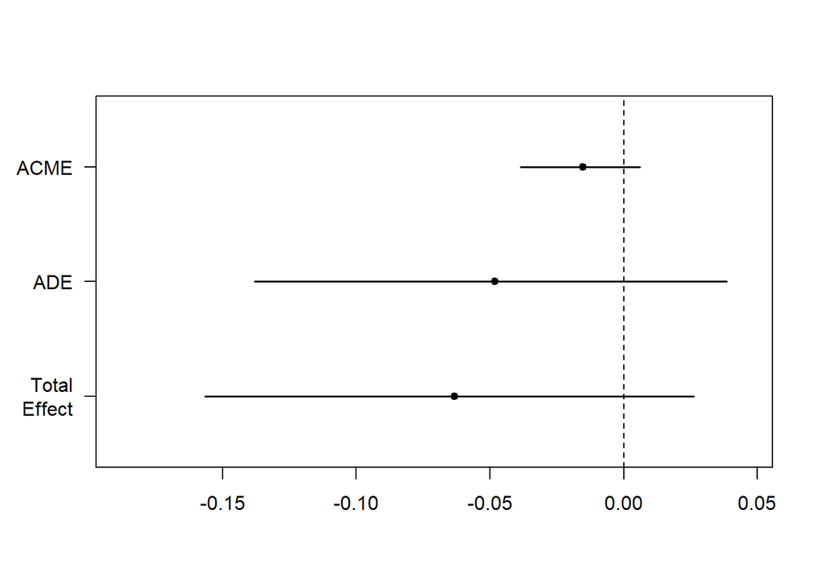

```r
# interpretation:
# - ADE: Average Direct Effect (c')
# - ACME: Average Causal Mediation Effects (indirect effect going through m; a*b)
# - Total Effect: The sum of ACME and ADE (equal to c = c' + a*b)
# - Prop. Mediated: Proportion of the indirect to the total effect (a*b/c)

plot(mediation)
```

## 17.9 Principal components / factor analysis

```r
# Can use PCA as a precursor to factor analysis (covered below), i.e. to choose # of factors
# ---- Note that PCA can be achieved with:
# - pca() / psych::principal()
# - princomp() [base stats], or
# - prcomp() [base stats]
# Using An Introduction to Applied Multivariate Analysis with R (Everitt & Hothorn)
# They use their own 'MVA' package
library(MVA)

head_dat = boot::frets[, c("l1", "l2")]
cov(head_dat)
head_pca = princomp(x = head_dat)
head_pca
summary(head_pca, loadings = T)

xlim = range(head_pca$scores[,1])
plot(head_pca$scores, xlim=xlim, ylim=xlim)
screeplot(head_pca)

# example with Big5 dataset
# From here: https://www.r-bloggers.com/five-ways-to-calculate-internal-consistency/
# BIG5 dataset can be downloaded here: http://personality-testing.info/_rawdata/BIG5.zip
# Data for 19719 respondents on 50 items (10 for each dimension)


# import data and isolate just the raw scores
setwd("~/Google Drive/STATISTICS/R/R script files")
df = read.csv("big5data.csv", header=T, sep="\t")
df = df[, -c(1:7)]

psych::cortest.bartlett(df) # should be statistically significant
# for oblique (oblimin) rotation, load the GPArotation package
library(GPArotation)
pc1 = psych::principal(df, nfactors = 5, rotate = "oblimin", scores = T)
pc1
# screeplot
plot(pc1$values, type="b")
psych::alpha(df)

# princomp
pca = princomp(df)
summary(pca)
# look for proportion of variance explained
plot(pca) # choose 3

# Factor analysis ----
fit <- factanal(df, 3, rotation="varimax") # varimax is default
print(fit, digits=2, cutoff=.3, sort=TRUE)
# look at bottom for test of hyp that chosen number of factors is sufficient.
# p < .05 means it's sufficient.

# extract the factor scores: run it again but specify scores="regression"
scores = factanal(df, 3, rotation="varimax", scores="regression")
# returns a list, so access scores with:
scores$scores

psych::fa()
#for psych, see: https://m-clark.github.io/posts/2020-04-10-psych-explained/
```

Another more recent example of FA

```r
# isolate data
fa_data = res %>%
  select(yarc.ewr.t1,
         phab.alliteration,
         phab.blending,
         yarc.lsk,
         da.train.total,
         da.post.total,
         ran.time.total,
         cpm.raw,
         bpvs.raw)
# check for missingness (fine)
fa_data %>% summarise(across(everything(), ~sum(is.na(.) / n())))

# derive correlation matrix
cor_mat <- cor(fa_data)

# assumptions
psych::KMO(cor_mat)
# overall MSA = 0.88

# Bartlett test - looking for significant test result (OK)
psych::cortest.bartlett(R = cor_mat, n = nrow(res))

# factor extraction (suggests 2 (with values >1)
eigen(cor_mat)$values

# factor analysis
# using oblimin for rotation to allow factors to correlate
da_factor <- psych::fa(r = cor_mat, nfactors = 2, fm = "minres", rotate = "oblimin")
da_factor
# print(da_factor, cut = 0.3)

psych::fa.diagram(da_factor$loadings, digits=2)

# export
write.csv(loadings(da_factor), "./Outputs/da_efa_loadings.csv")
write.csv(data.frame((da_factor$communalities)), "./Outputs/da_efa_h2.csv")
```

## 17.10 Statistical power

```r
# Using pwr package. Note: you must leave one of the parameters blank to estimate it, e.g.
# if you want minimum power detectable at b=0.8, leave d as d = NULL
# Permissible values for type = two.sample, one.sample, paired
# Default value of alternative is "two.sided"
pwr::pwr.t.test(d = 0.25,
                n = 30,
                power = 0.80,
                sig.level = 0.05,
                type = "two.sample",
                alternative="two.sided")
```

```r
# For samples of different sizes:
pwr::pwr.t2n.test(n1 = 300, n2 = 350, d= NULL, sig.level = 0.05, power = 0.80)
```

```
     t test power calculation

             n1 = 300
             n2 = 350
              d = 0.2207291
      sig.level = 0.05
          power = 0.8
    alternative = two.sided
```

E.g. this says that with sample sizes of 300 and 350, the minimum detectable effect size for 80% power is 0.22. If we want to find out the minimum sample sizes needed for an effect size of 0.15 (698 for each group = 1,396 total).

```r
# For samples of different sizes:
pwr::pwr.t.test(n = NULL, d = 0.15, sig.level = 0.05, power = 0.80, type = "two.sample")
```

```
     Two-sample t test power calculation

              n = 698.6382
              d = 0.15
      sig.level = 0.05
          power = 0.8
    alternative = two.sided

NOTE: n is number in *each* group
```

Other power analysis packages include `pwrss` (a range of options, inc plots), `BUCSS` (using previously published test statistics for sample size planning), `MBESS` (using confidence limits), `PowerUpR` (for multilevel designs), `webpower` (a range of options), `simglm` (generalised linear mixed models), `Superpower` (simulation for ANOVA designs only).

```r
# some examples from pwrss - determining minimum sample size
# independent samples
pwrss::pwrss.t.2means(mu1 = 30, mu2 = 28, sd1 = 12, sd2 = 8, kappa = 1,
               power = .80, alpha = 0.05,
               alternative = "not equal")
```

```
+--------------------------------------------------+
|             SAMPLE SIZE CALCULATION              |
+--------------------------------------------------+

Welch's T-Test (Independent Samples)

---------------------------------------------------
Hypotheses
---------------------------------------------------
  H0 (Null Claim) : d - null.d = 0
  H1 (Alt. Claim) : d - null.d != 0

---------------------------------------------------
Results
---------------------------------------------------
  Sample Size            = 410 and 410  <<
  Type 1 Error (alpha)   = 0.050
  Type 2 Error (beta)    = 0.199
  Statistical Power      = 0.801
```

```r
# paired samples
pwrss::pwrss.t.2means(mu1 = 30, mu2 = 28, sd1 = 12, sd2 = 8,
               paired = TRUE, paired.r = 0.50,
               power = .80, alpha = 0.05,
               alternative = "not equal")
```

```
+--------------------------------------------------+
|             SAMPLE SIZE CALCULATION              |
+--------------------------------------------------+

Student's T-Test (Paired Samples)

---------------------------------------------------
Hypotheses
---------------------------------------------------
  H0 (Null Claim) : d - null.d = 0
  H1 (Alt. Claim) : d - null.d != 0

---------------------------------------------------
Results
---------------------------------------------------
  Sample Size            = 222  <<
  Type 1 Error (alpha)   = 0.050
  Type 2 Error (beta)    = 0.199
  Statistical Power      = 0.801
```

## 17.11 Propensity Score Matching (PSM)

PSM is a quasi-experimental technique used when there is non-random assignment to some condition. The aim is to create a subset of units in a control group which are matched on relevant covariates, i.e. to compare ‘like for like’.

The example below is from the `MatchIt` package. The aim is to estimate the causal effect of `treat` on earnings (`re78`).

```r
library(MatchIt)

data("lalonde")
head(lalonde)
```

|  | treat | age | educ | race | married | nodegree | re74 | re75 | re78 |
| --- | --- | --- | --- | --- | --- | --- | --- | --- | --- |
| NSW1 | 1 | 37 | 11 | black | 1 | 1 | 0 | 0 | 9930.0460 |
| NSW2 | 1 | 22 | 9 | hispan | 0 | 1 | 0 | 0 | 3595.8940 |
| NSW3 | 1 | 30 | 12 | black | 0 | 0 | 0 | 0 | 24909.4500 |
| NSW4 | 1 | 27 | 11 | black | 0 | 1 | 0 | 0 | 7506.1460 |
| NSW5 | 1 | 33 | 8 | black | 0 | 1 | 0 | 0 | 289.7899 |
| NSW6 | 1 | 22 | 9 | black | 0 | 1 | 0 | 0 | 4056.4940 |

The first step is to check initial covariate imbalance. The code below uses logistic regression to derive a **propensity score**, but does not attempt any matching. In the results you need to look at the Std. Mean Diff (close to 0 indicates balance) and the Var.Ratio (close to 1 indicates balance). Here we have severe imbalances, suggesting that currently `treat=0` is not a good comparison group.

```r
m.out0 = matchit(treat ~ age + educ + race + married +
                    nodegree + re74 + re75,
                  data = lalonde,
                  method = NULL,
                  distance = "glm")

summary(m.out0)
```

```
Call:
matchit(formula = treat ~ age + educ + race + married + nodegree +
    re74 + re75, data = lalonde, method = NULL, distance = "glm")

Summary of Balance for All Data:
           Means Treated Means Control Std. Mean Diff. Var. Ratio eCDF Mean
distance          0.5774        0.1822          1.7941     0.9211    0.3774
age              25.8162       28.0303         -0.3094     0.4400    0.0813
educ             10.3459       10.2354          0.0550     0.4959    0.0347
raceblack         0.8432        0.2028          1.7615          .    0.6404
racehispan        0.0595        0.1422         -0.3498          .    0.0827
racewhite         0.0973        0.6550         -1.8819          .    0.5577
married           0.1892        0.5128         -0.8263          .    0.3236
nodegree          0.7081        0.5967          0.2450          .    0.1114
re74           2095.5737     5619.2365         -0.7211     0.5181    0.2248
re75           1532.0553     2466.4844         -0.2903     0.9563    0.1342
           eCDF Max
distance     0.6444
age          0.1577
educ         0.1114
raceblack    0.6404
racehispan   0.0827
racewhite    0.5577
married      0.3236
nodegree     0.1114
re74         0.4470
re75         0.2876

Sample Sizes:
          Control Treated
All           429     185
Matched       429     185
Unmatched       0       0
Discarded       0       0
```

The next step is to perform matching. There are different options available (using the `method` argument), but here we just use nearest neighbour. When looking at the summary, use `un=F` to suppress the first table from above before matching is carried out. Unfortunately there are still some imbalances here, and quite a few units (244) remain unmatched.

```r
m.out1 = matchit(treat ~ age + educ + race + married +
                    nodegree + re74 + re75,
                  data = lalonde,
                  method = "nearest",
                  distance = "glm")

summary(m.out1, un = F)
```

```
Call:
matchit(formula = treat ~ age + educ + race + married + nodegree +
    re74 + re75, data = lalonde, method = "nearest", distance = "glm")

Summary of Balance for Matched Data:
           Means Treated Means Control Std. Mean Diff. Var. Ratio eCDF Mean
distance          0.5774        0.3629          0.9739     0.7566    0.1321
age              25.8162       25.3027          0.0718     0.4568    0.0847
educ             10.3459       10.6054         -0.1290     0.5721    0.0239
raceblack         0.8432        0.4703          1.0259          .    0.3730
racehispan        0.0595        0.2162         -0.6629          .    0.1568
racewhite         0.0973        0.3135         -0.7296          .    0.2162
married           0.1892        0.2108         -0.0552          .    0.0216
nodegree          0.7081        0.6378          0.1546          .    0.0703
re74           2095.5737     2342.1076         -0.0505     1.3289    0.0469
re75           1532.0553     1614.7451         -0.0257     1.4956    0.0452
           eCDF Max Std. Pair Dist.
distance     0.4216          0.9740
age          0.2541          1.3938
educ         0.0757          1.2474
raceblack    0.3730          1.0259
racehispan   0.1568          1.0743
racewhite    0.2162          0.8390
married      0.0216          0.8281
nodegree     0.0703          1.0106
re74         0.2757          0.7965
re75         0.2054          0.7381

Sample Sizes:
          Control Treated
All           429     185
Matched       185     185
Unmatched     244       0
Discarded       0       0
```

We can visualise the matching results with some plots.

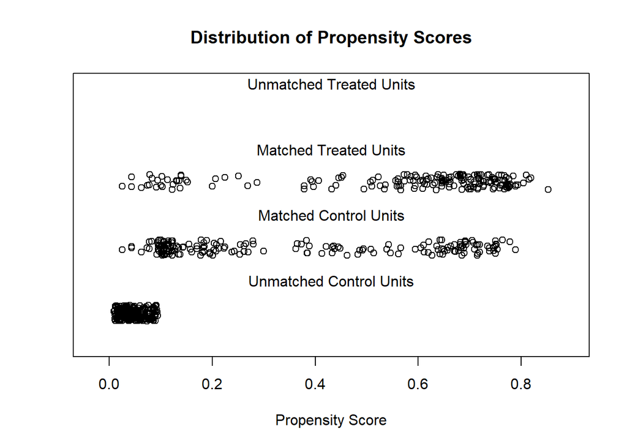

```r
plot(m.out1, type = "jitter", interactive = FALSE)
```

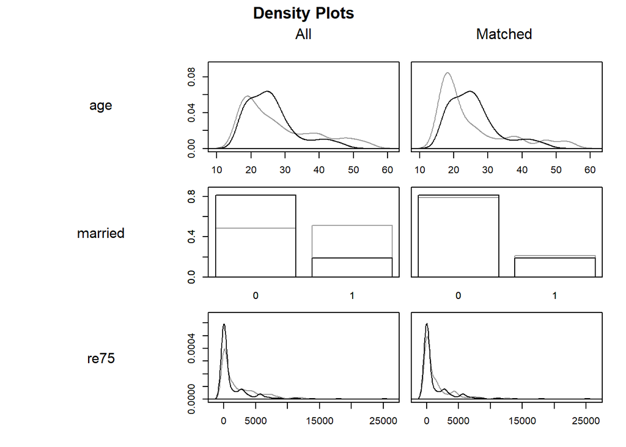

```r
plot(m.out1, type = "density", interactive = FALSE,
     which.xs = ~age + married + re75)
```

```r
m.out2 = matchit(treat ~ age + educ + race + married +
                    nodegree + re74 + re75,
                  data = lalonde,
                  method = "full",
                  distance = "glm",
                  link = "probit")

summary(m.out2, un = F)
```

```
Call:
matchit(formula = treat ~ age + educ + race + married + nodegree +
    re74 + re75, data = lalonde, method = "full", distance = "glm",
    link = "probit")

Summary of Balance for Matched Data:
           Means Treated Means Control Std. Mean Diff. Var. Ratio eCDF Mean
distance          0.5773        0.5764          0.0045     0.9949    0.0043
age              25.8162       25.5347          0.0393     0.4790    0.0787
educ             10.3459       10.5381         -0.0956     0.6192    0.0253
raceblack         0.8432        0.8389          0.0119          .    0.0043
racehispan        0.0595        0.0492          0.0435          .    0.0103
racewhite         0.0973        0.1119         -0.0493          .    0.0146
married           0.1892        0.1633          0.0660          .    0.0259
nodegree          0.7081        0.6577          0.1110          .    0.0504
re74           2095.5737     2100.2150         -0.0009     1.3467    0.0314
re75           1532.0553     1561.4420         -0.0091     1.5906    0.0536
           eCDF Max Std. Pair Dist.
distance     0.0486          0.0198
age          0.2742          1.2843
educ         0.0730          1.2179
raceblack    0.0043          0.0162
racehispan   0.0103          0.4412
racewhite    0.0146          0.3454
married      0.0259          0.4473
nodegree     0.0504          0.9872
re74         0.1881          0.8387
re75         0.1984          0.8240

Sample Sizes:
              Control Treated
All            429.       185
Matched (ESS)   50.76     185
Matched        429.       185
Unmatched        0.         0
Discarded        0.         0
```

This is a much better result. Visualise with a Love plot:

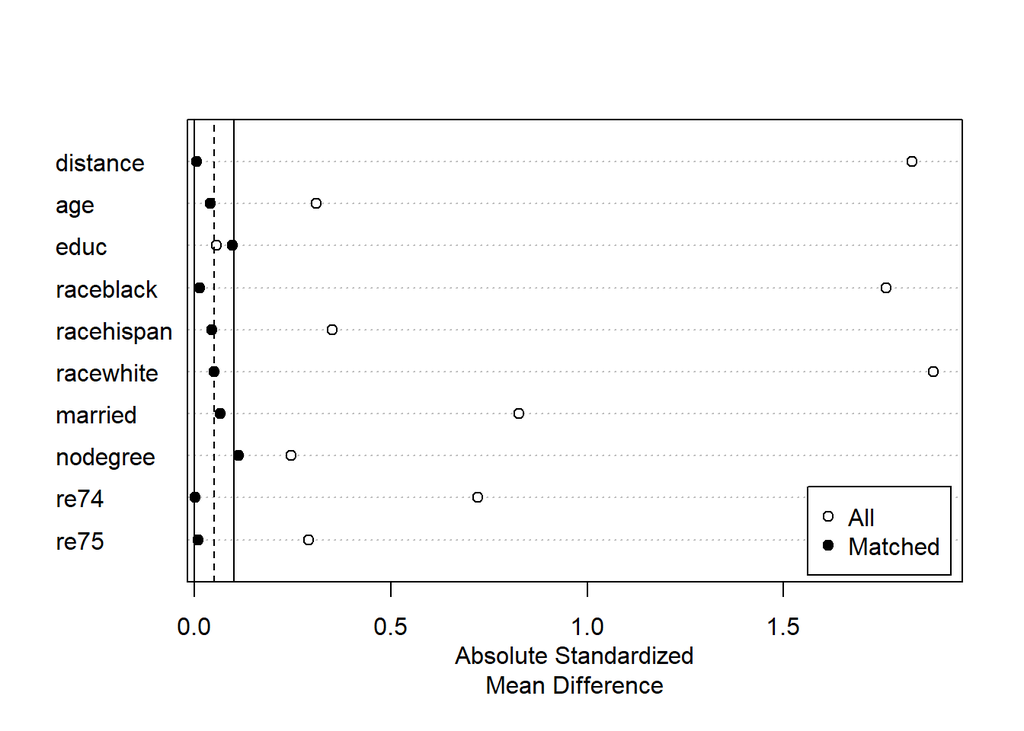

```r
plot(summary(m.out2))
```

To extract the raw matched data:

```r
m.data = match_data(m.out2)

head(m.data)
```

|  | treat | age | educ | race | married | nodegree | re74 | re75 | re78 | distance | weights | subclass |
| --- | --- | --- | --- | --- | --- | --- | --- | --- | --- | --- | --- | --- |
| NSW1 | 1 | 37 | 11 | black | 1 | 1 | 0 | 0 | 9930.0460 | 0.6356769 | 1 | 1 |
| NSW2 | 1 | 22 | 9 | hispan | 0 | 1 | 0 | 0 | 3595.8940 | 0.2298151 | 1 | 55 |
| NSW3 | 1 | 30 | 12 | black | 0 | 0 | 0 | 0 | 24909.4500 | 0.6813558 | 1 | 63 |
| NSW4 | 1 | 27 | 11 | black | 0 | 1 | 0 | 0 | 7506.1460 | 0.7690590 | 1 | 70 |
| NSW5 | 1 | 33 | 8 | black | 0 | 1 | 0 | 0 | 289.7899 | 0.6954138 | 1 | 79 |
| NSW6 | 1 | 22 | 9 | black | 0 | 1 | 0 | 0 | 4056.4940 | 0.6943658 | 1 | 86 |

We can now proceed to analyse the data using standard regression or other techniques. Make sure to use the `weights` in the output above when doing so.

```r
fit = lm(re78 ~ treat * (age + educ + race + married +
                            nodegree + re74 + re75),
          data = m.data,
          weights = weights)

avg_comparisons(fit,
                variables = "treat",
                vcov = ~subclass,
                newdata = subset(treat == 1))
```

```
 Estimate Std. Error    z Pr(>|z|)   S 2.5 % 97.5 %
     1977        704 2.81  0.00501 7.6   596   3357

Term: treat
Type: response
Comparison: 1 - 0
```

## 17.12 Missing data imputation

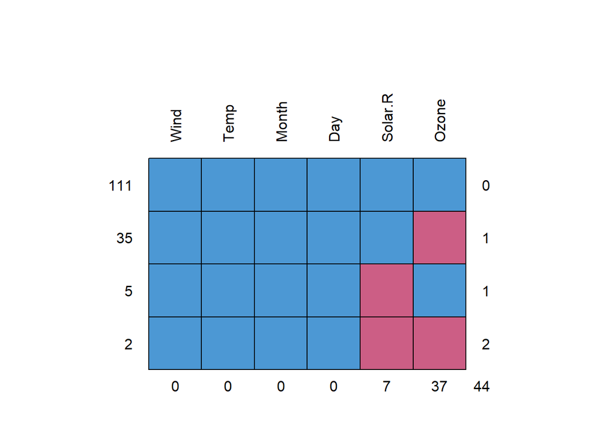

```
    Wind Temp Month Day Solar.R Ozone
111    1    1     1   1       1     1  0
35     1    1     1   1       1     0  1
5      1    1     1   1       0     1  1
2      1    1     1   1       0     0  2
       0    0     0   0       7    37 44
```

```r
library(mice)

data(airquality)
mice::md.pattern(airquality, rotate.names = T)
```

```r
# impute data -
# creates a 'mids' object with however many imputed datasets you specify in m:
imputed_data = mice(
  airquality,
  m = 5,             # Number of imputed datasets
  maxit = 10,        # Number of iterations
  method = 'pmm',    # Imputation method
  seed = 500         # Random seed for reproducibility
)
# diagnostics
summary(imputed_data)
```

```
Class: mids
Number of multiple imputations:  5
Imputation methods:
  Ozone Solar.R    Wind    Temp   Month     Day
  "pmm"   "pmm"      ""      ""      ""      ""
PredictorMatrix:
        Ozone Solar.R Wind Temp Month Day
Ozone       0       1    1    1     1   1
Solar.R     1       0    1    1     1   1
Wind        1       1    0    1     1   1
Temp        1       1    1    0     1   1
Month       1       1    1    1     0   1
Day         1       1    1    1     1   0
```

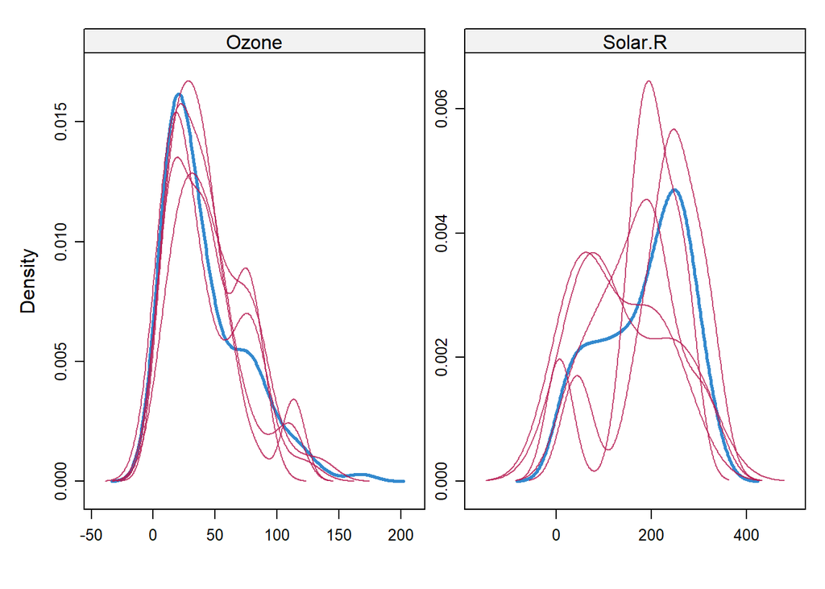

```r
# plots - observed in blue, imputed in red
densityplot(imputed_data)
```

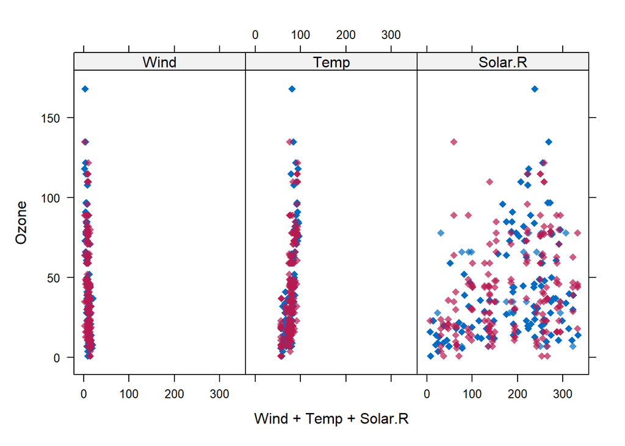

```r
xyplot(imputed_data, Ozone ~ Wind+Temp+Solar.R,pch=18,cex=1)
```

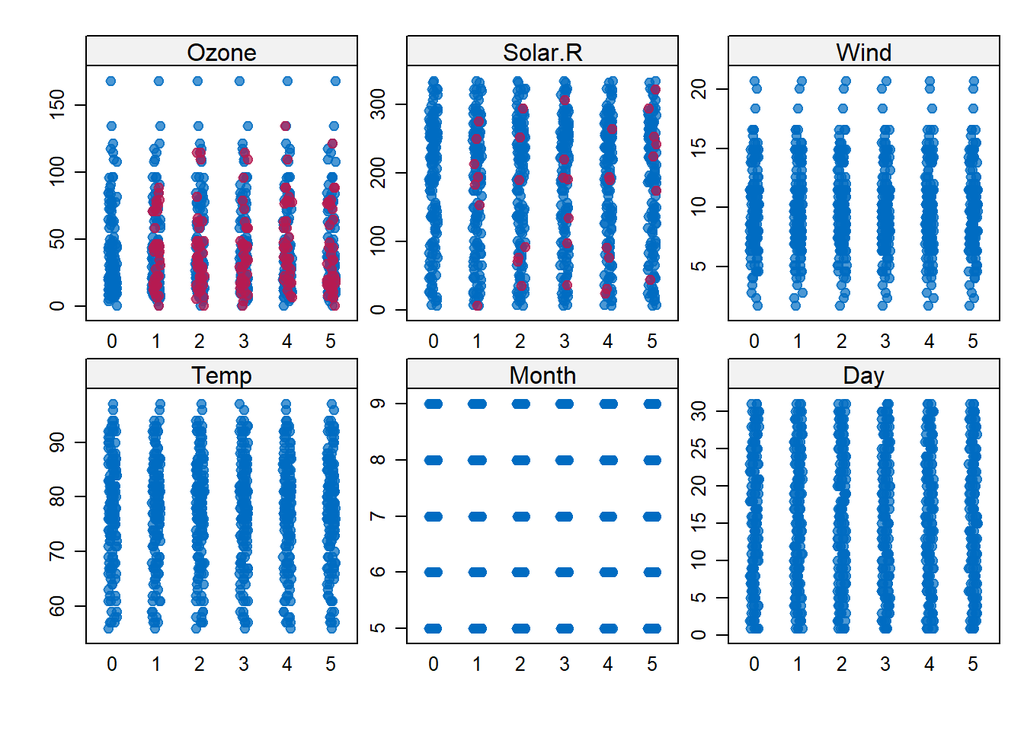

```r
stripplot(imputed_data, pch = 20, cex = 1.2)
```

```r
# conduct analysis and pool estimates:
fit = with(data = imputed_data,
       exp = lm(Ozone ~ Solar.R + Month))

summary(pool(fit))
```

| term | estimate | std.error | statistic | df | p.value |
| --- | --- | --- | --- | --- | --- |
| (Intercept) | -7.0124702 | 17.7198045 | -0.395742 | 17.64829 | 0.6970386 |
| Solar.R | 0.1190208 | 0.0378805 | 3.142004 | 13.35590 | 0.0075698 |
| Month | 3.8597687 | 1.8929143 | 2.039061 | 60.71882 | 0.0458036 |

```r
# get a complete dataset using values from either of the imputed datasets
complete_data = mice::complete(imputed_data, action = 1)
# note: use action= "long" to add estimates from all imputed datasets
# (results in longer data and doesn't actually combine estimates)
```